# Guide pratique R

Ce **“guide pratique R”** est un manuel expliquant l’utilisation du langage de programmation **R** pour la **manipulation des données**.

# 1 Environnement de travail

On trouvera ici l’environnement permettant de faire tourner des scripts R.

## 1.1 Cerise

L’accès à R peut se réaliser via Cerise, la plateforme de stockage et de traitement des données.  
Cerise permet l’accès aux ressources déposées sur le serveur, la sauvegarde, le partage de code et le travail simultané. C’est l’usage recommandé.

https://ssm-agriculture.github.io/formation-cerise/

### 1.1.1 Version de R

La version de R par défaut est la 4.4.1. La version précédente (4.2.3) est toujours disponible. Il est recommandé d’utiliser la nouvelle version de R.

Pour changer de version, aller en haut à droite et cocher la version souhaitée.

[figure not shown]

### 1.1.2 Sessions R

Il est possible d’avoir plusieurs sessions R ouvertes. On peut choisir la version de R utilisée au lancement de la session, en allant en haut à droite.

puis choisir de l’associer à un projet ou à un dossier :

[figure not shown]

`~` (obtenu par AltGr+2 puis espace) permet d’indiquer le répertoire racine dans Cerise, relatif au répertoire personnel de l’utilisateur (correspond à ~/CERISE/00-Espace-Personnel/prenom.nom/).

On peut préciser le chemin du dossier en cliquant sur ‘Parcourir’, puis cliquer sur ‘Choisissez’

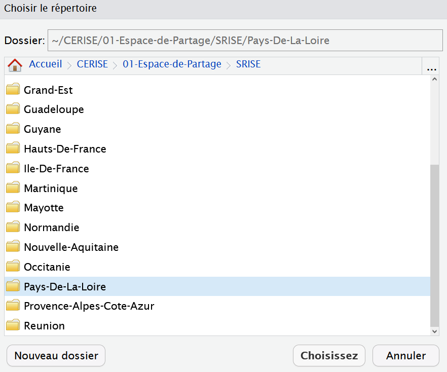

Puis choisir la version de R à travers la fenêtre :

[figure not shown]

et enfin cliquer sur `Start`.

https://orion.agriculture/confluence/display/CER/Bon+usage+des+sessions+RStudio

### 1.1.3 Comment récupérer un chemin pour l’utiliser dans un programme R

Dans la fenêtre de parcours des dossiers (fenêtre en bas à droite dans RStudio Server), choisir `Plus`  
puis `Copier le chemin du dossier dans le presse-papiers`.

On peut aussi utiliser `Plus` puis `Définir comme répertoire de travail`.

```r
# setwd("~/CERISE/01-Espace-de-Partage/SRISE/Pays-De-La-Loire/Partage_R")
```

Le chemin peut alors être copié depuis la console (fenêtre en bas à gauche).

### 1.1.4 Comment se déplacer rapidement vers un autre répertoire

Pour l’utilisateur muni de ce chemin, il convient de cliquer sur les trois petits points (fenêtre en bas à droite dans RStudio Server)

Dans la fenêtre qui apparaît, on colle le chemin vers le dossier d’intérêt, par exemple  
~/CERISE/01-Espace-de-Partage/SRISE/Pays-De-La-Loire/Partage_R

~ (obtenu par AltGr+2 puis espace) permet d’indiquer le répertoire racine dans Cerise, relatif au répertoire personnel de l’utilisateur (correspond à ~/CERISE/00-Espace-Personnel/prenom.nom/).

On clique enfin sur OK.

Pour vérifier le répertoire de travail, on peut exécuter la fonction `getwd()`.  
Un **répertoire de travail** (ou **working directory** en anglais) est un répertoire qui sera pris comme référence par RStudio.

Sous RStudio, le répertoire de travail est également affiché dans le quadrant inférieur gauche, en gris, en dessous de l’onglet ‘Console’.

```r
> setwd("~/CERISE")
> getwd()
# donne [1] "/var/data/nfs/CERISE"
```

### 1.1.5 Comment transférer des fichiers entre son poste de travail et Cerise

#### 1.1.5.1 Comment télécharger un fichier depuis Cerise

Une fois sur l’interface Rstudio de Cerise, il faut naviguer vers le dossier contenant le fichier à traiter.

Pour cela, il faut utiliser le navigateur de fichier, dans la partie bas droite de l’écran.

Il faut naviguer dans les dossiers jusqu’au fichier et ensuite sélectionner celui-ci pour pouvoir le télécharger, puis aller dans Plus > Exporter

#### 1.1.5.2 Comment téléverser un fichier vers Cerise

Sur votre PC en local, faire un zip qui contient les fichiers à uploader (même si le fichier est unique). Cela permet d’affecter les “bons droits” sur ces fichiers (notamment qu’ils soient modifiables par d’autres agents). Son contenu sera ensuite automatiquement dézippé sous Cerise.

Dans le cas d’un fichier ayant vocation à être déposé sur Cerise, il faut utiliser le navigateur de fichier de RStudio, dans la partie bas droite de l’écran.

Une fois placé dans le dossier de dépôt du fichier, choisir `Télécharger` (Télécharger des fichiers vers le serveur)

Puis récupérer le fichier sur son poste de travail en utilisant Parcourir, puis OK.

#### 1.1.5.3 Détails avec des captures d’écran

https://orion.agriculture/confluence/pages/viewpage.action?pageId=38601956

### 1.1.6 Foire aux questions

https://orion.agriculture/confluence/display/CER/4+-+FAQ

## 1.2 R Studio

RStudio est un *environnement de développement intégré* (EDI), qui propose des outils facilitant l’écriture de scripts et l’usage de R au quotidien. Un autre EDI apprécié est Visual Studio Code, qui peut être utilisé en local sur son poste de travail.

L’interface RStudio est composée de différents panneaux, incluant :  
- une fenêtre `Source` (Editeur), permettant la vue des scripts et des données (en haut à gauche),  
- une `console` contenant le journal d’exécution (la log) (en bas à gauche),  
- `l’espace de travail` (Environnement) et l’historique des commandes (en haut à droite),  
- une fenêtre `Services`, contenant un navigateur offrant une vue des répertoires et fichiers, un onglet de visualisation des graphiques, un onglet de gestion des packages et de l’aide (en bas à droite).

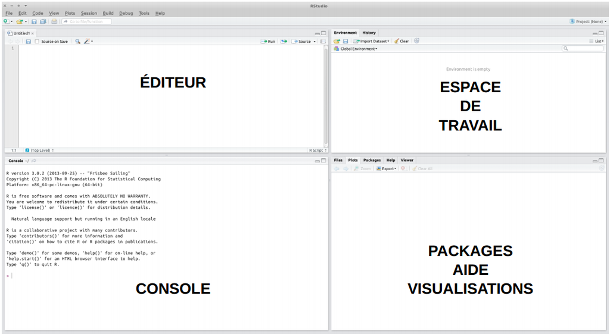

### 1.2.1 Faire tourner des programmes via l’environnement de développement intégré `R Studio`

Exécution en interactif dans la session courante de l’utilisateur.

A partir du programme ouvert dans l’IDE Rstudio, l’utilisateur exécute le programme manuellement :

```
Menu Code/ Run
Bouton Run
Combinaison de touche Ctrl-A suivie de Ctrl-Entrée
```

Une fois l’exécution commencée, la console présente à l’utilisateur les informations du déroulé du programme.

Dans ce mode, l’utilisateur doit attendre que le programme se termine pour à nouveau relancer un programme s’il souhaite rester dans la même session. Les objets de l’environnement d’exécution évoluent également tout au long du déroulé du programme exécuté, et les ressources de la session sont mobilisées par l’exécution courante.

### 1.2.2 Raccourcis RStudio

Pour modifier le raccourci pour le pipe natif : menu Outils (Tools) -> Options Globales (Global Options), cliquer sur l’icône `Code` à gauche et cocher la case à cocher pour Utiliser l’opérateur pipe natif |>.

Pour gagner du temps, il est important d’utiliser les raccourcis pour les commandes répétitives.

```
# (`AltGr` + `3`) pour commenter son code

`Ctrl` + `Shift` + `M` : insère le pipe `|>`
 Plusieurs verbes (ou fonctions) peuvent facilement être combinés
 en utilisant l'opérateur `|>` (pipe) qui permet d'enchaîner les instructions.
Penser à aérer son code, notamment en revenant à la ligne, après un |>
 x |>
  f |>
    g |>
      h
est équivalent à h(g(f(x)))

`Alt` + `-` : insère la flèche d'assignation <-
`Alt`+ `6` (Windows) : insére l'opérateur assignation `<-`
`Ctrl`+`Entrée` : exécute le code sélectionné
(ou la commande ou se trouve le curseur si rien n'a été sélectionné)
Ctrl + A : tout sélectionner
Ctrl + C/X/V : copier/couper/coller classique
`Ctrl` + `Z` : annule la dernière modification
`Ctrl` + `F` : ouvre le formulaire de chercher/remplacer dans le script
`Ctrl` + `Shift` + `F` : recherche une expression dans plusieurs fichiers
`Ctrl` + `I` : indente automatiquement le code sélectionné
(ou la commande ou se trouve le curseur si rien n'a été sélectionné)
Ctrl + Shift + C : bascule en commentaire le code sélectionné
(ou la ligne où se trouve le curseur si rien n'a été sélectionné)
`Ctrl` + `S` : enregistre le fichier courant (équivalent de la disquette)
`Tab` (touche de tabulation) ou Ctrl + Espace : ouvre les propositions d'autocomplétion
(pour les noms de fonctions ou d'objets, et pour les chemins à l'intérieur de guillemets)

F1 : sur une fonction R, affiche l'aide de la fonction
(si le package est chargé).  On peut aussi utiliser ?nom_fonction (ou ??nom_fonction).
La documentation de la fonction apparaîtra dans le panneau en bas à droite de RStudio.
F2 : sur une fonction, affiche le code de la fonction
(sur une fonction personnalisée uniquement
si le script contenant la définition de la fonction est ouvert)

Ctrl + ↑ : dans la console, affiche l'historique des commandes exécutées (et permet de les relancer)
Ctrl + L : vide la console

`Ctrl` + `+=` : Zoom positif (Menu View, Zoom In)
`Ctrl` + `0à` : Annulation du zoom (Menu View, Actual Size)
`Zoom négatif` (Menu View, Zoom Out)

Ctrl + Alt + Shift + W : ferme tous les fichiers sauf le fichier courant

---- : permet de créer une section dans un script (pour structurer le code)
Ctrl + Shift + R : ajout de section dans un script (ou via le menu Code > Insert Section)
Ctrl + Alt + I : insère un chunk R (dans une syntaxe markdown uniquement)
```

https://orion.agriculture/confluence/display/CER/Ergonomie+et+raccourcis+dans+RStudio

https://book.utilitr.org/03_Fiches_thematiques/Fiche_rprojects.html#utiliser-les-fonctionnalit%C3%A9s-de-rstudio

### 1.2.3 Comment créer un nouveau répertoire

Dans le cadran en bas à droite, aller dans le menu `Files`, choisir `New Folder`.

```r
dir.create("nouveau_dossier")
```

### 1.2.4 Comment créer un nouveau script R

Dans le menu `File`, choisir `New File`, `R script`

Un script correspond à un programme en R incluant des lignes de code.

Le fait de structurer ses analyses sous forme de scripts (suite d’instructions effectuant les différentes opérations d’une analyse) présente de nombreux avantages :

- le script conserve l’ensemble des étapes d’une analyse, de l’importation des données à leur analyse en passant par les manipulations et les recodages.
- on peut à tout moment revenir en arrière et corriger ou modifier ce qui a été fait.
- il est très rapide de réexécuter une suite d’opérations complexes.
- on peut très facilement mettre à jour les résultats en cas de modification des données sources.
- le script garantit, sous certaines conditions, la reproductibilité des résultats obtenus.

```r
# création d'un .R :
file.create("nouveau_pgm.R")
```

On peut enregistrer le script à tout moment dans un fichier avec l’extension `.R`, en cliquant sur l’icône de disquette ou en choissant *File* puis *Save*.

Pour exécuter une commande saisie dans un script, il suffit de positionner le curseur sur la ligne de la commande en question, et de cliquer sur le bouton *Run* (ou *Exécuter*) dans la barre d’outils juste au-dessus de la zone d’édition du script. On peut aussi utiliser le raccourci clavier `Ctrl + Entrée`.

Les *commentaires* sont un élément très important d’un script. Il s’agit de texte libre, ignoré par R, et qui permet de décrire les étapes du script, sa logique, les raisons pour lesquelles on a procédé de telle ou telle manière… Il est primordial de documenter ses scripts à l’aide de commentaires, car il est très facile de ne plus se retrouver dans un programme qu’on a produit soi-même, même après une courte interruption.

Pour ajouter un commentaire, il suffit de le faire précéder d’un ou plusieurs symboles `#`. En effet, dès que R rencontre ce caractère, il ignore tout ce qui se trouve derrière, jusqu’à la fin de la ligne.

### 1.2.5 Comment copier un fichier ou un dossier via R

```r
library(fs)

# pour les fichiers
# fs::file_copy("chemin/vers/le/fichier_a_copier.csv", "chemin/vers/le/dossier_cible/")

# pour les dossiers
# fs::dir_copy

## Exemple de copie d'un dossier ou d'un fichier via R

# pour les dossiers
chemin_path <- "~/CERISE/01-Espace-de-Partage/SRISE/Pays-De-La-Loire/Partage_R/"
entree_path1 <- "Christophe/entree"
entree_path2 <- "Christophe/pgm"
entree_path3 <- "Christophe/sortie"
sortie_path1 <- "temporaire"

fs::dir_copy(path = path(chemin_path, entree_path1),
  new_path = path(chemin_path, sortie_path1))
dir_copy(path = path(chemin_path, entree_path2),
  new_path = path(chemin_path, sortie_path1),
  overwrite = TRUE)
dir_copy(path = path(chemin_path, entree_path3),
  new_path = path(chemin_path, sortie_path1))

# pour les fichiers
# fs::file_copy("chemin/vers/le/fichier_a_copier.csv", "chemin/vers/le/dossier_cible/")
chemin_fichier_entree <- "~/CERISE/01-Espace-de-Partage/SRISE/Pays-De-La-Loire/Partage_R/Christophe/pgm/"
entree_fichier <- "manipulations.R"
chemin_fichier_sortie <- "~/CERISE/01-Espace-de-Partage/SRISE/Pays-De-La-Loire/Partage_R/temporaire/pgm/"

fs::file_copy(path = path(chemin_fichier_entree, entree_fichier),
  new_path = path(chemin_fichier_sortie),
  overwrite = TRUE)

# renommer un fichier grâce à la fonction file.rename() :
# file.rename(from = "nouveau_fichier.csv", to = "mon_fichier.csv")
# file.rename(from = "nouveau_pgm.R", to = "nouveau_pgm_2.R")
```

### 1.2.6 La Console

La zone en bas à gauche se nomme la *Console*.

La *Console* doit normalement finir par une ligne commençant par le caractère `>` et sur laquelle devrait se trouver le curseur. Cette ligne est appelée l’*invite de commande* (ou *prompt* en anglais). Elle signifie que R est disponible et en attente de la prochaine instruction.

Quand on est dans la console, on peut utiliser les flèches vers le haut `↑` et vers le bas `↓` du clavier pour naviguer dans l’historique des commandes tapées précédemment. On peut à tout moment modifier la commande affichée, et l’exécuter en appuyant sur `Entrée`.

Enfin, il peut arriver qu’on saisisse une commande de manière incomplète : oubli d’une parenthèse, faute de frappe, etc. Dans ce cas, R remplace l’invite de commande habituel par un signe `+`.

```
4 *
+
```

Cela signifie qu’il “attend la suite”. On peut alors soit compléter la commande sur cette nouvelle ligne et appuyer sur `Entrée`, soit, si on est perdu, tout annuler et revenir à l’invite de commandes normal en appuyant sur `Esc` ou `Échap`.

Pour effacer le contenu de la console : cliquer sur l’icone “balai” à droite, ou menu Edit > Clear console ou Ctrl + L

### 1.2.7 L’espace de travail - le `workspace`

L’espace de travail (ou `workspace`) est l’environnement de la session R. Il comprend tous les objets créés durant une session de travail sous R. Par exemple, lorsqu’on importe des données, elles deviennent un objet de type data.frame et sont intégrées à l’environnement global. De même lorsqu’on crée un objet, il vient s’inclure dans l’environnement.

Ces différents objets (éléments en mémoire) sont alors visibles dans l’onglet `Environnement` de la fenêtre en haut à droite.

Pour conserver le résultat d’une opération, on peut le stocker dans un *objet* à l’aide de l’opérateur d’assignation `<-`. Cette “flèche” stocke ce qu’il y a à sa droite dans un objet dont le nom est indiqué à sa gauche.

```r
x <- 2
```

Si on exécute une commande comportant juste le nom d’un objet, R affiche son contenu.

```r
x
```

Les noms d’objets peuvent contenir des lettres, des chiffres, les symboles `.` et `_`. Ils ne peuvent pas commencer par un chiffre. Attention, R fait la différence entre minuscules et majuscules dans les noms d’objets, ce qui signifie que `x` et `X` seront deux objets différents, tout comme `resultat` et `Resultat`.

De manière générale, il est préférable d’éviter les majuscules (pour les risques d’erreur) et les caractères accentués (pour des questions d’encodage) dans les noms d’objets.

De même, il faut essayer de trouver un équilibre entre clarté du nom (comprendre à quoi sert l’objet, ce qu’il contient) et sa longueur. Par exemple, on préfèrera comme nom d’objet `taille_conj1` à `taille_du_conjoint_numero_1` (trop long) ou à `t1` (pas assez explicite).

Quand on assigne une nouvelle valeur à un objet déjà existant, la valeur précédente est perdue. Les objets n’ont pas de mémoire.

De la même manière, assigner un objet à un autre ne crée pas de “lien” entre les deux. Cela copie juste la valeur de l’objet de droite dans celui de gauche.

Les objets peuvent contenir tout un tas d’informations, comme des nombres, ou des chaînes de caractères (du texte), qu’on délimite avec des guillemets simples ou doubles (`'` ou `"`).

Pour lister les objets de l’environnement courant, il faut utiliser la fonction ls().

R va accumuler en mémoire un certain nombre d’objets (listes, vecteurs, fonctions…) Pour tous les effacer pour repartir d’une mémoire vierge (au lancement d’un script par exemple), on peut utiliser la commande `rm(list = ls())`, suivie de `gc()`

On peut aussi cliquer sur l’icône “balai” en haut à droite de la fenêtre de l’environnement, pour vider les éléments en mémoire.

La fonction `rm` (remove) permet d’effacer l’objet de son choix.

La commande `rm(list = ls())` détruit les pointeurs vers les morceaux de mémoire utilisés. La commande `gc()` permet ensuite de libérer manuellement la mémoire occupée par des objets inutilisés (à lancer après la suppression d’un objet volumineux).

Le but principal de `gc()` est de montrer un rapport sur l’utilisation de la mémoire. Comme effet secondaire, l’appel de gc (garbage collection) déclenche le processus de collecte des déchets, en effaçant la mémoire que R n’utilise plus.

```r
ls()

# Effacer ce qui se trouve dans l'espace de travail
rm(list = ls())

gc()
```

La console permet aussi d’acccéder à l’historique des commandes (Menu History).

### 1.2.8 Ne pas sauvegarder le fichier “.RData” - Désactiver la sauvegarde de l’espace de travail

Il est *recommandé* de configurer RStudio pour ne pas sauvegarder l’espace de travail (*workspace*), c’est-à-dire l’ensemble des objets qui existent actuellement dans l’environnement, dans un fichier nommé `.RData`.

Menu R-studio → Tools → Global Options → General, partie Workspace → `Save workspace to .RData on exit` : mettre `Never`

Il est déconseillé d’enregistrer l’environnement de session, avec notamment la présence de tables.

Il est également *recommandé* de désactiver la restauration automatique de ces fichiers. Pour cela il faut aller dans le menu Tools > Global Options, dans l’onglet General, partie Workspace décocher la case `Restore .RData into workspace at startup`.

[figure not shown]

Options d’enregistrement de l’espace de travail

### 1.2.9 Parenthèses et autres

Dans RStudio, les caractères marchant par paires (parenthèses, guillemets, accolades, crochets) sont automatisés. En sélectionnant du code et en appuyant sur le caractère ouvrant correspondant, RStudio place automatiquement les caractères au début et à la fin du code sélectionné. En plaçant le curseur après un caractère de ce type (par exemple une parenthèse fermante), RStudio va surligner l’autre caractère correspondant (par exemple la parenthèse ouvrante correspondante), permettant de visualiser les paires.

Modifier la couleur des parenthèses pour faciliter la lecture du code.

Aller dans le même menu “Tools” (Outils) > “Global Options” (Options globales).  
Sélectionner “Code” dans la barre latérale de gauche, puis choisir l’onglet `Display` (Afficher).  
Cocher l’option “Use rainbow parentheses” (Parenthèses arc-en-ciel) en bas pour colorer les parenthèses en fonction de leur niveau d’imbrication.  
Cela changera la couleur des parenthèses, des accolades et des crochets pour qu’ils correspondent entre eux.

Cocher “Highlight R function calls” (Mettre en évidence les appels de fonction R) pour colorer les noms de fonction.

### 1.2.10 Encodage

Dans Tools > Global options > Code > Saving, choisir le `Default text encoding` UTF-8 pour les caractères spéciaux. Sans encoding UTF-8, les caractères spéciaux (accents…) risquent d’être formatés de manière peu compréhensible

### 1.2.11 Chemins

*Les anti-slash windows (\) doivent être remplacés par des slash(/).*

### 1.2.12 Choix de l’affichage du séparateur décimal

```r
# séparateur décimal ,
options(OutDec = ",")

# options(encoding = "UTF-8", OutDec = ',')
```

à placer en début de programme

### 1.2.13 Travailler dans des projets

Il est recommandé de travailler avec les projets Rstudio. Un projet correspond à un dossier, dans lequel on regroupe l’ensemble des fichiers constitutifs d’une analyse (données, scripts, documentation).

Utiliser des projets procure plusieurs avantages :

- RStudio lance automatiquement R dans le dossier du projet et facilite ainsi grandement l’accès aux fichiers de données à importer (plus besoin de taper le chemin d’accès complet). De même, si vous déplacez votre dossier sur votre disque, le projet continuera à fonctionner.
- L’onglet *Files* de la zone en bas à droite de l’interface de RStudio permet de naviguer facilement dans les fichiers du projet.
- Cela permet la portabilité : le répertoire de travail par défaut d’un projet est le répertoire où est ce projet.

**Pour créer un projet :**  
- Cliquer sur *Project* en haut à droite puis *New Project*.  
_ ou bien faire `File > New Project`.

On peut créer un projet `RStudio` :

1. Dans un nouveau dossier (`New Directory`) :
   - Pour un projet tout nouveau.
2. Dans un dossier existant (`Existing Directory`) :
   - Pour organiser des codes existants sous forme de projet.

L’étape d’après consiste à créer ou sélectionner le dossier, cocher la case en bas `Open in new session`, puis cliquer sur *Create project*.

La création d’un projet `RStudio` se traduit par :

- un fichier `.Rproj` est créé dans le dossier principal. Ce fichier sert à deux choses :
  - Il centralise les options du projet ;
  - Il sert de raccourci pour ouvrir le projet.
- le projet est chargé dans `RStudio`.

Une fois que le projet est créé, le nom du projet apparaît dans la barre de projet (tout en haut à droite).

[figure not shown]

Menu projets

On peut accéder aux derniers projets ouverts avec le raccourci en haut à droite. Cela permet de passer facilement d’un projet à un autre.

En local, si ce n’est pas le cas, dans la barre de menu en haut, cliquer sur `View`, puis sélectionner `Show Toolbar` pour afficher la barre d’outils.

À la création du projet, et chaque fois que vous l’ouvrirez, une nouvelle session R est lancée dans la fenêtre *Console* avec le dossier du projet comme répertoire de travail (on peut le vérifier avec la fonction `getwd()`), et l’onglet *Files* affiche les fichiers contenus dans ce dossier.

On peut aussi ouvrir un projet en sélectionnant *File* puis *Open Project…* et en allant sélectionner le fichier `.Rproj` qui se trouve dans le dossier du projet à ouvrir.

### 1.2.14 Travailler avec un projet RStudio

Lorsqu’on ouvre un projet `RStudio` (en double-cliquant sur le fichier `.Rproj` par exemple) :

- Une nouvelle session `R` est ouverte ;
- L’historique des commandes `.Rhistory` du projet est chargé (s’il existe) dans le cadre `History` ;
- Le répertoire de travail *working directory* est par défaut le dossier-maître du projet (le dossier dans lequel se situe le fichier `.Rproj`).

Le répertoire de travail se situant à la racine du dossier créé, cela signifie que lors de l’importation, le chemin d’accès aux données sera automatiquement fixé à partir de cet endroit. De même, pour l’export, les fichiers seront également enregistrés à partir de la racine du dossier.

Les projets permettent de ne pas avoir à spécifier un chemin complet vers un fichier (comme `D:\\...\\data\\donnees.xlsx`) mais un chemin relatif au dossier du projet (juste `data/donnees.xlsx` si le fichier se trouve dans un sous-dossier `data`.)

Il est conseillé pour chaque projet de créer une arborescence avec les répertoires `entree`, `pgm`, `sortie`.

```r
library(fs)

#  menu File|New Project Exemple_projet

# pour créer un dossier
# dir.create("nouveau_dossier")
dir.create("entree")
dir.create("pgm")
dir.create("sortie")
```

On peut ensuite utiliser les chemins relatifs pour l’import et l’export.

```r
# Chargement du chemin
chemin  <- "./entree/"

# sauvegarde données
# Chargement du chemin
chemin_sortie <- "./sortie/"
```

### 1.2.15 Script R - entête de section

On peut utiliser quatre tirets `-` (ou #) de suite pour créer un entête de section.

Par exemple :

```r
# Chargement du fichier de données ----
```

Cela permet de passer rapidement d’une section à l’autre et de masquer des sections.

RStudio affiche alors dans la marge de gauche du script un petit triangle noir qui permet de replier ou déplier le contenu de la section :

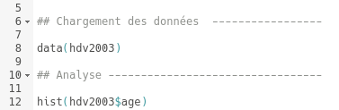

Section de script dépliée

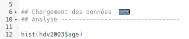

Section de script repliée

De plus, en cliquant sur l’icône *Show document outline* (la plus à droite de la barre d’outils de la fenêtre du script), ou en utilisant le raccourci clavier `Ctrl+Maj+O`, RStudio affiche une “table des matières” automatiquement mise à jour qui liste les sections existantes et permet de naviguer facilement dans le script :

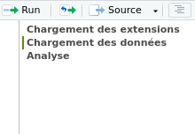

Liste dynamique des sections

### 1.2.16 Forcer la NON utilisation de la notation scientifique

On préfére voir les nombres affichés dans leur forme décimale.

Avec la notation scientifique;  
0.00000000123 est affiché comme 1.23e-9 ;  
1 230 000 est affiché comme 1.23e6.

Pour désactiver la notation scientifique, on va utiliser la valeur 100 au niveau de l’argument `scipen` :

```r
  # options par défaut
  # options("digits" = 7, scipen = 0)
  # 1.520e+10 5.498e+08 7.220e-05
options(scipen = 100) # Désactive la notation scientifique
```

`options(scipen = n)` : Si on définit scipen à une valeur n, R affichera les nombres en notation scientifique si leur exponentielle est supérieure ou égale à n ou inférieure ou égale à -n.

### 1.2.17 Répartir son travail entre plusieurs scripts

Pour éviter d’avoir un script trop long, il peut être intéressant d’isoler certaines parties d’un script, par exemple pour pouvoir les mutualiser. On peut alors répartir les étapes d’une analyse entre plusieurs scripts.

On peut par exempe regrouper des recodages dans un script à part (nommé, par exemple, `recodages.R`).

Pour exécuter ces recodages, on peut utiliser la fonction `source` : celle-ci prend en paramètre un nom de fichier `.R`, et quand on l’exécute elle va exécuter l’ensemble du code contenu dans ce fichier. Dans ce cas, rien ne s’affiche dans la console lors de l’exécution.

Ainsi, un début de script `analyse.R` pourra ressembler à ceci :

```r
# Analyse des données Histoire de vie 2003

# Chargement des données ----

library(questionr)

data(hdv2003)
source("recodages.R")

# Analyse de l'âge ----

hist(hdv2003$age)

(...)
```

# 2 Les packages

Les *packages* sont des regroupements de fonctions permettant de faciliter l’écriture de scripts R.

## 2.1 Installation des packages

### 2.1.1 Installation standard

L’installation est à réaliser *une seule fois* pour une version de R donnée (comme on le fait pour installer un programme sur son PC). Installer un package va télécharger l’ensemble des fichiers nécessaires depuis l’une des machines du CRAN, puis installer tout ça sur le disque dur de l’ordinateur.

Il est recommandé d’utiliser la fonction `install.packages` pour installer et mettre à jour les *packages*.

Par exemple, pour installer le *package* `questionr` on peut exécuter la commande :

```r
install.packages("questionr")
```

Lors de l’ouverture d’un script, `RStudio` tente de détecter automatiquement si les *packages* utilisés dans celui-ci sont installés. Dans le cas contraire, il affiche un bandeau en haut du script proposant d’installer les *packages* manquants : `▲ _package_ --- required but is not installed. Install Don't show again`

À l’ouverture, si un package est manquant, on a la mention en haut du fichier de code indiquant qu’un package (ou plusieurs) n’est pas installé.

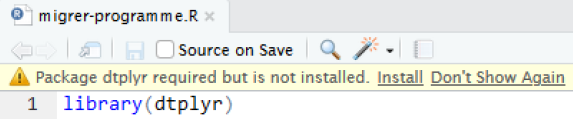

Il est préférable de ne pas installer des *packages* en cliquant sur le bouton `Install` du bandeau. En effet, garder la trace des installations dans un script avec l’utilisation de la fonction `install.packages` permet de faciliter les réinstallations de *packages*, lors de changements de version de R notamment.

Les *packages* `R` sont spécifiques à la version de `R` avec laquelle ils ont été installés. La principale conséquence pratique de cette caractéristique est qu’il faut réinstaller les *packages* lors d’un changement de version de `R`.

Cette réinstallation est facilitée en utilisant un script `installation_packages.R` avec une ligne `install.packages` pour chaque *package* utilisé.

Il peut arriver qu’un programme génère une erreur parce qu’on utilise un *package* dans une version trop ancienne. Pour mettre à jour un *package*, il suffit de le réinstaller avec `install.packages`.

**Des problèmes d’installation ?**

Ce n’est pas parce que vous avez des messages/ des warnings/ du rouge dans votre console que vous avez eu un problème d’installation. Les problèmes d’installation sont relativement souvent liés à un problème dans l’installation des dépendances. Une dépendance est un package dont a besoin le package qu’on est en train d’installer et qui peut donc s’installer en même temps.  
Dans ce cas cela peut être une bonne idée d’installer la dépendance “qui coince” en premier, puis retenter l’installation du package.

### 2.1.2 Installer une version plus récente que la version compilée (le fichier binaire)

L’argument `type` de `install.packages` permet de choisir une méthode alternative à la valeur par défaut, `"win.binary"`. Utiliser `type = "source"` permet par exemple de récupérer une version plus récente d’un *package*.

```r
install.packages("nom_du_package", type = "source")
```

### 2.1.3 Installer depuis un fichier

Il est aussi possible d’installer un *package* depuis une archive compressée (fichiers “.zip” pour les binaires Windows ou “.tar.gz” pour les *packages* *source*). Pour indiquer que la source est un fichier local, il est obligatoire de spécifier `repos = NULL`. repos (pour repository) correspond au dépôt, au lieu de stockage des packages.

```r
install.packages("chemin/en/local/package1_x.y.z.zip", repos = NULL)
```

Si le fichier est de type “source” (extension .tar.gz), Rtools peut s’avérer nécessaire.

### 2.1.4 Modifier la configuration pour pouvoir installer les packages via internet

`R sur son poste local`

En cas par exemple de messages de style :

```r
> install.packages("haven")
Warning in install.packages :
  impossible d'accéder à l'index de l'entrepôt https://cran.rstudio.com/src/contrib:
  impossible d'ouvrir l'URL 'https://cran.rstudio.com/src/contrib/PACKAGES'
```

Préciser l’adresse du `proxy` permettant l’accès à internet, pour télécharger les packages.

Mettre cette adresse (“…proxy…:8080”) dans les variables d’environnement `http_proxy` et `https_proxy`.

Ouvrir le fichier `~/.Renviron` avec la commande :

```r
file.edit("~/.Renviron")
```

Indiquer les lignes suivantes dans le fichier `~/.Renviron` (en remplaçant “…proxy…:8080” par l’adresse du proxy) :

```r
http_proxy="...proxy...:8080"
https_proxy="...proxy...:8080"
```

Redémarrer RStudio après avoir modifié le fichier .Renviron pour que les changements prennent effet.

Tester la connexion à un site internet en mettant dans la console RStudio :

```r
url <- "https://cran.r-project.org"
readLines(url, n = 10)
```

Pour l’installation des packages, on obtient alors

```r
> install.packages("haven")
essai de l'URL 'https://cran.rstudio.com/bin/windows/contrib/4.3/haven_2.5.4.zip'
Content type 'application/zip' length 765340 bytes (747 KB)
downloaded 747 KB

le package ‘haven’ a été décompressé et les sommes MD5 ont été vérifiées avec succés

Les packages binaires téléchargés sont dans
    C:\Users\prenom.nom\AppData\Local\Temp\RtmpkjoM8c\downloaded_packages
```

Pour connaitre l’emplacement du fichier .Renviron, lancer dans la console RStudio

```r
# Pour obtenir le chemin du répertoire personnel
Sys.getenv("HOME")

# [1] "C:/Users/prenom.nom/Documents"
```

Le fichier avec un point `.Renviron` sert pour la personnalisation utilisateur des variables d’environnement.

Il est aussi possible de modifier le fichier Renviron.site pour l’ensemble des utilisateurs du PC (par exemple en salle de formation).

Ouvrir le fichier `R_HOME/etc/Renviron.site` avec la commande suivante :

```r
# ouvrir le fichier Renviron.site situé dans le dossier R_HOME/etc/
# où R_HOME est le dossier d'installation de R
file.edit(file.path(R.home(), "etc", "Renviron.site"))
```

Indiquer les lignes suivantes dans le fichier Renviron.site (en remplaçant “…proxy…:8080” par l’adresse du proxy) :

```r
http_proxy="...proxy...:8080"
https_proxy="...proxy...:8080"
```

Redémarrer RStudio après avoir modifié le fichier Renviron.site pour que les changements prennent effet.

Le fichier Renviron.site est un fichier de configuration système qui permet de définir des variables d’environnement communes pour tous les utilisateurs de R du PC.

Pour connaitre l’emplacement du fichier Renviron.site, lancer dans la console RStudio

```r
# Pour obtenir le répertoire d'installation de R (R_HOME)
R.home()
# [1] "C:/Program Files/R/R-x.y.z"
```

Le fichier de configuration d’environnement global Renviron.site se trouve généralement dans le dossier etc/ de l’installation R.

Le fichier .Renviron de l’utilisateur courant surcharge le fichier Renviron.site, qui est lu en premier lors du démarrage de R.

### 2.1.5 Installation de Rtools en cas de difficulté sur son poste de travail

`R sur son poste local`

Installer une seule fois Rtools (outils de compilation pour R) à partir de https://cran.r-project.org/bin/windows/Rtools. Par exemple https://cran.r-project.org/bin/windows/Rtools/rtools40.html

Il convient de télécharger rtools40-x86_64.exe vers `D:\user\R\packages` puis de lancer rtools40-x86_64.exe. Comme répertoire d’installation, choisir `D:\user\R\rtools40`. Décocher l’ensemble des options par défaut, notamment les options qui écrivent dans le registre.

Après l’installation, mettre la location des outils *make* (bash, make, etc) dans le PATH.

```r
write('PATH = "${RTOOLS40_HOME}\\usr\\bin;${PATH}"', file = "~/.Renviron", append = TRUE)
```

Redémarrer R et verifier que *make* peut être trouvé, ce qui devrait montrer le chemin (path) de l’installation de Rtools.

```r
Sys.which("make")
```

donne “D:\user\R\rtools40\usr\bin\make.exe”,  
avant on avait par exemple “C:\R\rtools40\usr\bin\make.exe”

### 2.1.6 Avoir des informations sur les packages installés

```r
# pour connaitre les chemins vers lesquels pointe R pour chercher des packages installés
.libPaths()
# "/var/data/nfs/CERISE/00-Espace-Personnel/prenom.nom/R/x86_64-pc-linux-gnu-library/4.4"

# éléments du répertoire :
list.files("~/CERISE/00-Espace-Personnel/prenom.nom/R/x86_64-pc-linux-gnu-library/4.4")

View(installed.packages()) # affiche tous les packages installés

row.names(x = installed.packages(priority = c("base", "recommended")))
row.names(x = installed.packages(
                        lib.loc = c("~/CERISE/00-Espace-Personnel/prenom.nom/R/x86_64-pc-linux-gnu-library/4.4")))
```

### 2.1.7 Installation de packages sur Cerise avec difficulté

Les dernières versions de certains packages ne peuvent parfois pas s’installer sur CERISE à cause de librairies du système d’exploitation absentes ou anciennes. Parfois aussi (mais pas toujours), installer une version précédente du package permet de contourner ce problème.

Voir le guide Installation de packages https://orion.agriculture/confluence/display/CER/Installation+de+packages

Il faut d’abord installer `remotes` :

```r
install.packages("remotes")

# Tidyverse
remotes::install_version("tidyverse", "1.3.0")

# COGugaison
# Téléchargement de https://github.com/antuki/COGugaison/archive/refs/heads/master.zip

# → COGugaison-master.zip, on dézippe on enlève "-master", on re-zippe puis on upload dans Cerise.

devtools::install_local("/mon/chemin/vers/le/COGugaison.zip", INSTALL_opts = c("--no-lock"))

# sf
remotes::install_version("sf", version = "0.9-0")
```

Installation de versions plus anciennes, en précisant un numéro de version

```r
remotes::install_version("sf", ">= 0.7-0", dependencies = TRUE, type = "source")
# Warning: unable to access index for repository https://forge.agriculture.rie.gouv.fr/artifactory/ssp-cran-prod-local/src/contrib:
#   cannot open URL 'https://forge.agriculture.rie.gouv.fr/artifactory/ssp-cran-prod-local/src/contrib/PACKAGES'
# Downloading package from url: https://forge.agriculture.rie.gouv.fr/artifactory/cran-r-prod-remote/src/contrib/sf_1.0-14.tar.gz
```

Exemple d’installation d’une ancienne version de package en plusieurs étapes

```r
# suppression d'un package
remove.packages(pkgs = "cli",
                lib = c("~/CERISE/00-Espace-Personnel/prenom.nom/R/x86_64-pc-linux-gnu-library/4.4"))

# suppression de l'ensemble des packages pour repartir de zéro
remove.packages(pkgs = row.names(
  x = installed.packages(lib.loc = c("~/CERISE/00-Espace-Personnel/prenom.nom/R/x86_64-pc-linux-gnu-library/4.4"))),
                lib = c("~/CERISE/00-Espace-Personnel/prenom.nom/R/x86_64-pc-linux-gnu-library/4.4"))

row.names(x = installed.packages(
  lib.loc = c("~/CERISE/00-Espace-Personnel/prenom.nom/R/x86_64-pc-linux-gnu-library/4.4")))
# NULL

# install.packages("tidyverse")
# ERROR: dependency ‘ragg’ is not available for package ‘tidyverse’
# * removing ‘/var/data/nfs/CERISE/00-Espace-Personnel/prenom.nom/R/x86_64-pc-linux-gnu-library/4.4/tidyverse’
# Warning in install.packages :
#   installation of package ‘tidyverse’ had non-zero exit status

# installation d'une version plus ancienne tidyverse_1.3.2.tar.gz   2022-07-18
# https://cran.r-project.org/src/contrib/Archive/tidyverse/
# installation packages préalables
install.packages(c("broom", "dbplyr", "dtplyr", "googledrive", "googlesheets4", "httr",
                    "modelr", "reprex", "rvest"))
install.packages(
  "~/CERISE/01-Espace-de-Partage/SRISE/Pays-De-La-Loire/Partage_R/Christophe/packages/tidyverse_1.3.2.tar.gz",
                 repos = NULL, type = "source")
# Error in loadNamespace(j <- i[[1L]], c(lib.loc, .libPaths()), versionCheck = vI[[j]]) :
# namespace ‘forcats’ 0.5.0 is being loaded, but >= 0.5.1 is required
# namespace ‘readr’ 1.3.1 is being loaded, but >= 2.1.1 is required
install.packages("forcats")
install.packages("readr")
install.packages(
  "~/CERISE/01-Espace-de-Partage/SRISE/Pays-De-La-Loire/Partage_R/Christophe/packages/tidyverse_1.3.2.tar.gz",
                 repos = NULL, type = "source")
# * DONE (tidyverse)
```

## 2.2 Utilisation des packages

Une fois le package installé, il faut le “charger” avant de pouvoir utiliser les fonctions qu’il propose. En début du code, on commence par charger le *package* `nom_du_package` avec la commande `library(nom_du_package)`. Le **chargement** consiste à indiquer à `R` que l’on souhaite utiliser le *package* dans la session courante. C’est une opération qu’il faut réaliser *à chaque fois* que l’on ouvre une session `R`.

Ainsi, on regroupe en général en début de script toute une série d’appels à `library` qui permettent de charger tous les packages utilisés dans le script.

On peut utiliser nom_package::nom_fonction pour préciser explicitement de quel package on utilise la fonction nom_fonction.  
L’utilisation de l’opérateur `::` permet de ne pas charger le package en mémoire, ce qui peut être utile si on utilise une seule fonction d’un package.  
Cela permet aussi d’éviter les conflits de noms de fonctions entre les packages.

```r
# Charger les packages nécessaires
# Packages souvent utilisés
library(dplyr)
library(openxlsx2)
library(janitor) # pour nettoyer et préparer des données ('make_clean_names')
library(tidyr) # pour pivot
library(fs) # pour path
```

On peut voir si le package est chargé dans la fenêtre Services (en bas à droite).  
Dans l’onglet Packages, on a la liste des package installés.  
Si la case devant le nom du package est cochée, c’est qu’il est chargé en mémoire.

# 3 Import / export

## 3.1 Importer

La première étape d’une chaîne de traitement est d’accéder aux données à traiter. Il convient d’indiquer dans le script de préparation des données comment le fichier est arrivé, soit en codant les instructions de téléchargement, soit en ajoutant des commentaires qui permettront plus tard de reconstituer le jeu de données utilisé.

- **Il est conseillé d’importer uniquement les colonnes dont on a besoin.** Dans le cas où on ne sait pas quelles sont les colonnes dont on a besoin, il est conseillé de commencer par importer un petit nombre de lignes (par exemple 1 000 ou 10 000) afin d’étudier les données et de choisir ensuite les colonnes à importer.
- **Il est conseillé de nettoyer les noms de colonnes après l’import.** `janitor::make_clean_names` permet notamment d’obtenir des noms de variables propres et cohérents : tout en minuscules, sans espaces ni caractères spéciaux. Elle remplace les caractères non autorisés par des underscores (traits de soulignement _).

```r
df <- tibble::as_tibble(df, .name_repair = janitor::make_clean_names)
```

Il faut indiquer le chemin vers le fichier qu’on souhaite importer entre quotes (““).

Utiliser `fs::path()` pour construire un chemin de fichier. Cette fonction est utilisée pour combiner plusieurs composants du chemin de fichier, tels que les répertoires et le nom du fichier, en un seul chemin de fichier complet.

```r
# Charger le package
library(fs)
# Gestion des extensions en utilisant le paramètre .ext.
chemin <- path("dossier1", "dossier2", "fichier", .ext = "xlsx")

repertoire_ra_2020 <- "CERISE/03-Espace-de-Diffusion/030_Structures_exploitations"
fichier_ra_exploit_2020 <- "RA2020_EXPLOITATIONS_240112.rds"

chemin_fichier <- path(repertoire_ra_2020, fichier_ra_exploit_2020)

exploit_2020 <- readRDS(file = chemin_fichier)
```

Le package `fs` offre des fonctionnalités pour manipuler les fichiers et les répertoires, comme :  
`dir_ls()` : Lister les fichiers dans un répertoire.  
`file_move()` : Déplacer des fichiers.  
`file_copy()` : Copier des fichiers.  
`file_delete()` : Supprimer des fichiers.  
`dir_create()` : Créer des répertoires.

### 3.1.1 Importer des fichiers RDS

```r
library(dplyr)
library(janitor) # pour 'make_clean_names' pour standardiser la syntaxe des noms de colonnes
library(fs) # pour path

# import fichiers
chemin_geographie <- "~/CERISE/01-Espace-de-Partage/SRISE/Pays-De-La-Loire/Partage_R/
Christophe/Geographie/sortie/"

fichier_geographie_dep <- "dep_reg_lib.RDS"
fichier_geographie_reg <- "reg_lib.RDS"

geographie_dep <- readRDS(file = path(chemin_geographie, fichier_geographie_dep)) |>
  as_tibble(.name_repair = make_clean_names)

geographie_reg <- readRDS(file = path(chemin_geographie, fichier_geographie_reg)) |>
  as_tibble(.name_repair = make_clean_names)

# Chargement des données
# recensement agricole 2020 PDL DONNEES INDIVIDUELLES
chemin_pdl_20 <- "S:/Fichiers source/RA 2020_déf/BASES_RA2020_data_def_15avril2022/RDS/"
annee_ra_2020            <- 2020

exploit_pdl_2020 <- readRDS(file = path(chemin_pdl_20,
                                        "RA2020_EXPLOITATIONS_R52_220415_modif_27juin2022.rds")) |>
  as_tibble(.name_repair = make_clean_names)

pa_pdl_2020 <- readRDS(file = path(chemin_pdl_20,"RA2020_PRODANIM_R52_220415.rds")) |>
 as_tibble(.name_repair = make_clean_names)

mo_pdl_2020 <- readRDS(file = path(chemin_pdl_20,"RA2020_MO_CHEF_COEXPL_R52_220415.rds")) |>
  as_tibble(.name_repair = make_clean_names)

# RA2020 DONNEES INDIVIDUELLES France
chemin_fr_20 <- "D:/user/RA2020/RA2020_source/RDS/"

exploit_dep_2020 <- readRDS(file = path(chemin_fr_20,"RA2020_EXPLOITATIONS_220415.rds")) |>
  as_tibble(.name_repair = make_clean_names) |>
  filter(siege_dep %in% c("44", "49", "53", "72", "85"))

pa_fr_2020 <- readRDS(file = path(chemin_fr_20, "RA2020_PRODANIM_220415.rds")) |>
 as_tibble(.name_repair = make_clean_names)
```

### 3.1.2 Importer des fichiers xlsx

Pour importer dans `R` des données issues de tableurs avec l’extension`xlsx`, il est recommandé d’utiliser la fonction `read_xlsx()` du *package* `openxlsx2`.

Voici les principaux arguments et options de `read_xlsx()` :

| Argument | Valeur par défaut | Fonction |
| --- | --- | --- |
| `file` | Aucune | Chemin d’accès vers un fichier `xlsx` à importer |
| `sheet` | `1` | Onglet à importer. Soit le nom de l’onglet (entre guillemets), soit un numéro de l’onglet |
| `start_row` | `1` | Ligne à partir de laquelle les données sont importées. |
| `col_names` | `TRUE` | Si `TRUE`, la première ligne de données sera utilisée comme nom de colonnes |

```r
library(dplyr)
library(openxlsx2)
library(janitor) # pour 'make_clean_names'
library(fs) # pour path

# import fichiers
chemin_entree <- "S:/ETUDES/En cours/memento_Christophe/entree/SAA/"
fichier_entree <- "cd2022-5_SAA_2021_provisoire_resultats_LIB.xlsx"

eff_volailles <- read_xlsx(file = path(chemin_entree, fichier_entree),
                           sheet = "Eff. volailles") |>
  as_tibble(.name_repair = make_clean_names) |>
  filter(region %in% c("52  -  Pays de la Loire",
                       "98  -  Total France métropolitaine"))


chemin <- "S:/ETUDES/En cours/memento_Christophe/entree/AgenceBio/"
fichier_nat <- "Export Productions Bio - National.xlsx"
an <- "2025"

agri_bio_vegetal_fr <- read_xlsx(file = path(chemin,fichier_nat),
                                 sheet = "Productions végétales") |>
  as_tibble(.name_repair = make_clean_names) |>
  filter(annee %in% c(an) & territoire %in% c("National","Pays de la Loire"))

# fichier annuel présent sur Cerise
# 03-Espace-de-Diffusion/070_Production_lait/7020_Enqu_Annuelle_Laitiere/
EAL_2021_resultats_definitifs_septembre_2022

chemin_entree_2021 <- "~/CERISE/03-Espace-de-Diffusion/070_Production_lait/
7020_Enqu_Annuelle_Laitiere/EAL_2021_resultats_definitifs_septembre_2022/"

fichier_entree_liv_reg_dep <- "LIVRAISON_REGNDEP_2020_2021.xlsx"

laits_reg_dep_2021 <- read_xlsx(file = path(chemin_entree_2021, fichier_entree_liv_reg_dep),
                                sheet = "Sheet 1") |>
  as_tibble(.name_repair = make_clean_names) |>
  mutate(reg_dep_prod = paste0(regnprod,sep = "_", depprod),
         dep_prod = substr(depprod, 2, 3))
```

### 3.1.3 Importer des fichiers xls

L’utilisateur souhaite importer dans `R` des données issues de tableurs (extension type `xls`).

- **Il est recommandé d’utiliser la fonction `read_xls()` du *package* `readxl` pour importer des fichiers `xls`.**

Voici les principaux arguments et options de `read_xls()` :

| Argument | Valeur par défaut | Fonction |
| --- | --- | --- |
| `path` | Aucune | Chemin d’accès au fichier xls à importer |
| `sheet` | `NULL` | Onglet à importer Soit le nom de l’onglet, soit la position de l’onglet. Par défaut, sélectionne le premier onglet du fichier |
| `col_names` | `TRUE` | `TRUE` pour utiliser la première ligne comme noms de colonne, `FALSE` pour obtenir les noms par défaut ou un vecteur de caractères donnant un nom à chaque colonne |
| `col_types` | `NULL` | Préciser le type des colonnes. Si `col_types = NULL`, `readxl` essaie de deviner le type des colonnes. Voir `?readxl::read_xls` pour l’usage de cette option |
| `na` | “” | Vecteur de chaînes de caractères à interpréter comme des valeurs manquantes |
| `skip` | `0` | Nombre de lignes à ignorer avant d’importer les données |
| `n_max` | `Inf` | Nombre maximum de lignes de données à lire |

```r
library(dplyr)
library(readxl)
library(fs) # pour path

# Chargement du chemin
chemin <- "S:/ETUDES/En cours/memento_Christophe/entree/volailles_qualite/Qualite_volailles_2021/"
fichier <- "Abattages_signes_qualite_2021_modif.xls"

volailles_pdl_espece_siqo <- read_xls(path = path(chemin, fichier),
                                      sheet = "res_nouvelle_region_modif",
                                      skip = 9) |>
  as_tibble(.name_repair = make_clean_names) |>
  filter(espece %in% c("siqo", "PAYS DE LA LOIRE"))
```

- **Définir le type des colonnes** : le paramètre `col_types` permet de définir explicitement le type des colonnes et d’ignorer les colonnes qu’on ne souhaite pas importer. Pour cela, on passe au paramètre `col_types` un vecteur précisant le type parmi les possibilités suivantes :
  - `"skip"` : ignorer la colonne (qui ne sera pas importée) ;
  - `"guess"` : le type de la variable est devinée par rapport à ses *modalités* ;
  - `"list"` : crée une liste ;
  - `"logical` pour une variable booléenne, `"numeric"` pour une variable numérique, `"date"` pour une date et `"text"` pour une variable caractère.

  Le type de la variable sera appliqué aux colonnes dans l’ordre défini par le vecteur. Exemple : `c("text","text","numeric","guess","skip","logical")`. Dans le cas où on souhaite définir le même type pour toutes les colonnes, il suffit de préciser une seule fois le type attendu (exemple `col_types = "text"`).
- **Gestion des `NA`** : il est possible de préciser les valeurs qu’on souhaite considérer comme des `NA` avec le paramètre `na`. Par défaut, la valeur `""` est considérée comme `NA`.

https://book.utilitr.org/03_Fiches_thematiques/Fiche_import_tableurs.html#importer-un-fichier-xls-avec-le-package-readxl

### 3.1.4 Importer des fichiers ods

L’utilisateur souhaite importer dans `R` des données issues de tableurs (extension `ods`).

- **Il est recommandé d’utiliser la fonction `read_ods` du *package* `readODS` pour importer des fichiers `ods`.**

Voici les principaux arguments et options de `read_ods()` :

| Argument | Valeur par défaut | Fonction |
| --- | --- | --- |
| `path` | Aucune | Le chemin du fichier `ods` à importer |
| `sheet` | 1 | Onglet à importer. Soit le nom de l’onglet, soit le numéro de l’onglet (utiliser de préférence le nom de l’onglet) |
| `col_names` | `TRUE` | Indique si la première ligne de l’onglet contient les noms des variables |
| `col_types` | `NULL` | `NULL` pour laisser `R` deviner le type des variables à partir de l’onglet ou se reporter à `readr::type_convert` pour spécifier le type des variables |
| `na` | `""` | Vecteur donnant les chaîne de caractères interprétées comme des valeurs manquantes. Par défaut, `read_ods` convertit les cellules vides en données manquantes |
| `skip` | `0` | Le nombre de lignes du fichier de données à ignorer avant de commencer à importer les données |

```r
library(readODS)
library(fs) # pour path

# Chargement du 3ème onglet
mesDonnees <- readODS::read_ods(path = chemin_ods, sheet = "Sheet3", skip = 5)

# Chargement du chemin
chemin_entree <- "S:/ETUDES/En cours/Fiche filière volailles/conjoncture volailles/2022_s1/entree/"
fichier_entree <- "COMEXOEUFS_France.ods"

oeufs <- read_ods(path = path(chemin_entree, fichier_entree), sheet = "Données", skip = 0)

# Chargement du chemin
chemin  <- "~/CERISE/01-Espace-de-Partage/SRISE/Pays-De-La-Loire/Partage_R/Christophe/Volailles/entree/"
fichier_cotation <- "Cotations_modif.ods"

# Import + ajout annee mois
vol_oeufs_cot <- read_ods(path = path(chemin, fichier_cotation),
                   sheet = "VolaillesOeufsLapinsMensuel", skip = 2) |>
  as_tibble(.name_repair = make_clean_names)
```

### 3.1.5 Importer des fichiers plats (csv, txt)

L’utilisateur souhaite importer dans `R` des données stockées sous forme de fichiers plats (formats `.txt`, `.csv`, `.tsv`).  
Les “fichiers plats” sont des fichiers texte qui stockent des données avec des délimiteurs pour séparer les colonnes.  
Ces fichiers contiennent des données tabulaires, c’est-à-dire des données organisées sous forme de tableau, avec en lignes les observations et en colonnes les variables.

Le *package* `readr` propose plusieurs fonctions adaptées pour importer des fichiers plats de taille limitée (moins de 1 Go) :

- `read_csv()` : lecture d’un csv délimité par des virgules, avec un point comme marqueur décimal
- `read_csv2()` : lecture d’un csv séparé par des points-virgules, avec une virgule comme marqueur décimal
- `read_delim()` : fonction plus générale et paramétrable, pour lire des fichiers délimités.

Il faut charger le *package* `readr` pour utiliser ces fonctions :

```r
library(readr)
```

```r
library(dplyr)
library(readr)
library(janitor)
library(fs) # pour path

# Définition d'un opérateur `%not_in%` pour plus de clarté dans les filtres
`%not_in%` <- purrr::negate(`%in%`)

# source : https://agreste.agriculture.gouv.fr/agreste-web/disaron/COMPT0005_NRP/detail/
# Comptes régionaux de l'agriculture : productions et subventions sur les produits
# Fichier de données secrétisées FDS_COMPT0005_NRP.zip

# import fichiers

# Chargement du chemin
chemin <- "S:/ETUDES/En cours/memento_Christophe/entree/volailles_abattage/ABATVOL_2021/"
chemin_entree <- "./entree/comptes_prod/"

fichier_entree <- "DIFFABATVOL_2021.csv"
fichier_entree_prod <- "FDS_COMPT0005_NRP_2020.txt"

volailles_pdl <- read_csv2(file = path(chemin, fichier_entree)) |>
  as_tibble(.name_repair = make_clean_names) |>
  filter(reg %in% c("52")) |>
  mutate(siret = as.character(siret))

# Encodage du fichier .csv trouvé avec la fonction guess_encoding du package 'readr'
guess_encoding(file = path(chemin_entree, fichier_entree_eff_avant_2010),
               n_max = 1000)

# A tibble: 1 × 2
#   encoding   confidence
#   <chr>           <dbl>
# 1 ISO-8859-1       0.77

# locale(encoding = )
# Encodage par défaut. Cela n'affecte que la façon dont le fichier est lu
# readr convertit toujours la sortie en UTF-8.
eff_volailles_avant_2010 <- read_csv2(file = path(chemin_entree, fichier_entree_eff_avant_2010),
                                      locale = locale(encoding = "ISO-8859-1")) |>
  as_tibble(.name_repair = make_clean_names) |>
  filter(reg %not_in% c("01 : Guadeloupe","02 : Martinique","03 : Guyane","04 : La Réunion"),
         annee %in% 2000:2010)

# lecture d’un txt séparé par des points-virgules, avec un point comme marqueur décimal
comptes_prod <- read_delim(file = path(chemin_entree, fichier_entree_prod),
                           delim = ";",
                           locale = locale(decimal_mark = ".")) |>
  as_tibble(.name_repair = make_clean_names) |>
  rename(libelle_produits = libelle_produits_compt0005_nrp_dim1,
         libelle_indic_n027 = libelle_indicateurs_n027)
```

La fonction `read_delim()` de `readr` permet d’importer les données d’un fichier csv.

`read_csv()`, `read_csv2()` et `read_tsv()` sont des implémentations pré-renseignées de `read_delim` pour lire des fichiers plats avec séparateurs (caractère délimiteur de colonne) **,** **;** et **tabulaire**.

Chaque fonction dispose de plusieurs arguments, parmi lesquels :

- `col_names` indique si la première ligne contient le nom des colonnes (`TRUE` par défaut)
- `col_types` permet de spécifier manuellement le type des colonnes si `readr` ne les identifie pas correctement
- `na` est un vecteur de chaînes de caractères indiquant les valeurs devant être considérées comme manquantes. Ce vecteur vaut `c("", "NA")` par défaut

Pour spécifier le type des colonnes, on peut préciser le type à utiliser par défaut puis faire la liste des variables ayant un type différent de cette valeur par défaut :

```r
exploitations <- read_csv2("mes_donnees_exploitations.csv",
        col_types = cols(.default = col_character(),
                         SAU = col_double(),
                         UGB = col_double()))
```

On spécifie le type des variables à l’aide des fonctions suivantes :  
- `col_character()` pour une variable de type caractère  
- `col_double()` pour une variable de type numérique (décimal)  
- `col_integer()` pour une variable de type entier  
- `col_logical()` pour une variable de type booléen (TRUE ou FALSE)  
- `col_date()` pour une variable de type date (jour, mois, année)  
- `col_factor()` pour une variable de type facteur (variable qualitative, avec un nombre prédéfini et limité de modalités)

https://book.utilitr.org/03_Fiches_thematiques/Fiche_import_fichiers_plats.html

https://book.utilitr.org/03_Fiches_thematiques/Fiche_import_fichiers_plats.html#utiliser-la-fonction-read_delim

### 3.1.6 Importer des fichiers parquet

Le format **Parquet** est un format de stockage particulièrement adapté aux données volumineuses.

Le package **`arrow`** permet de lire ces fichiers de manière performante, sans devoir tout charger en mémoire.

On privilégiera l’approche `open_dataset()` lorsque la volumétrie des données est importante.

L’ordre optimal pour l’import pour minimiser la charge en mémoire est :

```r
donnees <- open_dataset("chemin/vers/fichier.parquet") |>
  filter()    # 1. Filtrer d'abord (réduit les lignes)
  select()    # 2. Sélectionner les colonnes (réduit les colonnes)
  collect()   # 3. Charger en mémoire
```

L’appel à `collect()` ne charge en mémoire que les sous-ensembles filtrés, ce qui est très utile pour les gros volumes. `collect()` renvoie le résultat du traitement sous la forme d’un `tibble`.

```r
library(arrow) # pour lire les fichiers parquet
library(dplyr) # pour la manipulation de données
library(fs)    # pour la gestion des chemins de fichiers

# import fichiers ----
# source : insee, flores
chemin_entree <- "~/CERISE/03-Espace-de-Diffusion/150_Sources_externes/15070_INSEE/FLORES/1_TABLES/"
chemin_an <- "2023/"
fichier_entree_etab <- "flores_etab_2023.parquet"

# méthode conseillée pour des fichiers volumineux
# Établir la connexion aux données
donnees_flores <- open_dataset(sources = path(chemin_entree,
                                              chemin_an,
                                              fichier_entree_etab))

# Afficher les noms de colonnes
names(donnees_flores)

# Nom et type des variables
donnees_flores

# Obtenir les valeurs distinctes et triées de 'reg' (exécution lors du collect)
liste_reg <- donnees_flores |>
  distinct(reg) |>
  arrange(reg) |>
  collect()

# Conversion en vecteur simple
reg_vecteur <- liste_reg$reg
print(reg_vecteur)

# Variante avec pull() pour obtenir directement un vecteur
liste_a17 <- donnees_flores |>
  select(a17) |>
  distinct() |>
  collect() |>
  pull(a17)

print(liste_a17)

# Définir une requête optimisée
# Filtrer d'abord pour réduire le volume
# Sélectionner uniquement les colonnes nécessaires
requete <- donnees_flores |>
  filter(reg == "52",
         a17 %in% c("C1")) |> # réduire d'abord le nombre de lignes
  select(reg, a17, siren, eff_etab) # limiter les colonnes

# Récupérer le résultat sous forme d'un tibble
iaa_etab_pdl <- requete |>
  collect()

# nom, type et extrait des variables
str(iaa_etab_pdl)
```

https://book.utilitr.org/03_Fiches_thematiques/Fiche_import_fichiers_parquet.html  
https://book.utilitr.org/03_Fiches_thematiques/Fiche_arrow.html  
https://ssm-agriculture.github.io/formation-R-perf-06-parquet/  
https://ssm-agriculture.github.io/formation-R-perf-06-parquet/#/comment-bien-utiliser-des-fichiers-partitionn%C3%A9s-avec-arrow-12

### 3.1.7 Importer des fichiers SPSS (.sav)

L’utilisateur souhaite importer dans `R` des données stockées sous forme de fichiers SPSS.

La méthode recommandée est d’utiliser la fonction `read_spss()` du *package* `haven`.

```r
# Charger les packages
library(haven)
library(fs) # pour path

# Importer un fichier SPSS
tableau <- haven::read_spss(path(chemin, fichier_entree))

# Importer un fichier SPSS
fichier_entree_mensuel <- "COLLECTE_TOUS_LAITS.sav"

laits_mensuel_1 <- haven::read_spss(path(chemin_entree_mensuel, fichier_entree_mensuel)) |>
  as_tibble(.name_repair = make_clean_names)
```

### 3.1.8 Importer des fichiers SAS

L’utilisateur souhaite importer dans `R` des données stockées sous forme de tables SAS.

La méthode recommandée est d’utiliser la fonction `read_sas()` du *package* `haven`.

```r
# Charger le package haven
library(haven)

# Importer une table SAS.
# Utilisation de la table de passage des codes communes depuis 1943
# vers les codes communes en vigueur en 2022,
comdepuis1943_com2022 <- read_sas("S:/ETUDES/memento/entree/geographie/geo2022/fcodcomm.sas7bdat")
```

### 3.1.9 Importer des objets `RData`

Parfois des données sont enregistrées au format `RData`. Ce format propre à R permet d’enregistrer plusieurs objets R, quel que soit leur type, dans un même fichier.

Pour enregistrer des objets, on utiliser la fonction `save` en lui fournissant la liste des objets à sauvegarder et le nom du fichier :

```r
save(df, rp2018, tab, file = "fichier.RData")
```

Pour charger des objets préalablement enregistrés, utiliser `load` :

```r
load("fichier.RData")
```

Les objets `df`, `rp2018` et `tab` sont importés directement dans l’environnement en cours avec leur nom d’origine. Si d’autres objets du même nom existent déjà, ils sont écrasés sans avertissement.

### 3.1.10 Importer des fichiers avec en-tête sur 2 lignes

Dans le cas où les noms de colonnes sont répartis sur deux lignes d’en-tête au lieu d’une, on peut importer les données en concaténant le contenu des deux lignes d’en-tête.

```r
# import ----
# Chargement du chemin
chemin_entree <- "~/CERISE/03-Espace-de-Diffusion/060_Productions_viandes_oeufs/6060_Qualite_volailles/"

chemin_2023 <- "Qualite_volailles_2023/"

fichier_entree_2023 <- "Abattages_signes_qualite_2023.xls"

entetes_vol_2023 <- read_xls(path = path(chemin_entree,
                                           chemin_2023,
                                           fichier_entree_2023),
                             sheet = "res_nouvelle_region",
                             skip = 23,
                             n_max = 5,
                             col_names = FALSE) |>
  as_tibble(.name_repair = make_clean_names)

# remplacer x3 à x9 par "Poulets (y c coquelets)"...
entetes_vol_2023_ligne1 <- entetes_vol_2023 |>
  mutate(across(x3:x9, ~ "n11_Poulets"),
         across(x10:x16, ~ "n12_Chapons"),
         across(x17:x23, ~ "n13_Poules_reforme_oeufs_cons"),
         across(x24:x30, ~ "n14_Coqs_poules_reforme_reproducteurs"),
         across(x31:x37, ~ "n20_Dindes"),
         across(x38:x44, ~ "n30_Pintades"),
         across(x45:x51, ~ "n41_Canards_rotir"),
         across(x52:x58, ~ "n42_Canards_gras"),
         across(x59:x65, ~ "n51_Oies_rotir"),
         across(x66:x72, ~ "n52_Oies_grasses"),
         across(x73:x79, ~ "n80_Lapins"),
         across(x80:x86, ~ "n60_Pigeons"),
         across(x87:x93, ~ "n70_Cailles"))

# Dans le fichier excel, les noms de colonnes sont répartis sur deux lignes d’en-tête au lieu d’une.
# L’objectif est d’importer les données de ce tableau en concaténant le contenu des deux lignes d’en-tête.
# On concatène le contenu des deux lignes d’en-tête à l’aide de la fonction paste()
# Remarque : la fonction slice() permet de filtrer une table par un numéro de ligne
entetes_vol_2023_2lignes <- paste(slice(entetes_vol_2023_ligne1, 1),
                                  slice(entetes_vol_2023, 3),
                                  sep = "_siqo_")

# On restreint les lignes à lire avec skip et n_max
# La fonction setNames() permet de renommer l’ensemble des colonnes d’un data frame
# à partir d’un vecteur de nouveaux noms.
vol_2023 <- read_xls(path = path(chemin_entree,
                                   chemin_2023,
                                   fichier_entree_2023),
                     sheet = "res_nouvelle_region",
                     skip = 23,
                     n_max = 17,
                     col_names = FALSE) |>
  setNames(entetes_vol_2023_2lignes) |>
  as_tibble(.name_repair = make_clean_names)

vol_2023 <- vol_2023 |>
  rename(region=na_siqo_na_2) |>
  select(-na_siqo_na,
         -starts_with("na_"))

# Supprimer les 4 premières lignes
# sélectionne toutes les lignes sauf les 4 premières.
# Le signe `-` devant `(1:4)` indique que nous voulons exclure ces lignes.
vol_2023 <- vol_2023  |>
  slice(-(1:4))
```

```r
# import ----
chemin_entree <- "./entree/conj_bulletin/"
fichier_entree <- "Aviculture.xls"

# On restreint les lignes à lire avec skip et n_max
vol <- read_xls(path = path(chemin_entree, fichier_entree),
                sheet = "VolaillesOeufsLapins",
                skip = 1054,
                n_max = 146,
                col_names = TRUE) |>
  as_tibble(.name_repair = make_clean_names)

str(vol)

# supprimer les 3 premières lignes
# 4:n() crée un vecteur des indices à partir de la quatrième ligne jusqu’à la fin du dataframe.
# vol <- slice(vol, 4:n())

# Supprimer les 3 premières lignes
# sélectionne toutes les lignes sauf les 3 premières.
# Le signe `-` devant `(1:3)` indique que nous voulons exclure ces lignes.
vol <- vol  |>
  slice(-(1:3))

# Supprimer les lignes où il n'y a que des NA
# Supprimer les lignes avec des NA dans toutes les colonnes
# Supprimer les lignes où toutes les modalités sont NA
# avec remove_empty() du package janitor
vol <- vol |>
  remove_empty(which = "rows")

# On renomme la modalité pour les poulets qui est sur 2 lignes
# Gallus (poulets, poules de
#         réforme et chapons)
vol2 <- vol |>
  rename(especes = rubriques,
         code_especes = n) |>
  mutate(especes = case_when(
    especes == "Gallus (poulets, poules de" ~ "Poulets",
    especes == "réforme et chapons)" ~ "Poulets",
    .default = especes
  ))

# Remplacer les NA dans les colonnes désirées par la valeur de la cellule précédente
# Pour gérer les cellules fusionnées d'excel en R, on utilise la fonction `fill` du package `tidyr`
# Cette fonction remplace les valeurs NA
# par la valeur précédente (de la ligne précédente) dans la même colonne.
# Cette fonction remplit les valeurs `NA` avec la dernière valeur non-`NA` précédente.
# La fonction `fill` fonctionne de haut en bas par défaut (spécifié par `.direction = "down"`).
vol2 <- vol2 |>
  fill(especes,
       .direction = "down") |>
  select(-unite)

names(vol2)
```

### 3.1.11 Importer des fichiers de façon récurrente

Parfois une fonction n’a pas pour objectif de renvoyer un résultat mais d’accomplir une action (générer un graphique, afficher un message, enregistrer un fichier…), comme ici importer des fichiers.  
Dans ce cas la fonction peut ne pas inclure d’instruction `return()`.

```r
library(dplyr)
library(openxlsx2)
library(janitor) # pour 'make_clean_names'
library(readr)
library(purrr) # pour map

# import fichiers
chemin_entree_avant_2010 <- "~/CERISE/01-Espace-de-Partage/SRISE/Pays-De-La-Loire/Partage_R/Volailles/entree/saa/"

# fichier_entree_eff_2000 <- "FDS_SAANR_8_2000.csv"

# Liste des années de 2000 à 2010
annees <- 2000:2010

# Ce code utilise la fonction map() de la bibliothèque purrr pour itérer sur la liste annees
# Utilisation de map pour appliquer une fonction à chaque année
# La fonction map permet d'appliquer une fonction à chaque élément d'une liste
# et de renvoyer une nouvelle liste résultante.
list_eff_annees <- map(annees, function(annee) {
  fichier_entree_eff_annee <- path("FDS_SAANR_8_", annee, ".csv")

  df <- read_csv2(file = path(chemin_entree_avant_2010, fichier_entree_eff_annee)) |>
    as_tibble(.name_repair = make_clean_names)

  # return facultatif. Certains considèrent que l'ajouter permet de rendre le code plus lisible.
  return(df)
})

# Combiner la liste des dataframes en un seul
# Regrouper l'ensemble des lignes dans un seul dataframe
# list_rbind() est une fonction de purrr qui combine les éléments d'une liste en une seule liste.
# list_rbind() accepte uniquement une liste en entrée.
eff_volailles_2000_2010 <- list_rbind(list_eff_annees)

# En R, si une fonction ne contient pas d’instruction return(),
# elle renvoie par défaut la dernière expression évaluée dans la fonction.
# Cependant, certains considèrent que l’utilisation de return rend le code plus lisible et explicite,
# en indiquant clairement quel est le résultat renvoyé par la fonction.
```

```r
library(openxlsx2)

# fichiers agrégés ----
chemin_entree_agreg <- "S:/Fichiers source/Agence_BIO/2023/"

# Affectation des fichiers d'entrée en fonction des codes de région
fichier_entree_11 <- "Export Productions Bio - Région - Île-de-France.xlsx"
fichier_entree_24 <- "Export Productions Bio - Région - Centre-Val de Loire.xlsx"
fichier_entree_27 <- "Export Productions Bio - Région - Bourgogne-Franche-Comté.xlsx"
fichier_entree_28 <- "Export Productions Bio - Région - Normandie.xlsx"
fichier_entree_32 <- "Export Productions Bio - Région - Hauts-de-France.xlsx"
fichier_entree_44 <- "Export Productions Bio - Région - Grand Est.xlsx"
fichier_entree_52 <- "Export Productions Bio - Région - Pays de la Loire.xlsx"
fichier_entree_53 <- "Export Productions Bio - Région - Bretagne.xlsx"
fichier_entree_75 <- "Export Productions Bio - Région - Nouvelle-Aquitaine.xlsx"
fichier_entree_76 <- "Export Productions Bio - Région - Occitanie.xlsx"
fichier_entree_84 <- "Export Productions Bio - Région - Auvergne-Rhône-Alpes.xlsx"
fichier_entree_93 <- "Export Productions Bio - Région - Provence-Alpes-Côte d'Azur.xlsx"
fichier_entree_94 <- "Export Productions Bio - Région - Corse.xlsx"

# fonction pour l'ensemble des fichiers régionaux
# Créer une liste des fichiers d'entrée
fichiers_entree <- list(
  fichier_entree_11, fichier_entree_24, fichier_entree_27,
  fichier_entree_28, fichier_entree_32, fichier_entree_44,
  fichier_entree_52, fichier_entree_53, fichier_entree_75,
  fichier_entree_76, fichier_entree_84, fichier_entree_93,
  fichier_entree_94)

# Créer une liste des codes région
codes_region <- c(11, 24, 27, 28, 32, 44, 52, 53, 75, 76, 84, 93, 94)

# Créer une fonction pour lire et transformer les données
# Ajouter la colonne 'reg' avec la valeur de 'territoire'
# pour les lignes où 'echelle_geographique' vaut "Régional"
# Remplir les valeurs manquantes de 'reg' avec la dernière valeur non manquante
# Supprimer les lignes où 'echelle_geographique' vaut "Régional"
# Renommer la colonne 'territoire' en 'dep'
# Supprimer la colonne 'echelle_geographique'
lire_et_transformer <- function(fichier, feuille) {
  read_xlsx(
    file = path(chemin_entree_agreg, fichier),
    sheet = feuille) |>
    as_tibble(.name_repair = make_clean_names) |>
    mutate(
      reg = if_else(echelle_geographique == "Régional", territoire, NA),
      .after = echelle_geographique) |>
    fill(reg) |>
    filter(echelle_geographique != "Régional") |>
    rename(dep = territoire) |>
    select(-echelle_geographique)
}

# Lire et transformer les fichiers avec la fonction map de purrr
bio_anim_list <- map(
  fichiers_entree,
  \(x) lire_et_transformer(x, feuille = "Productions animales")
)

# Nommer les éléments de la liste avec les codes région
names(bio_anim_list) <- paste0("bio_anim_", codes_region)

# Afficher les premières lignes pour vérifier
map(bio_anim_list, head)

# On peut accéder aux données d'une région spécifique en utilisant son code,
# par exemple : bio_anim_list$bio_anim_11 pour l'Île-de-France.

# Regrouper l'ensemble des lignes dans un seul dataframe
# list_rbind() est une fonction de purrr qui combine les éléments d'une liste en une seule liste.
# list_rbind() accepte uniquement une liste en entrée.
bio_anim_fm <- list_rbind(bio_anim_list) |>
  # ajout colonne numéro de ligne
  # creation d'une variable identifiant reprenant le numéro de ligne
  mutate(ident_anim1 = row_number(), .before = 1)

# Traitement de tous les fichiers en une seule étape
# On souhaite combiner les résultats verticalement, en empilant les lignes de chaque tableau de données.
bio_anim_fm2 <- map(
  fichiers_entree,
  \(x) lire_et_transformer(x, feuille = "Productions animales")) |>
  list_rbind() |>
  mutate(ident_anim1 = row_number(), .before = 1)

# comparaison des deux méthodes
identical(bio_anim_fm, bio_anim_fm2)
```

## 3.2 Exporter

### 3.2.1 Exporter dans des fichiers RDS

Pour exporter un fichier au format rds (le format R), on peut utiliser la fonction `saveRDS` :  
saveRDS(x, “mon_fichier.rds”)

```r
# Chargement du chemin
chemin_sortie <- "S:/ETUDES/En cours/Fiche filière volailles/conjoncture volailles/2022_s1/sortie/"

fichier_sortie_rds <- "oeufs_cot_det_2022_2021_an_mois.RDS"

saveRDS(object = oeufs_cot_det_2022_2021_an_mois, file = path(chemin_sortie,fichier_sortie_rds))
```

### 3.2.2 Exporter dans des fichiers xlsx

Pour exporter un tableau de données dans R vers un fichier au format `.xlsx`, on peut utiliser `write_xlsx` du package `openxlsx2`.

Les arguments principaux de `write_xlsx` sont :

- x : le tableau de données à exporter (ou une liste de tableaux pour un export multi-feuilles)
- file : le chemin et le nom du fichier de sortie, y compris l’extension .xlsx.
- sheet (facultatif) : le nom de la feuille Excel dans laquelle écrire les données. Par défaut, “Sheet 1”.
- overwrite (facultatif) : indique s’il faut écraser un fichier existant. Par défaut, TRUE.

On peut exporter plusieurs tableaux de données dans un même fichier Excel en utilisant `write_xlsx` avec une liste de tableaux de données. On utilise alors les noms des éléments de la liste comme noms de feuilles.

```r
library(openxlsx2)

# Export simple d'un seul tableau
write_xlsx(donnees, "export/fichier.xlsx")

# Export multi-feuilles à partir d'une liste de data.frames
# Liste nommée de tableaux de données
# Les noms de la liste servent de noms de feuilles
liste_tableaux <- list(
  'table1' = df1,
  'table2' = df2)

# Exporter la liste de tableaux de données dans un fichier Excel avec plusieurs feuilles
# à chaque élément de la liste va correspondre une feuille
write_xlsx(liste_tableaux, file = "fichier_multi_feuilles.xlsx")
```

```r
library(openxlsx2)
library(fs) # pour path

# export simple d'un seul tableau
# Chargement du chemin
chemin_sortie <- "S:/ETUDES/memento/sortie/"
fichier_sortie <- "abattoirs_volaille_pdl_2025.xlsx"

write_xlsx(volailles_sum,
           file = path(chemin_sortie, fichier_sortie),
           sheet = "abattoirs_volailles")

# export dans plusieurs feuilles
# avec un chemin construit via fs::path
chemin_sortie <- "S:/ETUDES/memento/sortie/"
fichier_sortie <- "agri_bio_2025.xlsx"

# définir les noms de feuilles pour chaque tableau (data frame)
# les noms de la liste deviendront les noms des feuilles
liste_tableaux <- list('tab1' = agri_bio_vegetal_tab1_final,
                       'tab2' = agri_bio_vegetal_tab2_final,
                       'tab3' = agri_bio_animal_tab3_final)

# exporter chaque tableau vers des feuilles séparées dans le même fichier Excel
write_xlsx(liste_tableaux, file = path(chemin_sortie, fichier_sortie))
```

https://janmarvin.github.io/openxlsx2/reference/write_xlsx.html

### 3.2.3 Exporter dans des fichiers ods

Le package `readODS` permet d’exporter une data.frame dans un fichier au format ods :

```r
library(readODS)
write_ods(donnees,
          path = "chemin/fichier.ods",
          sheet = "nom_onglet",
          append = TRUE)
```

### 3.2.4 Exporter dans des fichiers csv

Pour exporter un tableau de données dans R vers un fichier au format texte délimité csv (*comma separated values*), on peut utiliser `write_csv` ou `write_csv2` avec séparateur de champ virgule ou point-virgule respectivement.

Il est possible d’exporter les données dans les formats de données « plats » grâce à la fonction `write_delim` du package `readr`. Une syntaxe standard est la suivante :

```r
# Avec point-virgule comme séparateur de champ
write_csv2(donnees, "export/donnees.csv")

# Configuration avancée
write_delim(donnees,                         # La table de donnée à exporter
            path = "fichier_export.csv",     # Le chemin et le nom du fichier à exporter
            delim = ";",                     # Le séparateur de champ (le point-virgule ici)
            fileEncoding = "UTF-8",          # L'encodage du fichier
            row.names = FALSE,               # Indique que les numéros de ligne ne seront pas exportés
            na = "") # Les valeurs manquantes notées NA dans R seront remplacées par un champ vide
```

# 4 Manipulation de variables (colonnes)

## 4.1 Exploration des variables

La fonction `names` retourne les noms des colonnes du tableau, c’est-à-dire la liste des *variables*.

La fonction `str` renvoie un descriptif détaillé de la structure du tableau. Elle liste les différentes variables, indique leur type et affiche les premières valeurs.

À noter que sous RStudio, on peut afficher à tout moment la structure d’un objet en cliquant sur l’icône de triangle sur fond bleu à gauche du nom de l’objet dans l’onglet *Environment*.

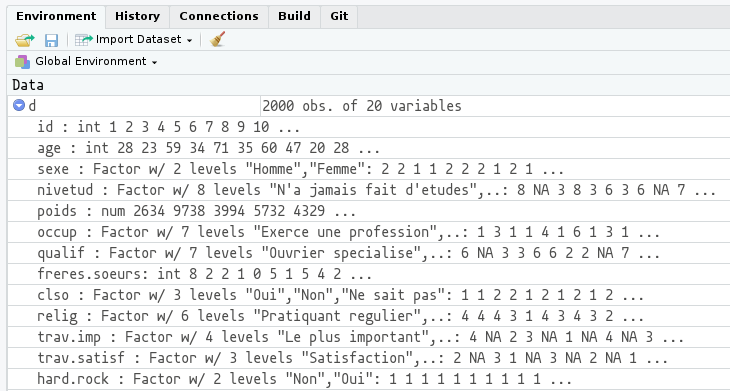

Structure d’un objet

La librairie `dplyr` propose une fonction `glimpse` qui permet de visualiser rapidement et de manière condensée le contenu d’un tableau de données.  
Cette fonction permet de connaître le nombre de lignes et colonnes, le type données dans les colonnes, ainsi que les premières observations.

La fonction `unique` supprime toutes les valeurs en double dans un vecteur, qu’il s’agisse de nombres ou de chaînes de caractères.

La fonction `sort` permet de trier le tableau selon la valeur de l’effectif.

`nrow()` et `ncol()` donnent respectivement le nombre de lignes et de colonnes de la table. On peut aussi obtenir les deux informations en une seule instruction avec `dim()`.

La fonction `summary` génère des statistiques résumant les données contenues dans les colonnes. Elle est souvent utilisée pour les variables numériques, mais elle peut aussi être utilisée pour les variables catégorielles. Pour les colonnes numériques, on a accès à des informations clés sur la distribution : minimum/maximum, quartiles, médiane et moyenne. Cela permet de contrôler les ordres de grandeur et la cohérence des informations. La fonction `summary` fournit le nombre de valeurs manquantes s’il y en a.

Pour les colonnes texte, la fonction `table` permet de récupérer le nombre d’occurrences de chaque valeur distincte.

```r
library(dplyr) # pour glimpse
library(labelled) # pour look_for
library(questionr) # pour describe
library(fs) # pour path

# noms des variables
names(exploit_2020)

# liste des variables séparées par une virgule
paste0(names(exploit_2020), collapse = ",")

# liste des variables séparées par une virgule (et un espace)
paste0(names(exploit_2020), collapse = ", ")

# nom, type et extrait des variables
str(exploit_2020)
str(exploit_2020, list.len = Inf)

glimpse(exploit_2020)
look_for(exploit_2020)
describe(exploit_2020)

# modalités d'une variable caractère ou numérique
unique(exploit_2020$siege_dep)

# modalités triées d'une variable caractère ou numérique
sort(unique(exploit_2020$siege_dep))

# modalités d'une variable séparées par une virgule
paste0(unique(exploit_2020$siege_dep), collapse = ",")

# modalités d'une variable (entre guillemets) séparées par une virgule
# Lorsqu'on imprime le résultat dans la console, il affiche le caractère d'échappement \ devant "
# pour indiquer que le guillemet fait partie de la chaîne. C’est pourquoi on voit \"NR01\" au lieu de "NR01".
# pour voir le résultat sans le caractère d'échappement \,
#on peut utiliser la fonction cat() pour imprimer le résultat.
cat(paste0(unique(eff_volailles_2000_2010$dep), collapse = '","'))

# modalités d'un facteur
levels(exploit_2020$siege_reg)

# 6 premières lignes
head(volailles_pdl)
# Les 4 premières lignes du data.frame
head(volailles_pdl, 4)

# 6 dernières lignes
tail(volailles_pdl)

# Nombre d'observations
nrow(volailles_pdl)
# Nombre de variables
ncol(volailles_pdl)
# Nombre d'observations et de variables (nombre de lignes et de colonnes)
dim(volailles_pdl)

# Description des variables avec des statistiques descriptives
summary(volailles_pdl)

# Fréquence des modalités d'une variable
# Nombre d'occurences des valeurs uniques dans la colonne dep
table(volailles_pdl$dep) |>
  sort(decreasing = TRUE) # tri décroissant

# Valeurs manquantes
# On retourne toutes les lignes du dataframe qui contiennent au moins une valeur manquante (NA)
# dans n'importe quelle colonne.
# La commande filtre les lignes avec au moins une valeur NA
# if_any() # Si au moins une colonne..
volailles_pdl  |>
 filter(if_any(everything(), is.na))
```

`Afficher les valeurs et manipuler les variables`

- Pour afficher la table, plusieurs façons : “clic” dans l’environnement Rstudio, `View(base)`, `print(base)`, `base`.
- Pour accéder à une variable : fonction `pull()`

Par exemple :

```r
str(pull(base, DEP))
```

## 4.2 Création de variables

On assigne un contenu à une variable au moyen de `<-`  
La flèche d’assignation peut être écrite avec le raccourci clavier alt + “-” (tiret du 6 ou signe `moins`du pavé numérique).

ATTENTION : un nom de variable ne peut pas commencer par un chiffre.

```r
ma_variable <- 2
ma_variable <- "Toulouse"
ma_variable <- c("Toulouse", "Nantes", "Strasbourg")
ma_variable <- 1:10
```

`paste0()` pour concaténer des variables `separate()` pour séparer des variables

On souhaite créer de nouvelles variables

### 4.2.1 `mutate()` pour ajouter et modifier des variables

La fonction `mutate()` permet de créer/modifier une variable (ou plusieurs).

```r
table_sortie <- mutate(table_entree,
                        nouvelle_variable = definition_variable)

# Par exemple pour créer une variable :
base <- mutate(base,
               log_SUPERF = log(SUPERF),
               code_prelevement_caract = as.character(code_prelevement))
```

La fonction `mutate()` permet également de modifier une variable. Dans ce cas la syntaxe est la même que ci-dessus, mais les noms d’entrée et de sortie sont les mêmes :

```r
library(openxlsx2)
library(janitor) # pour round_half_up

# Par exemple pour modifier une variable existante :
base <- mutate(base,
               log_SUPERF = 100 * log_SUPERF,
               code_prelevement = as.character(code_prelevement))

df <- mutate(df,
             densite = P14_POP / SUPERF,
             tx_natal = 1000 * NAISD15 / P14_POP,
             tx_mort = 1000 * DECESD15 / P14_POP)

# ajout d'une variable avec mutate
agri_bio_vegetal_fr_tab1 <- agri_bio_vegetal_fr |>
  filter(groupe_de_productions %in% c("Toutes productions")) |>
  select(annee, territoire, nombre_de_producteurs,
         surface_bio_et_en_conversion_en_ha, surface_en_conversion_en_ha, surface_bio_en_ha,
         part_bio_de_la_sau_en_percent) |>
  mutate(part_bio_sau_plus_percent = paste0(part_bio_de_la_sau_en_percent," %"))

# ajout d'une variable avec une modalité déterminée
volailles_fr <- read_xlsx(file = path(chemin, fichier),
                          sheet = "res-France") |>
  as_tibble(.name_repair = make_clean_names) |>
  mutate(reg = "France") |>
  select(reg, espece, total_poids)

# ajout d'une variable par calcul
# passage d'ares en hectares
sau_pbs_2010_2020 <- exploit_2010 |>
  mutate(sau_tot = sau / 100, annee = annee_ra_2010)

# calcul solde
oeufs <- oeufs |>
            mutate(solde = Exportation_Nombre - Importation_Nombre)

# on peut préciser l'emplacement de la nouvelle colonne avec .before ou .after
groupe_produits_laitiers_2021_France <- produits_laitiers_2021_2 |>
  group_by(code_produit, libellé_produit) |>
  summarise(production_2020 = round_half_up(sum(finiqte1, na.rm = TRUE), digits = 0),
    production_2021 = round_half_up(sum(finiqte, na.rm = TRUE), digits = 0),
    établissements_2020 = sum(nbfiniqte1, na.rm = TRUE),
    établissements_2021 = sum(nbfiniqte, na.rm = TRUE)) |>
  ungroup() |>
  mutate(territoire = "France", .before = 1)

# lors d'un mutate avec un group_by,
# il est conseillé d'ajouter le suffixe correspondant au nom de variable
# par exemple _reg
# VOLAILLEFIL   Élevez-vous des volailles ?
exploit_dont_volailles_2020 <- exploit_dont_volailles_2020 |>
  mutate(nb_exploit_volailles_France = sum(volaillefil, na.rm = TRUE),
         part_exploit_volailles_France = nb_exploit_volailles_France / n() * 100) |>
  group_by(reg) |>
  mutate(nb_exploit_volailles_reg = sum(volaillefil, na.rm = TRUE),
         part_exploit_volailles_reg = nb_exploit_volailles_reg / n() * 100) |>
  ungroup()

nb_exploit_dont_volailles_2020 <- exploit_dont_volailles_2020 |>
  distinct(reg, nb_exploit_volailles_France, part_exploit_volailles_France,
           nb_exploit_volailles_reg, part_exploit_volailles_reg)

nb_exploit_dont_volailles_2020_pdl <- exploit_dont_volailles_2020 |>
  filter(reg == "52") |>
  group_by(dep) |>
  mutate(nb_exploit_volailles_dep = sum(volaillefil, na.rm = TRUE),
         part_exploit_volailles_dep = nb_exploit_volailles_dep / n() * 100) |>
  ungroup()

# ajout niveau dep, reg et fm
recolte_bois_dep_reg <- recolte_bois_depart |>
  group_by(categorie) |>
  mutate(valeur_fm = sum(valeur)) |>
  ungroup() |>
  group_by(reg,categorie) |>
  mutate(valeur_reg = sum(valeur)) |>
  ungroup() |>
  rename(valeur_dep = valeur) |>
  select(dep, reg, categorie,
         valeur_fm,
         valeur_reg,
         valeur_dep,
         libdep, libreg)

# nombre des exploitants par groupe
repart_diplome_max_groupe1 <-  mo_2020_diplome_max |>
  mutate(n_tot = n()) |>
  group_by(dipl_max_groupe1) |>
  summarise(nb = n(), percent = n() / n_tot * 100) |>
  ungroup() |>
  distinct() |>
  adorn_totals("row", name = "Ensemble")

# utilisation de la fonction last, qui permet de récupérer la valeur de la dernière ligne
# à manier avec précaution (ne pas modifier l'ordre au préalable par exemple)
exploit_otex_dep_reg_fm <- exploit_otex_pdl |>
  left_join(exploit_otex_dep,
            join_by(otex_regroup) |>
  adorn_totals(where = "row",
               name = "Ensemble") |>
  mutate(a01_part_otex_fm = a01_n_exploit_fm / last(a01_n_exploit_fm) * 100,
         b02_part_otex_reg = b02_n_exploit_reg / last(b02_n_exploit_reg) * 100,
         c03_part_otex_85 = dep_85 / last(dep_85) * 100,
         d04_part_otex_72 = dep_72 / last(dep_72) * 100,
         e05_part_otex_53 = dep_53 / last(dep_53) * 100,
         f06_part_otex_49 = dep_49 / last(dep_49) * 100,
         g07_part_otex_44 = dep_44 / last(dep_44) * 100) |>
  mutate(across(contains("part"), \(x) round_half_up(x, digits = 3)))

# sau irriguées
exploit_anim_produit_grand_pdl <- exploit_anim_produit_grand_pdl |>
  group_by(seuil_produit) |>
  mutate(indic_10_sau_reg = sum(sau_tot),
         sau2_reg = sum(rowSums(across(contains("cultsur")))),
         sau3_reg = sum(across(contains("cultsur"))),
         indic_11_sau_irrig_reg = sum(across(contains("irrisur"))),
         .after=nom_dossier) |>
  ungroup()
```

**La fonction `mutate()` permet de créer de nouvelles colonnes ou de modifier des colonnes existantes.** Il est possible d’utiliser toutes sortes de fonctions à l’intérieur d’une étape `mutate()`. Le code suivant crée une variable `NB_EQUIP_3PLUS` qui vaut `TRUE` si le nombre d’équipement est supérieur ou égal à 3, et `FALSE` sinon.

```r
bpe_ens_2018_tbl |>
  mutate(NB_EQUIP_3PLUS = (NB_EQUIP >= 3))
```

Pour créer une nouvelle variable, on utilise un nom de variable qui n’existe pas encore dans la table. Pour modifier une variable qui existe déjà, on utilise directement le nom de cette variable.

On peut créer plusieurs nouvelles colonnes en une seule commande, et les expressions successives peuvent prendre en compte les résultats des calculs précédents. L’exemple suivant convertit d’abord la durée en heures dans une variable `duree_h` et la distance en kilomètres dans une variable `distance_km`, puis utilise ces nouvelles colonnes pour calculer la vitesse en km/h.

```r
flights <- mutate(
    flights,
    duree_h = air_time / 60,
    distance_km = distance / 0.62137,
    vitesse = distance_km / duree_h)

select(flights, air_time, duree_h, distance, distance_km, vitesse)
```

Voici quelques utilisations fréquentes de `mutate()` :

| Action | Code |
| --- | --- |
| Calculer une somme cumulée | `mutate(NB_EQUIP_CUM = cumsum(NB_EQUIP, na.rm = TRUE))` |
| Calculer un total | `mutate(NB_EQUIP_TOT = sum(NB_EQUIP, na.rm = TRUE))` |
| Sommer deux variables | `mutate(NB_EQUIP_DOUBLE = NB_EQUIP + NB_EQUIP)` |
| Extraire une sous-chaine de caractères | `mutate(CATEGORIE_EQ = str_sub(TYPEQU, 1L, 1L))` |

```r
# Calcul du nb d'exploitations ayant des bovins
exploit_prod_anim_pdl <- exploit_prod_anim_pdl |>
  mutate(n_exploit_ayant_bovins = sum(cheptq_110000 > 0, na.rm = TRUE),
         n_exploit_ayant_vaches = sum(cheptq_111000 > 0, na.rm = TRUE),
         n_exploit_ayant_gros_bovins = sum(gros_bovins > 0, na.rm = TRUE),
         n_exploit_ayant_veaux = sum(veaux > 0, na.rm = TRUE),
         n_exploit_ayant_veaux_25min = sum(veaux >= 25, na.rm = TRUE),
         .after = nom_dossier)
```

```r
# Pour s'assurer que benef_p2 vaut 1 si au moins une des conditions est vraie,
# on utilise une condition logique combinée avec | (ou logique)
# et on convertit le résultat en numérique (TRUE devient 1)
# pour obtenir 1 si au moins une des conditions est vraie, sinon 0.
beneficiaires_pdl_2020 <- beneficiaires_2020 |>
  filter(nreg == "52") |>
  mutate(
    benef_p2 = as.numeric((benef_bio_maec > 0) |
                            (benef_ichn_aras > 0)),
    benef_p1_p2 = as.numeric((benef_p1 > 0) |
                               (benef_bio_maec > 0) |
                               (benef_ichn_aras > 0)),
    .after = benef_p1) |>
  group_by(dep) |>
  mutate(
    nb_beneficiaires_p1_dep = sum(benef_p1, na.rm = TRUE),
    nb_beneficiaires_p2_dep = sum(benef_p2, na.rm = TRUE),
    nb_beneficiaires_p1_p2_dep = sum(benef_p1_p2, na.rm = TRUE),
    .after = benef_p1_p2) |>
  ungroup() |>
  mutate(
    nb_beneficiaires_p1_reg = sum(benef_p1, na.rm = TRUE),
    nb_beneficiaires_p2_reg = sum(benef_p2, na.rm = TRUE),
    nb_beneficiaires_p1_p2_reg = sum(benef_p1_p2, na.rm = TRUE),
    .after = benef_p1_p2)
```

#### 4.2.1.1 L’argument `.keep`

L’argument `.keep` dans `mutate()` permet de contrôler quelles colonnes du dataframe d’origine sont conservées dans le résultat.

L’argument `.keep` donne un contrôle fin sur les colonnes qui doivent être conservées après l’opération `mutate()`. Il peut prendre plusieurs valeurs :  
`all` (par défaut) : Conserve toutes les colonnes originales + les nouvelles.  
`used` : Conserve les colonnes qui ont été utilisées pour créer les nouvelles colonnes + les nouvelles.  
`unused` : Conserve les colonnes qui n’ont pas été utilisées pour créer les nouvelles colonnes + les nouvelles.  
`none` : Ne conserve aucune des colonnes originales, seulement les nouvelles.

Le paramètre `.keep = "none"` indique à `mutate()` de supprimer toutes les colonnes existantes sauf celles explicitement mentionnées. On ne conserve que les nouvelles colonnes qu’on vient de créer. Toutes les colonnes qui existaient déjà dans le tableau de données sont supprimées.

```r
# Données d'exemple
ventes <- tibble(
  produit = c("A", "B", "C"),
  prix = c(10, 15, 20),
  quantite = c(5, 3, 8),
  region = c("Nord", "Sud", "Est"))

# Calcul avec .keep = "none"
ventes |>
  mutate(
    chiffre_affaires = prix * quantite,
    profit = chiffre_affaires * 0.2,
    .keep = "none")
# Résultat : seulement chiffre_affaires et profit

# Comparé à .keep = "all" (défaut)
ventes |>
  mutate(
    chiffre_affaires = prix * quantite,
    profit = chiffre_affaires * 0.2)
# Résultat : produit, prix, quantite, region, chiffre_affaires, profit
```

```r
# calcul des ratios import / export par secteur ----
# Ajouter une ligne part export/import pour chaque secteur
# On considère le ratio non pas comme une variable, mais comme une nouvelle observation.
# Créer une nouvelle ligne avec le rapport export/import pour les secteurs AZ et C1
ratios_az_c1 <- produits_long_az_c1_det_reg |>
   # Filtrer pour garder seulement export et import (pas solde)
   filter(flux %in% c("export", "import")) |>
   # Pivoter pour avoir export et import en colonnes
   pivot_wider(
      id_cols = a_17,
      names_from = flux,
      values_from = starts_with("an_")
      # values_from = c(
      #    an_2021_sem1, an_2021_sem2, an_2022_sem1, an_2022_sem2,
      #    an_2023_sem1, an_2023_sem2, an_2024_sem1, an_2024_sem2,
      #    an_2025_sem1)
   )

# Calculer les deux ratios (export/import et import/export) pour chaque période
# Le paramètre .keep = "none" indique à mutate() de supprimer toutes les colonnes existantes
# sauf celles explicitement mentionnées
# On ne conserve que les nouvelles colonnes qu'on vient de créer.
# Toutes les colonnes qui existaient déjà dans le tableau de données sont supprimées.
ratios_export_sur_import <- ratios_az_c1 |>
   mutate(
      a_17 = a_17,
      flux = "export_sur_import",
      an_2021_sem1 = an_2021_sem1_export / an_2021_sem1_import * 100,
      an_2021_sem2 = an_2021_sem2_export / an_2021_sem2_import * 100,
      an_2022_sem1 = an_2022_sem1_export / an_2022_sem1_import * 100,
      an_2022_sem2 = an_2022_sem2_export / an_2022_sem2_import * 100,
      an_2023_sem1 = an_2023_sem1_export / an_2023_sem1_import * 100,
      an_2023_sem2 = an_2023_sem2_export / an_2023_sem2_import * 100,
      an_2024_sem1 = an_2024_sem1_export / an_2024_sem1_import * 100,
      an_2024_sem2 = an_2024_sem2_export / an_2024_sem2_import * 100,
      an_2025_sem1 = an_2025_sem1_export / an_2025_sem1_import * 100,
      .keep = "none") |>
   # Arrondir les valeurs
   mutate(across(starts_with("an_"), \(x) round_half_up(x, digits = 2)))

ratios_import_sur_export <- ratios_az_c1 |>
   mutate(
      a_17 = a_17,
      flux = "import_sur_export",
      an_2021_sem1 = an_2021_sem1_import / an_2021_sem1_export * 100,
      an_2021_sem2 = an_2021_sem2_import / an_2021_sem2_export * 100,
      an_2022_sem1 = an_2022_sem1_import / an_2022_sem1_export * 100,
      an_2022_sem2 = an_2022_sem2_import / an_2022_sem2_export * 100,
      an_2023_sem1 = an_2023_sem1_import / an_2023_sem1_export * 100,
      an_2023_sem2 = an_2023_sem2_import / an_2023_sem2_export * 100,
      an_2024_sem1 = an_2024_sem1_import / an_2024_sem1_export * 100,
      an_2024_sem2 = an_2024_sem2_import / an_2024_sem2_export * 100,
      an_2025_sem1 = an_2025_sem1_import / an_2025_sem1_export * 100,
      .keep = "none") |>
   mutate(across(starts_with("an_"), \(x) round_half_up(x, digits = 2)))

# Ajouter ces deux types de ratios au tableau original
produits_az_c1_reg_ratios_imp_exp <- bind_rows(
   produits_long_az_c1_det_reg,
   ratios_export_sur_import,
   ratios_import_sur_export)
```

### 4.2.2 `separate` : scinder une colonne en plusieurs

La fonction `separate` est utile lorsque nous avons une seule colonne contenant des valeurs composées que nous souhaitons diviser en plusieurs colonnes distinctes. Elle prend trois arguments principaux :

- le nom de la colonne à scinder ;
- un vecteur indiquant les noms des nouvelles variables à créer ;
- le séparateur `sep` indique à quel endroit la variable doit être scindée. Par défaut `separate` scinde au niveau des caractères non-alphanumérique (espace, symbole, etc.). Si l’on indique un nombre entier `n`, alors la colonne est scindée après le n-ième caractère.

Voici un exemple qui utilise la table des communes du Code Officiel Géographique. Dans cette table, la colonne `com` (code commune Insee) contient deux informations : le numéro du département et le numéro de la commune.

```r
cog_com_2019_tbl <- doremifasolData::cog_com_2019 |> as_tibble()
cog_com_2019_tbl
```

Voici comment on peut utiliser `separate` pour scinder `com` en deux nouvelles colonnes `code_dep` et `code_com`. La colonne `com` disparait, car par défaut `separate` supprime la colonne scindée. Si on souhaite la conserver, il faut ajouter l’option `remove = FALSE`.

```r
library(dplyr)
library(tidyr)

cog_com_2019_tbl |>
  separate(com, c("code_dep", "code_com"), sep = 2)

# séparation d'une variable date ("22-09-2022") en "jour","mois","annee"
oeufs_cot_det <- oeufs_cot_det |>
  separate(DATE,sep="-", into = c("jour","mois","annee"))

# on divise les noms de colonnes en "indicateur" et "territoire"
# on transpose le niveau dep en colonnes
agreg_anim_produit_grand_dep_reg <- agreg_anim_produit_grand_dep_pdl_long |>
  separate(indicateur_territoire, into = c("indicateur", "territoire"), sep = "_dep_") |>
  arrange(territoire) |>
  pivot_wider(names_from = territoire,
              values_from = donnees_territoire) |>
  arrange(indicateur)
```

### 4.2.3 `unite` : regrouper plusieurs colonnes en une seule

La fonction `unite` permet est de réaliser l’opération inverse de `separate` : regrouper plusieurs colonnes en une seule. Elle prend trois arguments principaux :

- le nom de la colonne à créer ;
- un vecteur indiquant les noms des variables à regrouper ;
- le séparateur `sep` qui indique quel séparateur doit être introduit entre les variables regroupées (par défaut, `unite` utilise le caractère `_`).

Voici un exemple où l’on regroupe le code commune Insee et le nom officiel de la commune, avec ” - ” comme séparateur. Les colonnes `com` et `ncc` disparaissent, car par défaut `unite` supprime les colonnes regroupées. Si on souhaite les conserver, il faut ajouter l’option `remove = FALSE`.

```r
cog_com_2019_tbl |>
  unite(code_et_nom, c("com", "ncc"), sep = " - ")
```

On souhaite reconstruire une colonne `code_insee` qui indique le code Insee de la commune, et qui s’obtient en concaténant le code du département et celui de la commune.

```r
df |>
  unite(
      code_insee,
      code_departement, code_commune,
      sep = "",
      remove = FALSE
  )
```

### 4.2.4 Ajout d’une colonne “numéro de ligne”

row.names

```r
library(openxlsx2)

# ajout colonne numéro de ligne
# creation d'une variable identifiant reprenant le numéro de ligne
produits_laitiers <- read_xlsx(file = path(chemin_entree, fichier_entree),
                               sheet = "produits laitiers",
                               start_row = 12) |>
  as_tibble(.name_repair = make_clean_names)

produits_laitiers <- produits_laitiers |>
  mutate(ident = row.names(produits_laitiers), .before = 1)

# filtre en fonction du numéro de ligne
# avec l'identifiant “numéro de ligne”
# Ajout d’une colonne “numéro de ligne”
# creation d'une variable identifiant reprenant le numéro de ligne
vab_agri_2020_2 <- vab_agri_2020 |>
  mutate(ident = row.names(vab_agri_2020), .before = 1) |>
  filter(ident %in% 1:15) |>
  mutate(total = as.numeric(total)) |>
  left_join(geographie_reg,
            join_by(libreg))
```

## 4.3 Sélectionner des variables

La fonction `select()` permet de sélectionner les variables voulues par leur nom.

- sélection par liste blanche

```r
table_sortie <- select(table_entree, variable1, variable2, ..., variableN)
```

- sélection par liste noire (supprimer). Si on fait précéder le nom d’un `-`, la colonne est éliminée plutôt que sélectionnée.

```r
table_sortie <- select(table_entree, -variable1, -variable2, ..., -variableN)
```

Par exemple :

```r
base_select <- select(base, codgeo, libgeo, p14_pop)
base_select <- select(base, -codgeo)
```

```r
agri_bio_vegetal_tab1_final <- agri_bio_vegetal_tab1_final |>
  select(c("annee", "vegetal", "Loire-Atlantique", "Maine-et-Loire", "Mayenne", "Sarthe", "Vendée",
           "Pays de la Loire", "National"))

agri_bio_vegetal_fr_tab1 <- agri_bio_vegetal_fr |>
  filter(groupe_de_productions %in% c("Toutes productions")) |>
  select(annee, territoire, nombre_de_producteurs,
         surface_bio_et_en_conversion_en_ha, surface_en_conversion_en_ha, surface_bio_en_ha,
         part_bio_de_la_sau_en_percent) |>
  mutate(part_bio_sau_plus_percent = path(part_bio_de_la_sau_en_percent, " %"))
```

Une sélection négative est aussi possible avec ‘select(-variable_a_enlever)’.

```r
# on supprime la 1re colonne
eff_bovins_2024 <- eff_bovins_2024 |>
  as_tibble(.name_repair = make_clean_names) |>
  select(-1)

# on supprime la dernière colonne
test <- eff_bovins_2024 |>
  select(-last_col())

# conversion en caractère
# Quand on passe une fonction comme argument à une autre fonction, on utilise la notation sans les parenthèses.
agri_bio_vegetal_fr_tab1_car <- agri_bio_vegetal_fr_tab1 |>
  mutate(across(c(nombre_de_producteurs, surface_bio_et_en_conversion_en_ha,
                  surface_en_conversion_en_ha, surface_bio_en_ha,
                  part_bio_de_la_sau_en_percent),
                as.character)) |>
  select(-part_bio_de_la_sau_en_percent)
```

`select()` possède ce qu’on appelle des [helpers](https://dplyr.tidyverse.org/reference/select.html) qui permettent de gagner du temps dans l’écriture d’une sélection.

Exemple : sélectionner toutes les variables qui commencent par “code_” :

```r
prelevementb <- select(prelevement, starts_with("code_"))
```

Exemple : enlever de la sélection les variables dont les noms contiennent “type_reg” :

```r
# A partir du tableau transposé, ajout du total régional
bio_pdl_animaux_large_2 <- bio_pdl_animaux_large |>
  adorn_totals(where = "row", name = "Pays de la Loire") |>
  select(-contains("type_reg"))
```

Exemple : sélectionner les variables dont les noms sont contenus dans un vecteur de chaînes de caractères :

```r
mes_variables <- c("code_prelevement", "code_intervenant", "code_reseau", "date_prelevement")
prelevementb <- select(prelevement, one_of(mes_variables))
```

**La fonction `select()` permet de sélectionner des variables par leur nom, ou par une condition sur leur nom.**

- Avec une liste de noms de variables. Le code suivant sélectionne le code commune, le type d’équipement et le nombre d’équipement dans la base permanente des équipements :

```r
  bpe_ens_2018_tbl |>
    select(depcom, typequ, nb_equip)
```

- Avec une condition logique. par exemple, la fonction `starts_with("dep")` permet de sélectionner toutes les variables dont le nom commence par “dep”.

```r
  bpe_ens_2018_tbl |>
    select(starts_with("dep"))

bio_pdl_dep_ab <- bio_pdl_dep_large2 |>
  select(dep,c(contains("ab_")))
```

Le tableau suivant donne la liste des conditions utilisables avec `select()` :

| Fonction | Signification |
| --- | --- |
| `select(c())` | les colonnes citées dans le vecteur |
| `select(starts_with("...")` | dont le nom commence par “…” |
| `select(ends_with("...")` | dont le nom se termine par “…” |
| `select(contains("...")` | dont le nom contient “…” |
| `select(matches("...")` | vérifie une expression régulière |
| `select(colonne1:colonne2)` | une étendue de colonnes dans la table |
| `select(where())` | les colonnes vérifiant une condition |
| `select(all_of(...))` | sélectionne les colonnes listées dans un vecteur en paramètre (absolument) |
| `select(any_of(...))` | identique à `all_of()`, mais éventuellement (sans erreur si la colonne n’existe pas) |
| `select(everything())` | toutes les colonnes (utile pour mettre une nouvelle colonne devant les autres) |

La syntaxe `colonne1:colonne2` permet de sélectionner toutes les colonnes situées entre `colonne1` et `colonne2` incluses. À noter que cette opération est un peu plus “fragile” que les autres, car si l’ordre des colonnes change elle peut renvoyer un résultat différent.

On peut ainsi indiquer une plage de colonnes (soit par les noms de variables, soit par les numeros de colonne, par exemple ci-après on pourrait indiquer 1:4 au lieu de haircolor:weight)

```r
data <- data  |>
  select(catdata, haircolor:weight)
```

```r
bio_anim_dep_pdl_part_reg_export <- bio_anim2_dep_pdl_an |>
  filter(echelle_geographique == "Département") |>
  select(
    echelle_geographique, territoire, type_de_production, groupe_de_productions,
    rang_nb_tetes_2023,
    rang_nombre_deleveurs_2023,
    rang_part_du_bio_en_percent_2023,
    ends_with("part_reg"),
    starts_with("part_du_bio")
  )

bio_anim_nb_tetes_dep_pdl_part_reg <- bio_anim_dep_pdl_part_reg_export |>
  select(
    echelle_geographique, territoire, type_de_production, groupe_de_productions,
    rang_nb_tetes_2023,
    starts_with("nb_tetes_")
  ) |>
  rename_with(
    \(x) str_replace(x, "nb_tetes_", "an_"),
    .cols = starts_with("nb_tetes_")
  ) |>
  mutate(indicateur = "nb_tetes", .after = "groupe_de_productions")
```

- Il est possible de renommer des colonnes directement avec `select`. On l’utilise en lui passant des paramètres de la forme `nouveau_nom = ancien_nom`.

```r
  bpe_ens_2018_tbl |>
    select(dept = dep, depcom)
```

La fonction `everything()` permet de conserver toutes les colonnes. On l’utilisera lorsqu’on spécifie les colonnes dans un ordre souhaité, puis qu’on garde toutes les autres dans leur ordre d’origine. Cela évite de renseigner toutes les colonnes.

```r
# continent en premier puis les autres telles qu'elles existaient
population_monde |>
  select(continent, everything())
```

Attention : si on élimine des colonnes, il faut le faire après la fonction everything(), car sinon, elle remettra les colonnes éliminées.

```r
# pays et pop en premier, toutes les autres ensuite, puis on retire continent et pib_par_habitant
population_monde |>
  select(pays, pop, everything(), -continent, -pib_par_habitant)
```

La fonction `where()`, combinée avec le verbe `select()`, permet de sélectionner une colonne selon un “prédicat”, c’est-à-dire un test. Dans l’exemple ci-dessous, on n’affiche que les colonnes dont le format est de type numérique (à l’aide de la fonction `is.numeric()` qui teste justement ce type-là). L’expression est simplifiée en n’utilisant pas les parenthèses de `is.numeric()`.

```r
# selection des colonnes de type numérique
population_monde |>
  select(where(is.numeric))
```

Une autre syntaxe consiste à écrire les tests comme une fonction, après le symbole (x). La variable x correspond à ce qui est à gauche du “pipe”.  
On peut rajouter des conditions à l’aide des opérateurs booléens doublés && et || qui correspondent au ET et OU pour des colonnes entières.

```r
# on selectionne les colonnes de type numérique et dont la moyenne est inférieure à 60
population_monde |>
  select(where(\(x) is.numeric(x) && mean(x, na.rm = TRUE) < 60))
```

https://tidyselect.r-lib.org/reference/language.html

## 4.4 Renommer des colonnes (variables)

La fonction `rename()` permet de renommer une variable (ou plusieurs).

```r
base <- rename(base, nouveau_nom = ancien_nom)

# Exemple
base_rename <- rename(base, ZONE_EMPLOI = ZE)

# renommage 2 lignes intitulés
volailles_pdl_siqo2 <- volailles_pdl_siqo |>
  rename(espece_poulets_coquelets_siqo_label_rouge = label_rouge_2,
         espece_poulets_coquelets_siqo_aoc_aop = aoc_aop_3,
         espece_poulets_coquelets_siqo_agri_bio = agri_bio_4,
         espece_poulets_coquelets_siqo_aut_signe_off = aut_signe_off_5)
```

La syntaxe est la suivante : `rename(data, nouveau_nom = ancien nom)`. Voici un exemple :

```r
bpe_ens_2018_tbl |>
  rename(code_commune = DEPCOM)
```

Si les noms de colonnes comportent des espaces ou des caractères spéciaux, on peut les entourer de guillemets (`"`) ou d’apostrophes (quotes) inverses (`` ` ``) :

```r
tmp <- rename(
    flights,
    "retard départ" = dep_delay,
    "retard arrivée" = arr_delay)

select(tmp, `retard départ`, `retard arrivée`)
```

La fonction `rename_with()` permet de renommer un groupe de colonnes avec une fonction.  
La syntaxe est la suivante : `rename_with(data, nom_fonction, selection_colonnes)`. Voici un exemple qui met en minuscules tous les noms de colonnes :

```r
bpe_ens_2018_tbl |>
  rename_with(tolower)
```

Par défaut, `rename_with()` applique la fonction de renommage à l’ensemble des colonnes du tableau. Il est cependant possible de lui indiquer de ne renommer que certaines de ces colonnes. Pour cela, on peut lui ajouter un argument supplémentaire nommé `.cols`.

```r
# on renomme _reg en _dep_ensemble
# on renomme toutes les colonnes contenant "_reg" à la fin par "_dep_ensemble"
# ensuite en enlevant le suffixe _dep, il restera 44,49,53,72,85,ensemble
agreg_anim_produit_grand_dep_pdl_b <- agreg_anim_produit_grand_dep_pdl_a |>
  rename_with(
    \(x) str_replace(x, "_reg", "_dep_ensemble"),
    .cols = contains("reg")
  )
```

## 4.5 Conversion d’une variable caractère en numérique

On utilise la fonction `as.numeric`.

```r
agri_bio_vegetal_fr <- agri_bio_vegetal_fr |>
# Quand on passe une fonction comme argument à une autre fonction, on utilise la notation sans les parenthèses.
  mutate(across(c(surface_bio_et_en_conversion_en_ha,
                  surface_en_conversion_en_ha,surface_bio_en_ha,
                  part_bio_de_la_sau_en_percent),
                as.numeric))
```

En cas de lignes vides, cela crée des valeurs NA (not available) et produit un messsage d’avertissement dans la console. C’est un message non bloquant.  
*Warning messages:*  
1: Problem with `mutate()` input `..1`.  
NAs introduits lors de la conversion automatique  
Input `..1` is `across(...)`.

On utilise la fonction `as.numeric`, combinée à `across` pour l’appliquer à un ensemble de variables.

```r
library(openxlsx2)

# import fichiers
chemin_entree <- "S:/ETUDES/En cours/memento_Christophe/entree/BAEA/"
fichier_entree <- "baea_diff_2020_reg_52_Pays_de_la_Loire.xlsx"

otex <- read_xlsx(file = path(chemin_entree, fichier_entree),
                  sheet = "ETP - OTEX",
                  start_row = 7) |>
  # Quand on passe une fonction comme argument à une autre fonction, on utilise la notation sans les parenthèses.
  mutate(across(-c("Orientation.technico-économique.(OTEX)"), as.numeric)) |>
  rename(otex_lib = "Orientation.technico-économique.(OTEX)") |>
  mutate(otex_code = substr(otex_lib,1,4))

# Pourcentage en colonne
produits_a17_percent <- produits_a17_large |>
   mutate(an_2021_imports_percent_col = an_2021_imports / sum(an_2021_imports) * 100,
          an_2022_imports_percent_col = an_2022_imports / sum(an_2022_imports) * 100,
          an_2021_exports_percent_col = an_2021_exports / sum(an_2021_exports) * 100,
          an_2022_exports_percent_col = an_2022_exports / sum(an_2022_exports) * 100,
          an_2021_I_sem1_percent_col = an_2021_I_sem1 / sum(an_2021_I_sem1) * 100,
          an_2021_I_sem2_percent_col = an_2021_I_sem2 / sum(an_2021_I_sem2) * 100,
          an_2022_I_sem1_percent_col = an_2022_I_sem1 / sum(an_2022_I_sem1) * 100,
          an_2022_I_sem2_percent_col = an_2022_I_sem2 / sum(an_2022_I_sem2) * 100,
          an_2021_E_sem1_percent_col = an_2021_E_sem1 / sum(an_2021_E_sem1) * 100,
          an_2021_E_sem2_percent_col = an_2021_E_sem2 / sum(an_2021_E_sem2) * 100,
          an_2022_E_sem1_percent_col = an_2022_E_sem1 / sum(an_2022_E_sem1) * 100,
          an_2022_E_sem2_percent_col = an_2022_E_sem2 / sum(an_2022_E_sem2) * 100,
          .after=a17_lib_detail) |>
   mutate(across(where(is.numeric), \(x) round_half_up(x, digits = 3)))

# type.convert pour transformer en numérique poids_produit_en_tec (caractère)
# qui a comme séparateur décimal ","
viande_volaille_tec_2021 <- read_xlsx(file = path(chemin, fichier_saa),
                                      sheet = "Volailles finies produites") |>
  as_tibble(.name_repair = make_clean_names) |>
  filter(region %in% c("52  -  Pays de la Loire",
                       "98  -  Total France métropolitaine")) |>
  mutate(an_2021 = type.convert(poids_produit_en_tec, dec = ","),
         reg = case_when(
           region %in% c("52  -  Pays de la Loire") ~ "pdl",
           region %in% c("98  -  Total France métropolitaine") ~ "fm")) |>
  select(c(reg, libelle_culture, an_2021))
```

```r
library(stringr)

# Convertir les colonnes commençant par "surf" en numérique
bio_producteurs_vege_pdl <- bio_producteurs_vege_pdl |>
  select(ident, dep, numerobio, numeroclientoc,
    libellegroupe, libellessgroupe, production,
    surfab, surfc1, surfc2, surfc3, surfc123, surfbiototale) |>
  # Convertir en numérique avec un séparateur décimal spécifique (",")
  # Remplacer la virgule par un point avant de faire la conversion en numérique
    mutate(across(starts_with("surf"), \(x) str_replace(x, ",", "."))) |>
    mutate(across(starts_with("surf"), as.numeric))
  # Avec type.convert
  # mutate(across(starts_with("surf"), \(x) type.convert(x, dec = ",")))
```

## 4.6 Conversion d’une variable numérique en caractère

On utilise la fonction `as.character`.

```r
library(janitor) # pour round_half_up

# conversion en caractère
# Quand on passe une fonction comme argument à une autre fonction, on utilise la notation sans les parenthèses.
agri_bio_vegetal_fr_tab1_car <- agri_bio_vegetal_fr_tab1 |>
  mutate(across(c(nombre_de_producteurs,surface_bio_et_en_conversion_en_ha,
                  surface_en_conversion_en_ha,surface_bio_en_ha,
                  part_bio_de_la_sau_en_percent), as.character)) |>
  select(-part_bio_de_la_sau_en_percent)
```

## 4.7 Recodification de variables

Parfois, on veut créer une nouvelle variable en partant des valeurs d’une ou plusieurs autres variables.

### 4.7.1 avec `case_match()`

La fonction `case_match()` permet de recoder les valeurs d’une variable en fonction de correspondances exactes ou de conditions.  
Il faut utiliser `~` (AltGr + 2) pour associer les valeurs de correspondance avec leurs résultats.  
Pour mettre une valeur par défaut, on utilise l’argument de la fonction `.default =`. Le .default est un paramètre nommé de la fonction. Comme pour tout argument, on l’assigne avec = (par exemple, .default = “Autre”).

```r
library(dplyr)

# valeur_originale ~ nouvelle_valeur signifie :
# Si la valeur est valeur_originale, la remplacer par nouvelle_valeur.

data <- data |>
  mutate(nouvelle_variable = case_match(
    ancienne_variable,
    valeur1 ~ nouvelle_valeur1,
    valeur2 ~ nouvelle_valeur2,
    .default = valeur_defaut # (optionnel) valeur par défaut si aucune correspondance
  ))

# ajout date en nombre
lait_chevre3 <- lait_chevre2  |>
  mutate(code_mois = case_match(mois,
                          "Janvier" ~ "01",
                          "Février" ~ "02",
                          "Mars" ~ "03",
                          "Avril" ~ "04",
                          "Mai" ~ "05",
                          "Juin" ~ "06",
                          "Juillet" ~ "07",
                          "Août" ~ "08",
                          "Septembre" ~ "09",
                          "Octobre" ~ "10",
                          "Novembre" ~ "11",
                          "Décembre" ~ "12"))

# ajout date en lettres
laits_mensuel_chevre_2 <- laits_mensuel_chevre_1  |>
  mutate(mois = case_match(code_mois,
                          "01" ~ "Janvier",
                          "02" ~ "Février",
                          "03" ~ "Mars",
                          "04" ~ "Avril",
                          "05" ~ "Mai",
                          "06" ~ "Juin",
                          "07" ~ "Juillet",
                          "08" ~ "Août",
                          "09" ~ "Septembre",
                          "10" ~ "Octobre",
                          "11" ~ "Novembre",
                          "12" ~ "Décembre"))

# otex en clair
exploit_vaches_otex_clair <- exploit_vaches_otex |>
  mutate(otex_libelle = case_match(otefda_coef17,
      "1516" ~ "Grandes cultures",
      "2829" ~ "Maraîchage, horticulture",
      "3500" ~ "Viticulture",
      "3900" ~ "Fruits ou autres cultures permanentes",
      "4500" ~ "Bovins lait",
      "4600" ~ "Bovins viande",
      "4700" ~ "Bovins mixte",
      "4800" ~ "Ovins, caprins, autres herbivores",
      "5074" ~ "Porcs, volailles",
      "6184" ~ "Polyculture, polyélevage",
      "9000" ~ "Exploitations non classées",
      .default = "autre"))
```

```r
# Calculer par département et statut
# le nombre d’exploitations ayant des vaches,
# l’effectif de vaches et la pbs
exploit_vaches_statut <- exploit_bovins_c |>
  filter(cheptq_111000 > 0) |>
  mutate(statut_libelle = case_match(statut,
                            "01" ~ "1 - Exploitant individuel",
                            "02" ~ "2 - GAEC",
                            "03" ~ "3 - EARL",
                            .default = "4 - Autres statuts"))

nb_exploit_vaches_statut <- exploit_vaches_statut |>
  group_by(siege_dep, statut_libelle) |>
  summarise(nb_expl = n(),
            vaches = sum(cheptq_111000),
            pbs = sum(pbstot_coef17)) |>
  ungroup() |>
  arrange(siege_dep)
```

```r
# Utilisation de la fonction case_match pour renommer les modalités

viande_volaille_avant_2010_4 <- viande_volaille_avant_2010_4 |>
  mutate(type_grandeur = case_match(
    type_grandeur,
    "Poids produit (tonne équivalent carcasse)" ~ "prod",
    "Production totale (1000 têtes)" ~ "nbtete"
  ))
```

```r
# Recodage selon des intervalles
ages <- c(10, 20, 30, 40, 50, 60)

age_groupes <- case_match(
  ages,
  1:17 ~ "Enfant/Adolescent",
  18:39 ~ "Jeune adulte",
  40:59 ~ "Adulte",
  .default = "Senior")

print(age_groupes)

data <- data |>
  mutate(categorie = case_match(
    ages,
    ages < 18 ~ "mineur",
    ages >= 18 & age < 65 ~ "adulte",
    ages >= 65 ~ "senior"))
```

### 4.7.2 avec `if_else()`

`if_else` de `dplyr` prend trois arguments : un test, une valeur à renvoyer si le test est vrai, et une valeur à renvoyer si le test est faux.

Avec `if_else` :  
`variable = if_else(condition(x), valeur_si_oui, valeur_si_non)` permet d’affecter *valeur_si_oui* ou *valeur_si_non* à *variable* en fonction du fait que *x* répond à *condition*.  
Exemple : création d’une variable résultat pour savoir si les résultats de nos analyses sont bons, ou non.

```r
analyseb <- mutate(analyse, resultat_ok = if_else(code_remarque %in% c(1, 2, 7, 10),
                                                 true = TRUE, false = FALSE))
```

qui peut se résumer, lorsque `true = TRUE` et `false = FALSE`, à :

```r
analyseb <- mutate(analyse, resultat_ok = code_remarque %in% c(1, 2, 7, 10))
```

```r
laits_mensuel_chevre_cerise <- laits_mensuel_2 |>
  filter(type %in% c("CNB","CB")) |>
  mutate(reg_etab = if_else(dep_etab %in% c("44", "49", "53", "72", "85"),
                           true = "PDL", false = "hors PDL"),
         reg_prod = if_else(dep_prod %in% c("44", "49", "53", "72", "85"),
                           true = "PDL", false = "hors PDL"))
```

La fonction permet d’utiliser des tests combinant plusieurs variables. Par exemple, imaginons qu’on souhaite créer une nouvelle variable indiquant les hommes de plus de 60 ans :

```r
hdv2003$statut <- if_else(
    hdv2003$sexe == "Homme" & hdv2003$age > 60,
    "Homme de plus de 60 ans",
    "Autre"
)
```

On peut créer une nouvelle variable, commençant par un caractère commun à plusieurs modalités, avec ‘startsWith’

```r
# Filtrer les enregistrements concernant les pommes
bio_pdl_pommes_yc_terre <- bio_pdl |>
  mutate(libelle_ab_2 = if_else(startsWith(libelleonab, "Pomme"), "Pommes", "hors_pommes")) |>
  filter(libelle_ab_2 %in% c("Pommes"))

unique(bio_pdl_pommes$bio_pdl_pommes_yc_terre)
# "Pommes de table" "Pommes de terre (hors féculière)" "Pommes à cidre et à jus" "Pommes (sans précision)"

bio_pdl_pommes <- bio_pdl |>
  mutate(libelle_ab_2 = if_else(startsWith(libelleonab, "Pomme"), "Pommes", libelleonab)) |>
  filter(libelle_ab_2 %in% c("Pommes") & libelleonab != "Pommes de terre (hors féculière)")
```

### 4.7.3 avec `case_when()`

`case_when` est une généralisation de la logique du `if_else` qui permet d’indiquer plusieurs tests et leurs valeurs associées.

`case_when` prend en arguments une série d’instructions sous la forme `condition ~ valeur`. Il les exécute une par une, et dès qu’une `condition` est vraie, il renvoie la `valeur` associée.  
Le `~` (ou tilde), obtenu avec deux raccourcis clavier (AltGr + 2 + espace ou Ctrl + Alt + 2 + espace), est usité pour noter une relation d’équivalence.

La dernière clause `.default = "Autre"` permet d’assigner une valeur à toutes les lignes pour lesquelles aucune des conditions précédentes n’est vraie. La condition `.default =` indique la valeur par défaut à appliquer si aucune des conditions précédentes n’est vérifiée. Elle permet de gérer notamment les données pour lesquelles on a des valeurs manquantes ou des erreurs de frappe.

**Attention :** comme les conditions sont testées l’une après l’autre et que la valeur renvoyée est celle correspondant à la première condition vraie, l’ordre de ces conditions est très important. Il faut absolument aller du plus spécifique au plus général.

Exemple : on va ici calculer des seuils fictifs sur les analyses.

```r
analyseb <- mutate(analyse, classe_resultat_analyse = case_when(
  resultat_analyse == 0     ~ "1",
  resultat_analyse <= 0.001 ~ "2",
  resultat_analyse <= 0.01  ~ "3",
  resultat_analyse <= 0.1   ~ "4",
  resultat_analyse > 0.1    ~ "5",
  .default = ""
 ))
```

```r
# en fonction du numéro de ligne
produits_laitiers_3 <- produits_laitiers_2 |>
  mutate(code_produit = case_when(
    code_produit %in% c("062999 et 072999") ~ "062999_072999",
    code_produit %in% c("144221, 223, 224") ~ "144221_144223_144224",
    code_produit %in% c("188100 et 188220") ~ "188100_188220",
    code_produit %in% c("249319 et 249325") ~ "249319_249325",
    .default = code_produit),
    territoire = if_else(ident %in% 2:22,"France",territoire),
    territoire = if_else(ident %in% 23:45,"Pays de la Loire",territoire))
```

```r
# nomenclature cultures
agri_bio_vegetal_fr_cultures <- agri_bio_vegetal_fr |>
    mutate(cultures_2 = case_when(
    groupe_de_productions %in% c("Toutes productions") ~ "1_Surface totale",
    sous_groupe_de_productions %in% c("Céréales") ~ "2_Céréales",
    sous_groupe_de_productions %in% c("Oléagineux","Protéagineux") ~ "3_Oléo-protéagineux",
    sous_groupe_de_productions %in% c("Légumes secs","Légumes frais",
                    "Plantes à parfum, aromatiques et médicinales") ~ "4_Légumes, fruits et PPAM",
    groupe_de_productions %in% c("Fruits (yc à coque)")
                      & sous_groupe_de_productions %in% c("Toutes") ~ "4_Légumes, fruits et PPAM",
    sous_groupe_de_productions %in% c("Viticulture") ~ "5_Vigne",
    sous_groupe_de_productions %in% c("Cultures fourragères",
                                      "Surfaces toujours en herbe") ~ "6_Fourrage et STH",
    groupe_de_productions %in% c("Autres surfaces")
                      & sous_groupe_de_productions %in% c("Toutes") ~ "7_Autres",
    .default = "autre cas - doublon")
 )

# nomenclature animaux
agri_bio_animal_fr_animaux <- agri_bio_animal_fr |>
  mutate(animaux_2 = case_when(
    groupe_de_productions %in% c("Vaches laitières") ~ "1_Vaches laitières",
    groupe_de_productions %in% c("Vaches allaitantes") ~ "2_Vaches viande",
    groupe_de_productions %in% c("Brebis viande") ~ "3_Brebis viande",
    groupe_de_productions %in% c("Brebis laitières") ~ "4_Brebis laitières",
    groupe_de_productions %in% c("Chèvres") ~ "5_Chèvres",
    groupe_de_productions %in% c("Truies") ~ "6_Truies reproductrices",
    groupe_de_productions %in% c("Poulets de chair") ~ "7_Poulets de chair",
    groupe_de_productions %in% c("Poules pondeuses") ~ "8_Poules pondeuses",
    .default = "autre cas - doublon")
 )
```

```r
# Modification de la nomenclature agrégée libelle_ab_regroupt pour les animaux avec les regroupements :
# On conserve le détail pour les autres animaux
bio_pdl_nomenclature_animaux <- bio_pdl_nomenclature |>
  mutate(libelle_ab_regroupt = case_when(
    libelle_ab_regroupt %in% c("Vaches allaitantes","Vaches laitières") ~ "Vaches",
    libelle_ab_regroupt %in% c("Brebis viande","Brebis laitières") ~ "Brebis",
    libelle_ab_regroupt %in% c("Porcs charcutiers","Truies") ~ "Porcs",
    libelle_ab_regroupt %in% c("Poulets","Poules pondeuses","Canards",
                            "Pintades","Dindes","Autres volailles") ~ "Volailles",
    libelle_ab_regroupt %in% c("Lapins","Lapines reproductrices") ~ "Lapins",
    .default = libelle_ab_regroupt)
 )

sort(unique(bio_pdl_nomenclature_animaux$libelle_ab_regroupt))
```

```r
# nb chefs et coexploitants
stats_chefcoexpl_statutdirig <- mo_2020 |>
  mutate(statut_dirig = case_when(statutdirig == "1" ~ "Chef d'exploitation",
                               statutdirig == "2" ~ "Coexploitant",
                               .default = statutdirig)) |>
  group_by (statut_dirig) |>
  summarise(nb = n()) |>
  adorn_totals("row")
```

```r
# Formation des chefs et coexploitants des exploitations
# si niveau égal, on indique dipl_max agricole
mo_2020_diplome_max <-  mo_2020_install2010 |>
  mutate(filiere_dipl_max = case_when(as.numeric(mofgene) > as.numeric(mofagri) ~ "general",
                                   .default = "agricole"),
         dipl_max = case_when(filiere_dipl_max == "general" ~ mofgene,
                             filiere_dipl_max == "agricole" ~ mofagri),
         dipl_agri = if_else(mofagri %in% c("23","24","25","26","27","28"),1,0),
         dipl_max_groupe1 = case_when(dipl_max %in% c("00","10") ~ "a_Aucune scolarisation ou niveau primaire",
                                   dipl_max  %in% c("11","23","24") ~ "b_ niveau brevet CAP BEP",
                                   dipl_max %in% c("25","26") ~ "c_Niveau bac",
                                   dipl_max %in% c("27","28") ~ "d_Niveau études supérieures",
                                   .default = dipl_max),
         mofgene_car = case_when(mofgene == "00" ~ "Aucune scolarisation",
                              mofgene == "10" ~ "Niveau CEP ou scolarisé(e) jusqu'au primaire",
                              mofgene == "11" ~ "Niveau BEPC, brevet ou scolarisé(e) jusqu'au collège",
                              mofgene == "23" ~ "Niveau CAP (certificat d'aptitude professionnelle)",
                              mofgene == "24" ~ "Niveau BEP (brevet d'études professionnelles)",
                              mofgene == "25" ~ "Niveau baccalauréat général, brevet supérieur, bac techno",
                              mofgene == "26" ~ "Niveau baccalauréat pro., brevet pro. de technicien",
                              mofgene == "27" ~ "Niveau diplôme de 1er cycle universitaire, BTS, DUT",
                              mofgene == "28" ~ "Niveau d'études supérieures longues, diplôme d'ingénieur, ...",
                              .default = mofgene),
         mofagri_car=case_when(mofagri == "00" ~ "Aucune scolarisation",
                               mofagri == "11" ~ "Niveau BEPC, brevet ou scolarisé(e) jusqu'au collège",
                               mofagri == "23" ~ "Niveau CAP (certificat d'aptitude professionnelle)",
                               mofagri == "24" ~ "Niveau BEP (brevet d'études professionnelles)",
                               mofagri == "25" ~ "Niveau baccalauréat technologique agricole, bac pro agricole",
                               mofagri == "26" ~ "Niveau baccalauréat de technicien agricole (BTA), BEA, BPREA",
                               mofagri == "27" ~ "Niveau diplôme de 1er cycle universitaire, BTS, DUT",
                               mofagri == "28" ~ "Niveau d'études supérieures longues, diplôme d'ingénieur, ...",
                               .default = mofagri)
 )
```

```r
# Fonction pour nettoyer les noms
clean_names <- function(name) {
  # Enlever les accents
  name <- stri_trans_general(name, "Latin-ASCII")
  # Convertir en minuscules
  name <- tolower(name)
  # Remplacer les caractères non alphanumériques par des underscores
  name <- str_replace_all(name, "[^a-z0-9]", "_")
  # Remplacer les multiples underscores par un seul
  name <- str_replace_all(name, "_+", "_")
  # Enlever les underscores en début et fin de chaîne
  name <- str_replace_all(name, "^_|_$", "")

  # return facultatif. Certains considèrent que l'ajouter permet de rendre le code plus lisible.
  return(name)
}

# Nettoyer les modalités des groupes de production
bio_vege_clean_pdl_an <- bio_vege2_pdl_an |>
  mutate(
    groupe_de_productions = clean_names(groupe_de_productions),
    sous_groupe_de_productions = clean_names(sous_groupe_de_productions)
  )

# Simplifier les modalités des groupes de production
bio_vege_clean_pdl_an <- bio_vege_clean_pdl_an |>
  mutate(
    groupe_de_productions = case_when(
      groupe_de_productions == "cereales_et_oleoproteagineux_yc_legumes_secs" ~ "cop",
      groupe_de_productions == "surfaces_et_cultures_fourrageres" ~ "surf_cult_fourrag",
      groupe_de_productions == "plantes_a_parfum_aromatiques_et_medicinales" ~ "ppam",
      .default = groupe_de_productions
    ),
    sous_groupe_de_productions = case_when(
      sous_groupe_de_productions == "fruits_a_noyau_et_a_pepins" ~ "fruits_noyau_pepin",
      sous_groupe_de_productions == "plantes_a_parfum_aromatiques_et_medicinales" ~ "ppam",
      sous_groupe_de_productions == "surfaces_toujours_en_herbe" ~ "sth",
      sous_groupe_de_productions == "fruits_tropicaux_et_subtropicaux" ~ "fruits_tropicaux",
      .default = sous_groupe_de_productions
    )
  )
```

### 4.7.4 comparaisons entre `case_match()`, `if_else()` et `case_when()`

`case_when()`, comparativement à `case_match()` et `if_else()`

```r
# Créer un type_regroupement à partir de la variable 'type'
unique(exploit_lait2_production$type)

# 1- Créer un type_regroupement, avec la méthode 'case_when'
exploit_lait2_production <- exploit_lait2_production |>
  mutate(type_regroupement = case_when(
    type %in% c("VB", "VNB") ~ "Vaches",
    type %in% c("CB", "CNB") ~ "Chevres",
    type %in% c("BB", "BNB") ~ "Brebis",
    .default = "autre"))

# 2- Créer un type_regroupement_1, avec la méthode 'case_match'
exploit_lait2_production <- exploit_lait2_production |>
  mutate(type_regroupement_1 = case_match(type,
    "VB" ~ "Vaches",
    "VNB" ~ "Vaches",
    "CB" ~ "Chevres",
    "CNB" ~ "Chevres",
    "BB" ~ "Brebis",
    "BNB" ~ "Brebis",
    .default = "autre"))

# 3- Créer un type_regroupement_2, avec la méthode 'if_else'
exploit_lait2_production <- exploit_lait2_production |>
  mutate(type_regroupement_2 = if_else(type %in% c("VB", "VNB"), true = "Vaches", false = type),
         type_regroupement_2 = if_else(type %in% c("CB", "CNB"), true = "Chevres", false = type_regroupement_2),
         type_regroupement_2 = if_else(type %in% c("BB", "BNB"), true = "Brebis", false = type_regroupement_2))
```

### 4.7.5 avec `fct_collapse()` pour modifier les modalités d’une variable qualitative

Une opération courante consiste à modifier les valeurs d’une variable qualitative, que ce soit pour avoir des intitulés plus courts ou plus clairs ou pour regrouper des modalités entre elles.

Il existe plusieurs possibilités pour effectuer ce type de recodage, mais ici on va utiliser la fonction `fct_collapse` du package `forcats`. Celle-ci prend en argument une liste de recodages sous la forme `"Nouvelle valeur" = "Ancienne valeur"`.

La fonction fct_collapse du package `forcats` transforme les modalités (niveaux) d’un facteur, soit pour les renommer soit pour les regrouper. Les facteurs en R sont une structure de données qui permettent de représenter des variables catégorielles. Les facteurs sont un type de variable ne pouvant prendre qu’un nombre défini de modalités nommés *levels*.

```r
library(forcats)  # fonction "fct_collapse"

# regroupements par type de volailles
volailles_pdl$espece_regrpt1 <- fct_collapse(volailles_pdl$libelle_espece,
                                                "b11-poulets" =  c("Poulets (yc coquelets)",
                                                                   "Chapons, poulardes",
                                                # "Coqs et poules de réforme",
                                                "Poules de réforme (filière œufs de consommation)",
                                                "Coqs et poules de réforme (reproducteurs)"),
                                                "c12-dindes" = c("Dindes"),
                                                # "3-pintades" = c("Pintades (yc chaponnées)"),
                                                "d14-canards" = c("Canards à rôtir","Canards gras"),
                                                # "5-oies" =  c("Oies à rôtir", "Oies grasses"),
                                                # "6-petites_volailles" =  c("Pigeons", "Cailles"),
                                                "e17-lapins" = c("Lapins"))
```

Si on souhaite recoder une modalité de la variable en `NA`, il faut (contre intuitivement) lui assigner la valeur `NULL`.

```r
hdv2003$qualif_rec <- fct_collapse(
    hdv2003$qualif,
    NULL = "Autre")
```

À l’inverse, si on souhaite recoder les `NA` d’une variable, on utilisera la fonction `fct_explicit_na`, qui convertit toutes les valeurs manquantes (`NA`) d’un facteur en une modalité spécifique.

```r
hdv2003$qualif_rec <- fct_explicit_na(hdv2003$qualif, na_level = "(Manquant)")
```

## 4.8 Recodification de variables numériques

La fonction `cut()` permet de découper une variable quantitative (de type numérique) en un certain nombre de classes (plages de valeurs).

Elle génère un objet de type `factor` (variable qualitative, variable catégorielle ordonnée). Les facteurs sont un type de variable ne pouvant prendre qu’un nombre défini de modalités nommés *levels*.

On précise les intervalles (les amplitudes ou les limites des classes) avec l’argument `breaks` (points de rupture).

Les symboles dans les noms attribués aux classes ont leur importance :  
`(` signifie que la frontière de la classe est exclue,  
tandis que `[` signifie qu’elle est incluse.  
Ainsi, (20,40] signifie « strictement supérieur à 20 et inférieur ou égal à 40 ».

`right = FALSE` pour fermé à gauche (c’est-à-dire incluant), ouvert à droite (c’est-à-dire n’incluant pas) [inf,sup)

On peut indiquer manuellement les noms des modalités avec `labels` (étiquettes).

Exemple : cut(variable_quanti, seq(from = 0, to = 120, by = 5)) => de 0 à 120 par paliers de 5

Pour inclure une valeur extrême, il convient parfois de préciser l’argument `include.lowest = TRUE` pour ne pas oublier d’inclure l’observation avec la valeur minimale (ou maximale, pour right = FALSE), puisque par défaut les intervalles ont des bornes ouvertes (c’est-à-dire n’incluant pas) à gauche.

```r
exploit_anim_produit_grand_pdl <- exploit_anim_produit_grand_pdl |>
  mutate(tr_sau = cut(sau_tot,
                      breaks = c(0, 10, 20, 50, 100, 200, 250, Inf),
                      right = FALSE,
                      labels = c("01_moins de 10 ha",
                                 "02_de 10 à moins de 20 ha",
                                 "03_de 20 à moins de 50 ha",
                                 "04_de 50 à moins de 100 ha",
                                 "05_de 100 à moins de 200 ha",
                                 "06_de 200 à moins de 250 ha",
                                 "07_250 ha ou plus")),
         .after=nom_dossier)

exploitants_2010 <- fam_2010 |>
  filter(famlien %in% c("10", "11", "12", "13"))  |>
  mutate(nom_dossier = id_dossier,
         annee = annee_ra_2010,
         age = annee_ra_2010 - as.integer(famanais),
         tr_age_10 = cut(age,
                         breaks = c(0, seq(from = 40, to = 60, by = 10), Inf),
                         right = FALSE,
                         labels = c("moins de 40 ans",
                                    "de 40 à 49 ans",
                                    "de 50 à 59 ans",
                                    "60 ans ou plus"))

# Levels: [0,40) [40,50) [50,60) [60,Inf]
# Levels: moins de 40 ans, de 40 à 49 ans, de 50 à 59 ans, 60 ans ou plus
```

https://juba.github.io/tidyverse/09-recodages.html#d%C3%A9couper-une-variable-num%C3%A9rique-en-classes

## 4.9 Somme des variables

On cherche à agréger des données.

> - `summarise()` : calculer une statistique résumé à partir de données
> - `group_by()` : faire des opérations par groupe

### 4.9.1 Globalement

La fonction `summarise()` permet d’agréger des données, en appliquant une fonction sur les variables pour construire une statistique sur les observations de la table. C’est une fonction dite de “résumé” (summary en anglais).

```r
summarise(table_entree, NomVariableAgregee = Fonction(NomVariableEtude))

base_med <- base_extrait |>
  summarise(population_med = median(P14_POP, na.rm = TRUE))
```

La fonction `n()` permet de calculer les effectifs dans un `summarise()` :

```r
donnees |>
  summarise(Effectifs = n())
```

### 4.9.2 Selon un regroupement

La fonction `summarise()` couplée à `group_by()` permet de calculer des statistiques pour chaque modalité d’une variable qualitative. Avec `group_by()`, on précise les variables qui formeront des groupes, sur lesquels on appliquera une fonction :

```r
TableauGroupes <- group_by(table_entree, Variable1, ..., VariableN)

summarise(TableauGroupes, NomVariableAgregee = Fonction (NomVariableEtude))
```

Par exemple, si on souhaite avoir la médiane de la variable P14_POP, pour chaque ZE et chaque région :

```r
base_reg_ann <- base_extrait |>
  group_by(ZE, REG) |>
  summarise(population_med = median (P14_POP, na.rm = TRUE)) |>
  ungroup()
```

Cette fonction `summarise` est en général utilisée avec `group_by`, puisqu’elle permet du coup d’agréger et résumer les lignes du tableau groupe par groupe. Si on souhaite calculer le délai maximum, le délai minimum et le délai moyen au départ pour chaque mois, on pourra faire :

```r
flights |>
  group_by(month) |>
  summarise(
      max_delay = max(dep_delay, na.rm = TRUE),
      min_delay = min(dep_delay, na.rm = TRUE),
      mean_delay = mean(dep_delay, na.rm = TRUE)) |>
  ungroup()
```

`summarise` dispose d’un opérateur spécial, `n()`, qui retourne le nombre de lignes du groupe. Ainsi si on veut le nombre de vols par destination, on peut utiliser :

```r
flights |>
  group_by(dest) |>
  summarise(nb = n()) |>
  ungroup()
```

```r
library(janitor) # pour round_half_up

# calcul somme pdl fm + evolution
viande_volaille_sum <- viande_volaille_tec_lib |>
  group_by(reg) |>
  summarise(an_2021 = sum(an_2021),
            an_2020 = sum(an_2020)) |>
  mutate(espece = "07_Total") |>
  ungroup()
```

À noter que quand on veut compter le nombre de lignes par groupe, il est plus simple d’utiliser directement la fonction `count`. Cette fonction compte le nombre d’occurrences pour chaque modalité de la variable. La table en sortie contient deux variables : la variable pour laquelle on compte les modalités, et une variable appelée `n` qui contient les effectifs.

```r
flights |>
  count(dest)
```

Possibilité d’ajouter une pondération, à l’aide du paramètre `wt`. Par exemple, si on veut calculer le nombre de vols par destination, en pondérant par le nombre de passagers :

```r
flights |>
  count(dest, wt = passengers)
```

On peut également utiliser `count` sur plusieurs variables. Les commandes suivantes comptent le nombre de vols pour chaque couple aéroport de départ / aéroport d’arrivée, et trie le résultat par nombre de vols décroissant. Ici la colonne qui contient le nombre de vols, créée par `count`, s’appelle `n` par défaut :

```r
flights |>
  count(origin, dest) |>
  arrange(desc(n))
```

Pour calculer le nombre de vols selon le mois et ajouter une colonne comportant le pourcentage de vols annuels réalisés par mois.

```r
flights |>
  count(month) |>
  mutate(pourcentage = n / sum(n) * 100)
```

Le verbe `count()` permet de compter les individus par modalité d’une colonne définie.

Il existe quelques paramètres qui peuvent s’avérer utiles :

```
`name =` : permet de nommer la colonne des effectifs obtenus (“effectifs”, par exemple).
Par défaut, R la nomme `n`.

`sort =` : booléen qui permet, s’il est à TRUE, de classer le tableau par ordre décroissant des valeurs de la colonne `n`
(ou “effectifs” si on l’a renommée)
```

```r
departements |>
  count(libreg, name = "effectifs", sort = TRUE)
```

```r
# Nombre d'exploitations par département
nb_exploit_pdl_2020 <- exploit_pdl_2020 |>
  select(nom_dossier, dep) |>
  group_by(dep) |>
  summarise(nb_exploitations = n() ) |>
  ungroup()

# autre méthode
nb_exploit_pdl_2020_b <- exploit_pdl_2020 |>
  count(dep, name = "nombre total d'exploitations")
```

**La fonction `summarise()` permet de calculer une ou plusieurs statistiques à partir de la table de données.** Cette fonction est souvent utilisée après la fonction `group_by()` pour calculer des statistiques par groupe, et elle conduit à une agrégation de la table en fonction des groupes définis par la fonction `group_by` (par défaut une agrégation sur l’ensemble de la table). Le code suivant calcule le nombre total d’équipements dans la BPE `sum(NB_EQUIP, na.rm = TRUE)`, et le nombre total de boulangeries `sum(NB_EQUIP * (TYPEQU == "B203"), na.rm = TRUE)`.

```r
bpe_ens_2018_tbl |>
  summarise(
    NB_EQUIP_TOT = sum(NB_EQUIP, na.rm = TRUE),
    NB_BOULANGERIES_TOT = sum(NB_EQUIP * (TYPEQU == "B203"), na.rm = TRUE))
```

La fonction `n_distinct` renvoie le nombre de valeurs distinctes d’un vecteur. On peut notamment l’utiliser dans un `summarise`.

Dans l’exemple qui suit on calcule, pour les trois aéroports de départ de la table `flights` le nombre de valeurs distinctes de l’aéroport d’arrivée :

```r
flights |>
  group_by(origin) |>
  summarise(n_dest = n_distinct(dest)) |>
  ungroup()
```

```r
# Définition d'un opérateur `%not_in%` pour plus de clarté dans les filtres
`%not_in%` <- purrr::negate(`%in%`)

# somme par reg
# n_distinct() pour compter le nombre d'observations (d'occurrences) distinctes (de valeurs uniques)
iaa_select_2_reg <- iaa_select_2 |>
  filter(apet_regroup_1 %not_in% "02_Artisanat_commercial",
         apet_groupe %not_in% "11_Fabrication de produits à base de tabac") |>
  group_by(reg) |>
  mutate(nb_entrep_employeurs_reg = n_distinct(siren),
         nb_etab_employeurs_reg = sum(as.numeric(employeur)),
         eff3112_reg = sum(eff3112)) |>
  ungroup() |>
  distinct(reg, nb_entrep_employeurs_reg, nb_etab_employeurs_reg, eff3112_reg)
```

Il est possible d’utiliser un grand nombre de fonctions différentes avec `summarise()`. Ces fonctions peuvent être combinées entre elles, et il est possible d’en définir de nouvelles. Voici quelques fonctions courantes :

| Fonction | Code |
| --- | --- |
| Moyenne | `mean()` |
| Médiane | `median()` |
| Ecart-type | `sd()` |
| Minimum | `min()` |
| Maximum | `max()` |
| Valeur de la première valeur | `first()` |
| Valeur de la dernière valeur | `last()` |
| Nombre de lignes | `n()` |
| Nombre de valeurs distinctes | `n_distinct()` |
| Somme | `sum()` |
| Somme cumulée | `cumsum()` |

### 4.9.3 Fonctions `mutate()` et `summarise()`

Les fonctions `mutate()` et `summarise()` calculent toutes les deux de nouvelles variables. Il arrive donc fréquemment qu’on les confonde, ou qu’on ne sache pas laquelle il faut utiliser. Comme indiqué précédemment, l’une, `mutate()`, conduit à l’ajout d’une variable supplémentaire, l’autre, `summarise()`, définit une procédure d’agrégation de la donnée. Voici une règle simple pour savoir quelle fonction utiliser :

- Si on souhaite résumer une information contenue dans une table, il faut utiliser `summarise()`. Exemple : calculer le nombre total d’équipements pour chaque commune.

  ```r
  bpe_ens_2018_tbl |>
    group_by(DEPCOM) |>
    summarise(NB_EQUIP_TOT = sum(NB_EQUIP, na.rm = TRUE)) |>
    ungroup()
  ```

- Si on souhaite ajouter une information dans une table (en conservant toutes les autres variables), il faut utiliser `mutate()`. Exemple : ajouter dans la table `bpe_ens_2018_tbl` une colonne donnant le nombre total d’équipements pour chaque commune.

  ```r
  bpe_ens_2018_tbl |>
    group_by(DEPCOM) |>
    mutate(NB_EQUIP_TOT = sum(NB_EQUIP, na.rm = TRUE)) |>
    ungroup()
  ```

  Avec `distinct` en fin d’un traitement utilisant `mutate`, on obtient un résumé équivalent à `summarise`. `distinct` filtre les lignes du tableau pour ne conserver que les lignes distinctes, en supprimant toutes les lignes en double.

```r
# méthode 1 nb exploitations pour la région
nb_ha_sau_2020_reg_a <- exploit_2020 |>
  select(nom_dossier, siege_dep, sau_tot) |>
  summarise(sau_ha = sum(sau_tot, na.rm = TRUE)) |>
  mutate(territoire = "Pays de la Loire")

# méthode 2 nb exploitations pour la région
nb_ha_sau_2020_reg_b <- exploit_2020 |>
  select(nom_dossier, siege_dep, sau_tot) |>
  mutate(territoire = "Pays de la Loire",
         sau_ha = sum(sau_tot, na.rm = TRUE)) |>
  distinct(territoire, sau_ha)

# Réaliser un tableau sommant la livraison de lait de chèvre
# pour les producteurs des Pays de la Loire
# pour chaque mois des années 2020 et 2021
# passer la variable 'colldiff' de litre en hectolitre (100l),
# et mettre le total dans une variable 'livraison'

# En 2 étapes
# étape 1
exploit_laits_mensuel_chevre_pdl <- exploit_laits_mensuel_chevre |>
  filter(reg_prod == "PDL") |>
  group_by(annee, mois) |>
  mutate(livraison = sum(colldiff / 100, na.rm = TRUE)) |>
  ungroup()

# étape 2
laits_mensuel_chevre_production_pdl <- exploit_laits_mensuel_chevre_pdl |>
  distinct(reg_prod,annee, mois, livraison)

# En 1 étape
laits_mensuel_chevre_production_pdl_2 <- exploit_laits_mensuel_chevre |>
  filter(reg_prod == "PDL") |>
  group_by(annee, mois) |>
  summarise(livraison = sum(colldiff / 100, na.rm = TRUE)) |>
  ungroup()
```

On peut avoir des NA car les valeurs manquantes sont absorbantes.  
Pour éviter cela, il convient d’ajouter `na.rm = TRUE`

```r
library(janitor) # pour round_half_up

# nb exploitations par dep
nb_exploit_2020 <- exploit_2020 |>
              mutate(annee = annee_ra_2020) |>
              select(nom_dossier,
                     dep_2020 = siege_dep,
                     annee) |>
  group_by(annee = factor(annee, levels = c(annee_ra_2020)),
           dep_2020,
           .drop = FALSE) |>
  summarise(`nombre total d'exploitations` = n() ) |>
  ungroup()

# nb exploitations par dep
nb_exploit_2020_dep <- exploit_2020 |>
  select(nom_dossier, siege_dep) |>
  mutate(territoire = "Pays de la Loire",
         nb_total_exploitations = n() ) |>
  distinct(territoire, nb_total_exploitations)

# somme des regroupements par abattoir par type de volailles
volailles_abattoir <- volailles_pdl |>
  group_by(siret, espece_regrpt1) |>
  filter(espece_regrpt1 %in% c("b11-poulets", "c12-dindes", "d14-canards", "e17-lapins")) |>
  mutate(tec_regrpt = sum(poids / 1000, na.rm = TRUE)) |>
  ungroup() |>
  filter(!is.na(tec_regrpt) & tec_regrpt != 0) |>
  select(reg, dep, siret, rsoc, espece_regrpt1, tec_regrpt) |>
  distinct()

# moyenne
# calcul moyenne semestrielle
oeufs_cot_det_2022_2021_an_mois <- oeufs_cot_det_2022_2021_an_mois |>
  mutate(moy_sem_1_2021 = rowMeans((across(an_2021_01:an_2021_06)), na.rm = TRUE),
         moy_sem_1_2022 = rowMeans((across(an_2022_01:an_2022_06)), na.rm = TRUE),
         moy_sem_2_2021 = rowMeans((across(an_2021_07:an_2021_12)), na.rm = TRUE),
         moy_sem_2_2022 = rowMeans((across(an_2022_07:an_2022_12)), na.rm = TRUE),
         moy_an_2021 = rowMeans((across(an_2021_01:an_2021_12)), na.rm = TRUE),
         moy_an_2022 = rowMeans((across(an_2022_01:an_2022_12)), na.rm = TRUE))

# calcul moyenne semestrielle
# avec rowwise() (fonction dplyr) et c_across()
# pour travailler dans les lignes, en combinaison avec rowwise()
vol_2022_mois <- vol_2022_mois |>
  mutate(moy_an = mois_total / 12) |>
  rowwise() |> # considère chaque ligne comme un groupe
  mutate(moy_sem_1 = mean(c_across(mois_01:mois_06), na.rm = TRUE),
         moy_sem_2 = mean(c_across(mois_07:mois_12), na.rm = TRUE),
         moy_an_b = mean(c_across(mois_01:mois_12), na.rm = TRUE))

# rowwise() est juste une forme spéciale de regroupement,
# donc pour l'annuler, ajouter à la fin ungroup()

# avec rowMeans (fonction base R) et across()
vol_2021_mois <- vol_2021_mois |>
            mutate(moy_sem_1 = rowMeans(across(mois_01:mois_06), na.rm = TRUE),
                   moy_sem_2 = rowMeans(across(mois_07:mois_12), na.rm = TRUE),
                   moy_an = mois_total / 12,
                   moy_an_b = rowMeans(across(mois_01:mois_12), na.rm = TRUE))
```

Pour `distinct`, l’option `.keep_all = TRUE` permet de conserver l’ensemble des colonnes du tableau d’origine, même si on ne spécifie qu’un sous-ensemble de colonnes pour déterminer les lignes distinctes.

```r
library(dplyr)

# Exemple de tableau de données
data <- tibble(
  id = c(1, 1, 2, 2, 3),
  value = c("A", "A", "B", "B", "C"),
  extra = c(10, 20, 30, 40, 50)
)

# Utilisation de distinct() avec .keep_all = TRUE
distinct_data <- distinct(data, id, .keep_all = TRUE)

print(distinct_data)
```

Cela donne un tableau avec toutes les colonnes conservées, mais seulement les lignes distinctes basées sur la colonne id.

```r
# Exemple d'utilisation de distinct()
df |> distinct()  # sur toutes les colonnes
df |> distinct(id, group)  # colonnes spécifiques

# Options utiles de distinct()
df |> distinct(id, .keep_all = TRUE)  # garde les autres colonnes
df |> distinct(across(starts_with("group")))  # sélection flexible
```

### 4.9.4 Somme avec une pondération

```r
# Somme dans le cas de variable pondérée
# Utilisation de la variable coef_f Coefficient d'extrapolation des données des modules
# Les variables collectées en échantillon uniquement sont suffixées _ech
# mopfamfil_ech : Emploi de la main d'oeuvre familiale de manière permanente
# mopnfamfil_ech : Emploi de la main d'oeuvre non familiale de manière permanente
nb_exploit_2020_mop_fam_reg <- exploit_2020 |>
  select(nom_dossier, siege_dep, mopfamfil_ech, mopnfamfil_ech, poids = coef_f) |>
  filter(poids != 0 & mopfamfil_ech == 1) |>
  mutate(nb_exploit_mop_fam = sum(poids)) |>
 distinct(nb_exploit_mop_fam)

nb_exploit_2020_mop_non_fam_reg <- exploit_2020 |>
  select(nom_dossier, siege_dep, mopfamfil_ech, mopnfamfil_ech, poids = coef_f) |>
  mutate(nb_exploit = n() ) |>
  filter(poids != 0) |>
  mutate(nb_exploit_ech = n() ) |>
  filter(mopnfamfil_ech == 1) |>
  mutate(nb_exploit_mop_non_fam = sum(poids)) |>
  distinct(nb_exploit, nb_exploit_ech, nb_exploit_mop_non_fam)
```

```r
# nb exploitations avec signes de qualité ----
# coef_f    : Coefficient d'extrapolation des données
# qualca_ech : Part de la commercialisation sous AOP/AOC, IGP,
# Label Rouge ou Spécialité Traditionnelle Garantie
# dans le chiffre d'affaires de l'exploitation
# 10    moins de 25%
# 20    plus de 25% à 50%
# 30    plus de 50% à 75%
# 40    plus de 75% à moins de 100%
# 50    100%
# 90    ne sait pas

unique(exploit_pdl_2020$qualca_ech)

# méthode 1 avec group_by(variable_categorielle) puis sum(coef_f)
# Somme dans le cas de variable pondérée
# Utilisation de la variable coef_f Coefficient d'extrapolation des données
# Les variables collectées en échantillon uniquement sont suffixées _ech
nb_exploit_qualca_1 <- exploit_pdl_2020 |>
  select(nom_dossier, dep, qualca_ech, poids = coef_f) |>
  filter(!is.na(qualca_ech)) |>
  mutate(part_commercialisation_qualite_dans_ca = case_match(qualca_ech,
     "10" ~ "1- moins de 25%",
     "20" ~ "2- plus de 25% à 50%",
     "30" ~ "3- plus de 50% à 75%",
     "40" ~ "4- plus de 75% à moins de 100%",
     "50" ~ "5- 100%",
     "90" ~ "6- ne sait pas")) |>
  group_by(part_commercialisation_qualite_dans_ca) |>
  summarise(nombre_exploitations = sum(poids, na.rm = TRUE)) |>
  ungroup()

# méthode 2 avec count(variable_categorielle, wt = coef_f)
nb_exploit_qualca_2 <- exploit_pdl_2020 |>
  select(nom_dossier, dep, qualca_ech, poids = coef_f) |>
  filter(!is.na(qualca_ech)) |>
  mutate(part_commercialisation_qualite_dans_ca = case_match(qualca_ech,
      "10" ~ "1- moins de 25%",
      "20" ~ "2- plus de 25% à 50%",
      "30" ~ "3- plus de 50% à 75%",
      "40" ~ "4- plus de 75% à moins de 100%",
      "50" ~ "5- 100%",
      "90" ~ "6- ne sait pas")) |>
  count(part_commercialisation_qualite_dans_ca, wt = poids) |>
  rename(nombre_exploitations = n)

# calcul part
nb_exploit_qualca_part <- nb_exploit_qualca_1 |>
  adorn_totals(where = "row",
               name = "Ensemble des exploitations avec signes de qualité") |>
  mutate(part_nb_exploitations = nombre_exploitations / last(nombre_exploitations) *100) |>
  mutate(across(where(is.numeric), \(x) round_half_up(x, 0)))
```

Pour le calcul de statistiques pondérées, on peut charger le package `Hmisc` :  
Tableau de fréquence pondéré : wtd.table(var, weights = var_pond, na.rm = TRUE, type = “table”)  
Moyenne pondérée : wtd.mean(var, weights = var_pond, na.rm = TRUE)  
Quantiles pondérés : wtd.quantile(var, weights = var_pond, probs = proba, na.rm = TRUE)  
où proba est compris entre 0 et 1 (0,10 pour le D1, 0,25 pour le Q1, 0,5 pour la médiane, 0,75 pour le Q3, 0,9 pour le D9…)

## 4.10 Faire des opérations par groupe : `group_by()`

**La fonction `group_by()` permet de définir des groupes dans la table de données pour faire des opérations par groupe.** Elle permet de définir des groupes de lignes (ou groupes de modalités) à partir des valeurs d’une ou plusieurs colonnes. L’utilisation de `group_by()` rend très utiles les opérations avec `summarise()`. Le code suivant groupe les données de la BPE par département `group_by(DEP)` puis calcule le nombre total d’équipements `sum(NB_EQUIP, na.rm = TRUE)` et le nombre total de boulangeries `sum(NB_EQUIP * (TYPEQU == "B203"), na.rm = TRUE)`.

```r
bpe_ens_2018_tbl |>
  group_by(DEP) |>
  summarise(NB_EQUIP_TOT = sum(NB_EQUIP, na.rm = TRUE),
            NB_BOULANGERIES_TOT = sum(NB_EQUIP * (TYPEQU == "B203"), na.rm = TRUE)) |>
  ungroup()
```

La fonction `group_by` peut également modifier le comportement des fonctions `filter` ou `mutate`, comme pour `summarise`. L’instruction suivante permet ainsi d’ajouter à la BPE une variable égale au nombre total de boulangeries dans le département.

```r
bpe_ens_2018_tbl |>
  group_by(DEP) |>
  mutate(NB_BOULANGERIES_DEP = sum(NB_EQUIP * (TYPEQU == "B203"), na.rm = TRUE)) |>
  ungroup()
```

L’instruction suivante permet de ne conserver que les communes pour lesquelles le nombre d’équipements est le plus important de leur région.

```r
bpe_ens_2018_tbl |>
  group_by(REG) |>
  filter(NB_EQUIP == max(NB_EQUIP)) |>
  ungroup()
```

On peut aussi directement renommer une variable dans l’opération `group_by()`

```r
# dimension économique par département
dim_eco_dep <-  exploit_2020 |>
  group_by(dep = siege_dep,
           dim = dimeco_coef2017) |>
  summarise(n_exploit = n(),
            sau_ha = sum(sau_tot, na.rm = TRUE)) |>
  ungroup()
```

Par exemple, si on applique `slice` à un tableau préalablement groupé, il va sélectionner les lignes aux positions indiquées *pour chaque groupe*. Ainsi la commande suivante affiche le premier vol de chaque mois, selon leur ordre d’apparition dans le tableau :

```r
flights |>
  group_by(month) |>
  slice(1) |>
  ungroup()
```

En utilisant une variante comme `slice_min` ou `slice_max`, on peut sélectionner les lignes ayant les valeurs les plus grandes ou les plus petites *pour chaque groupe*.

```r
df |>
  slice_max(order_by = var, n = N)  # pour top N plus grandes valeurs
df |>
  slice_min(order_by = var, n = N)  # pour top N plus petites valeurs
```

Par exemple la commande suivante sélectionne, pour chaque mois de l’année, le vol ayant eu le retard le plus important.

```r
flights |>
  group_by(month) |>
  slice_max(dep_delay) |>
  ungroup()
```

```r
# Région avec la plus grande population totale
region_max_pop <- recensement |>
  group_by(nom_de_la_region) |>
  summarise(population_totale = sum(population_totale)) |>
  slice_max(order_by = population_totale,
            n = 1,
            with_ties = TRUE) |> # conserve les égalités si nécessaire
  ungroup()

# ou bien
region_max_pop <- recensement |>
  group_by(nom_de_la_region) |>
  summarise(population_totale = sum(population_totale)) |>
  arrange(desc(population_totale)) |>
  slice(1) |>
  ungroup()
```

Remarques sur l’utilisation de `group_by()` :

- si vous ne savez pas si une table comporte des groupes, vous pouvez afficher la liste des variables de groupe avec la fonction `group_vars()` ;
- si vous appliquez une instruction `group_by()` à une table qui comporte déjà des groupes, alors les groupes sont redéfinis ;
- il est prudent d’appliquer la fonction `ungroup()` à vos données une fois que les opérations par groupe ont été réalisées, afin que les opérations suivantes ne soient pas effectuées par groupe par mégarde.

Avec dplyr 1.1.0, on peut éviter d’utiliser group_by, en utilisant seulement .by :

```r
library(dplyr)
x |>
  summarise(Frequency = sum(Frequency), .by = Category)
```

On peut spécifier précisément le comportement de dégroupage de `summarise` en lui fournissant un argument supplémentaire `.groups`, qui permet de gérer les groupes en sortie :

- `"drop_last"` : dégroupe seulement de la dernière variable de groupage, supprime un niveau de regroupement (paramétrage par défaut)
- `"drop"` : dégroupe totalement le tableau résultat (équivaut à l’application d’un `ungroup`)
- `"keep"` : conserve toutes les variables de groupage

Ainsi `.groups = 'drop'` évite d’avoir un regroupement résiduel qui pourrait interférer avec les étapes suivantes.

## 4.11 Trier un tableau selon des variables

- `arrange()` : trier la table selon une ou plusieurs variables

**Le verbe `arrange()` permet de réordonner les lignes (les observations) d’un tableau selon une ou plusieurs colonnes.** Par défaut, `arrange` trie par ordre croissant. Il faut utiliser `desc(nom_de_variable)` pour trier par ordre décroissant (descending). Le code suivant trie la BPE selon le code commune et le type d’équipement.

```r
bpe_ens_2018_tbl |>
  arrange(DEPCOM, TYPEQU)
```

Voici quelques utilisations fréquentes de `arrange()` :

| Action | Code |
| --- | --- |
| Trier sur une colonne en ordre croissant | `arrange(NB_EQUIP)` |
| Trier sur plusieurs colonnes en ordre croissant | `arrange(DEPCOM, NB_EQUIP)` |
| Trier sur une colonne en ordre décroissant | `arrange(desc(NB_EQUIP))` |

```r
# Définition d'un opérateur `%not_in%` pour plus de clarté dans les filtres
`%not_in%` <- purrr::negate(`%in%`)

agri_bio_vegetal_fr_tab2 <- agri_bio_vegetal_fr_cultures |>
  filter(cultures_2 %not_in% c("autre cas - doublon")) |>
  group_by(annee_2 = annee,territoire, cultures_2) |>
  summarise(surface_bio_conversion_en_ha = sum(surface_bio_et_en_conversion_en_ha, na.rm = TRUE)) |>
  arrange(desc(territoire), cultures_2) |>
  ungroup()
```

Combiné avec `slice`, `arrange` permet par exemple de sélectionner les trois vols ayant eu le plus de retard :

```r
tmp <- arrange(flights, desc(dep_delay))
slice(tmp, 1:3)
```

Spécificité pour les vecteurs `factor` (variable qualitative), le tri peut se réaliser avec l’instruction levels

Les facteurs sont un type de variable ne pouvant prendre qu’un nombre défini de modalités nommés *levels*.

```r
library(dplyr)
library(tidyr)

# regroupements et pivot_wider
volailles_sum <- bind_rows(volailles_dep_sum,volailles_pdl_sum) |>
  pivot_wider(names_from = dep,
              values_from = tec_regrpt) |>
  mutate(espece_ordre = factor(espece,levels = c("a10-volailles",
                                               "b11-poulets",
                                               "c12-dindes",
                                               "d14-canards",
                                               "e17-lapins")))
```

On peut aussi ordonner les modalités d’un facteur, avec la fonction `fct_relevel()` du package `forcats`.

```r
library(forcats)

hdv2003$qualif_rec <- fct_relevel(
    hdv2003$qualif,
    "Cadre", "Profession intermediaire", "Technicien",
    "Employe", "Ouvrier qualifie", "Ouvrier specialise",
    "Autre"
)
```

```r
library(forcats)

hdv2003$occup_age <- fct_reorder(hdv2003$occup, hdv2003$age, median)
```

## 4.12 Changement de l’ordre des colonnes

`relocate` peut être utilisé pour réordonner les colonnes d’une table. Par défaut, si on lui passe un ou plusieurs noms de colonnes, `relocate` les place en début de tableau.

```r
airports |>
  relocate(lat, lon)
```

Les arguments supplémentaires `.before` et `.after` permettent de préciser à quel endroit déplacer la ou les colonnes indiquées.

```r
# Réorganiser les colonnes
bio_vege2_dep_pdl_an_rang <- bio_vege2_dep_pdl_an_rang |>
  relocate(starts_with("rang_groupe_prod"), .after = sous_groupe_de_productions)
```

```r
library(dplyr)
library(tidyr)
library(janitor) # pour round_half_up

# la fonction relocate() pour réorganiser les colonnes.
# Le comportement par défaut est de déplacer la ou les colonnes nommées vers la première position.
otex_regroupe <- otex_regroupe |>
  mutate(otex_lib_det = substr(otex_lib,8,60)) |>
  relocate(otex_lib, otex_lib_det, .after = otex_code_regr)

eff_volailles_evol_part <- eff_volailles_evol |>
  select(-c(evo_percent, region,an_2020)) |>
  pivot_wider(names_from = reg,
              names_prefix = '',
              names_sep = "_",
              values_from = c(an_2021,evol_2021_2020)) |>
  mutate(part_pdl_france_2021 = paste0(round_half_up(an_2021_pdl / an_2021_fm * 100, 0)," %")) |>
  relocate(an_2021_pdl, evol_2021_2020_pdl, an_2021_fm,
           evol_2021_2020_fm, part_pdl_france_2021, .after = espece)

# succession de relocate
lait_chevre_dep_2021_donnees <- lait_chevre_dep3 |>
  select(-c(reg_dep_prod, dep_libdep, producteurs_2020_old, livraisons_2020_old, lait)) |>
  relocate(Code_département, Département, .before = producteurs_2010) |>
  relocate(producteurs_2020, livraisons_2020,
           producteurs_2021, livraisons_2021, .after = livraisons_2019)
```

```r
exports_pdl_2020_pays_vol_vivantes <- exports_pdl_an_pays_vol |>
  select(annee, lib_cpf4, pays, lib_pays, valeur_cpf4_pays_reg, valeur_cpf4_pays_reg_pct) |>
  filter(lib_cpf4 %in% c('Volailles vivantes et œufs'),
         annee == 2020) |>
  # Réorganisation des colonnes pour le total pour s'assurer que "lib_cpf4", et "pays" restent à blanc
  relocate(annee, lib_cpf4, pays, .after = last_col()) |>
  adorn_totals("row", name = "Pays de la Loire") |>
  # Réinitialisation de la valeur du total pour la colonne "annee"
  mutate(annee = if_else(lib_pays == "Pays de la Loire", NA, annee)) |>
  # Réorganisation des colonnes pour s'assurer que "annee", "lib_cpf4", et "pays" restent en tête
  relocate(annee, lib_cpf4, pays, .before = lib_pays)
```

```r
# fonction avec comme paramètres annee et lib_cpf4
filtrer_an_type_produit <- function(data,
                                    an,
                                    type_produit) {
  data_an_type_produit <- data |>
    select(annee, type_de_produit = lib_cpf4,
           lib_pays,
           valeur_milliers = valeur_cpf4_pays_reg,
           valeur_pourcent = valeur_cpf4_pays_reg_pct,
           valeur_pourcent_national = valeur_cpf4_pays_reg_fr_pct,
           poids_tonnes = masse_cpf4_pays_reg,
           poids_pourcent = masse_cpf4_pays_reg_pct,
           poids_pourcent_national = masse_cpf4_pays_reg_fr_pct) |>
    filter(type_de_produit %in% type_produit,
           annee == an) |>
    # Réorganisation des colonnes pour le total pour s'assurer que "type_de_produit", et "pays" restent à blanc
    relocate(annee, type_de_produit, .after = last_col()) |>
    adorn_totals("row", name = "Pays de la Loire") |>
    # Réinitialisation de la valeur du total pour la colonne "annee"
    mutate(annee = if_else(lib_pays == "Pays de la Loire", NA, annee)) |>
    # Réorganisation des colonnes pour s'assurer que "annee", "type_de_produit", et "pays" restent en tête
    relocate(annee, type_de_produit, .before = lib_pays)

  # return facultatif. Certains considèrent que l'ajouter permet de rendre le code plus lisible.
  return(data_an_type_produit)
}

# Utilisation de la fonction pour différents cas
exports_pdl_2020_pays_vol_vivantes <- filtrer_an_type_produit(exports_pdl_fr_an_pays_vol,
                                                              2020,
                                                              'Volailles vivantes et œufs')
exports_pdl_2021_pays_vol_vivantes <- filtrer_an_type_produit(exports_pdl_fr_an_pays_vol,
                                                              2021,
                                                              'Volailles vivantes et œufs')
```

## 4.13 Ajout de colonne Total

`sum` avec `rowwise()` au préalable, `rowwise` considère chaque ligne comme un groupe

```r
# somme de chaque ligne
volailles_pdl_espece_siqo_col <- volailles_pdl_espece_siqo_col |>
  rowwise() |>
  mutate(autres_siqo = sum(aoc_aop, aut_signe_off ,aut_demarche, na.rm = TRUE),
         total_qualite = sum(label_rouge, aoc_aop, agri_bio, aut_signe_off, aut_demarche, na.rm = TRUE))

## Pour sum en ligne, il convient d'utiliser rowwise() au préalable
## lorsqu'on souhaite faire un calcul par LIGNE avec des fonctions "vectorielles"
## comme sum, mean ...
## il faut indiquer à R que l'on souhaite un calcul par ligne
## et non par colonne (calcul par défaut) d'où l'instruction rowwise()
## avant le calcul

bio_pdl_poires_pommes_abconv_v2 <- bio_pdl_poires_pommes |>
  rowwise() |>
  mutate(surface_tot = sum(surfab, surfc1, surfc2, surfc3))

## calcul surface total bio et conv avec + pour éviter rowwise et sum
surf_bio_pdl_poires_pommes_abconv <- bio_pdl_poires_pommes |>
  mutate(surface_tot = surfab + surfc1 + surfc2 + surfc3) |>
  group_by(dep) |>
  summarise(surface_ab_conversion = sum(surface_tot)) |>
  ungroup()
```

```r
# regroupement par espece
# On souhaite calculer la somme non pas pour l’ensemble du tableau
# mais pour chaque ligne.
# Pour cela, on va utiliser la fonction rowwise() :
# celle-ci est équivalente à un group_by()
# qui créerait autant de groupes qu’il y a de lignes dans le tableau.
# Quant le tableau est groupé via un rowwise(),
# les opérations s’effectuent sur un tableau constitué uniquement de la ligne courante.
# ungroup() pour quitter rowwise()
exploit_volailles_regroupt <- exploit_dont_volailles_2020 |>
  rename(eff_05_poulettes = cheptq_711130,
         # eff_03_poulets_chair = cheptq_711140,
         eff_08_autres_volailles = cheptq_719010) |>
  rowwise() |>
  mutate(eff_03_poulets_chair_poules_pondeuses = sum(cheptq_711140, cheptq_711110,
                                                     cheptq_711120, na.rm = TRUE),
         eff_02_dindes = sum(cheptq_711151, cheptq_711152, na.rm = TRUE),
         eff_06_oies = sum(cheptq_711310, cheptq_711330, cheptq_711340,
                           cheptq_711320, na.rm = TRUE),
         eff_01_canards = sum(cheptq_711410, cheptq_711411,
                              cheptq_711421, cheptq_711422, na.rm = TRUE),
         eff_07_pintades = sum(cheptq_711510, cheptq_711520, na.rm = TRUE)) |>
  ungroup() |>
  mutate(elevage_01_canards = if_else(eff_01_canards > 0, 1, 0),
         elevage_02_dindes = if_else(eff_02_dindes > 0, 1, 0),
         elevage_03_poulets_chair_poules_pondeuses = if_else(eff_03_poulets_chair_poules_pondeuses > 0, 1, 0),
         elevage_05_poulettes = if_else(eff_05_poulettes > 0, 1, 0),
         elevage_06_oies = if_else(eff_06_oies > 0, 1, 0),
         elevage_07_pintades = if_else(eff_07_pintades > 0, 1, 0),
         elevage_08_autres_volailles = if_else(eff_08_autres_volailles > 0, 1, 0),
         nb_exploit_01_canards_pdl = sum(elevage_01_canards),
         nb_exploit_02_dindes_pdl = sum(elevage_02_dindes),
         nb_exploit_03_poulets_chair_poules_pondeuses_pdl = sum(elevage_03_poulets_chair_poules_pondeuses),
         nb_exploit_05_poulettes_pdl = sum(elevage_05_poulettes),
         nb_exploit_06_oies_pdl = sum(elevage_06_oies),
         nb_exploit_07_pintades_pdl = sum(elevage_07_pintades),
         nb_exploit_08_autres_volailles_pdl = sum(elevage_08_autres_volailles))
```

## 4.14 Calcul de pourcentage

Calcul de pourcentage par rapport à une ligne spécifique

```r
# Calcul de pourcentage par rapport à une ligne spécifique
# Créer les colonnes de pourcentage par rapport à la ligne "Toutes productions"
# Référence dynamique avec pull(.) :
# Récupère les valeurs de la colonne actuelle de la ligne où groupe_de_productions == "Toutes productions".
# pour chaque colonne, on divise la valeur par la valeur correspondante de "Toutes productions"
bio_dep_pdl_vege_surf_tot_bio <- bio_dep_pdl_vege_surf_tot_bio |>
  # Trouver les valeurs de référence pour "Toutes productions"
  mutate(across(starts_with("surf_tot_bio_"),
    .fns = \(x) x / bio_dep_pdl_vege_surf_tot_bio |>
      filter(groupe_de_productions == "Toutes productions") |>
      pull(.) * 100,
    .names = "{.col}_pct_row"
  ))
```

## 4.15 Regroupement de colonnes

`bind_cols` permet de concaténer des colonnes.

```r
# regroupement PDL + France
agri_bio_vegetal_tab1_final <- bind_cols(agri_bio_vegetal_pdl_tab1_final, agri_bio_vegetal_fr_tab1_final)

str(agri_bio_vegetal_tab1_final)

# exploitants
exploitants_tot_2020 <- bind_cols(
  mo_2020 |>
    summarise(annee = annee_ra_2020,
              nom = "nombre de chefs d'exploitation et coexploitants",
              n_exploit = n() ),
  mo_2020 |>
    filter(sex == "FALSE") |>
    summarise(femmes = n() )) |>
    mutate(pcent_f = femmes / n_exploit * 100)
```

La fonction `bind_cols()` permet de juxtaposer des tables (qui doivent avoir le même nombre d’observations). **Il est conseillé d’utiliser cette fonction avec une extrême précaution.** En effet, cette fonction juxtapose les colonnes par position (la première ligne d’une table est juxtaposée à la première de l’autre table), sans aucun contrôle. Si les différentes tables ne sont pas triées de la même façon, la table de sortie sera incohérente. Pour rapprocher deux tables, il est fortement conseillé d’utiliser les fonctions de jointures : `inner_join`, `left_join`, `full_join`…

`bind_cols` associe les lignes uniquement *par position*. Les lignes des différents tableaux associés doivent donc correspondre (et leur nombre doit être identique). Pour associer des tables *par valeur*, on doit utiliser des jointures.

# 5 Manipulation d’observations (lignes)

## 5.1 Ajout de ligne Total

La fonction `adorn_totals` du package `janitor` permet d’ajouter une ligne ou une colonne de totaux à un tableau de données (un data.frame ou un tibble).

**adorn_totals(“row”)** : ajoute une ligne “Total” en bas du tableau, qui contient la somme de chaque colonne.  
**adorn_totals(“col”)** : ajoute une colonne “Total” à droite du tableau, qui contient la somme de chaque ligne.  
**adorn_totals(c(“row”, “col”))** : ajoute à la fois une ligne et une colonne de totaux.

Le paramètre `name` permet de choisir l’intitulé de la ligne (ou de la colonne) de total (par défaut “Total”).

```r
library(dplyr)
library(tidyr)
library(janitor)

# nb exploitations par département et pour la région
nb_exploit_2020_dep_reg <- exploit_2020 |>
  select(nom_dossier, siege_dep) |>
  group_by(territoire = siege_dep) |>
  summarise(nb_total_exploitations = n() ) |>
  ungroup() |>
  adorn_totals("row", name = "Pays de la Loire")

# ajout ligne Total
nb_exploitants_age_sau_2010_2020 <- exploitants_age_sau_2010_2020 |>
  pivot_wider(names_from = annee,
              names_prefix = 'an_',
              names_sep = "_",
              values_from = c(n_exploit,
                             sau_ha)) |>
  mutate(n_exploit_an_2010_percent = round_half_up(n_exploit_an_2010 / sum(n_exploit_an_2010) * 100, 2),
         sau_ha_an_2010_percent = round_half_up(sau_ha_an_2010 / sum(sau_ha_an_2010) * 100, 2),
         n_exploit_an_2020_percent = round_half_up(n_exploit_an_2020 / sum(n_exploit_an_2020) * 100, 2),
         sau_ha_an_2020_percent = round_half_up(sau_ha_an_2020 / sum(sau_ha_an_2020) * 100, 2)) |>
  adorn_totals("row", name = "Ensemble") |>
  relocate(tr_age_10,
           sau_ha_an_2010_percent,
           sau_ha_an_2020_percent,
           sau_ha_an_2010,
           sau_ha_an_2020,
           n_exploit_an_2010_percent,
           n_exploit_an_2020_percent,
           n_exploit_an_2010,
           n_exploit_an_2020)

laits_mensuel_chevre_livr_coll_large <- laits_mensuel_chevre_livr_coll |>
  pivot_wider(names_from = annee,
              names_sep = "_",
              values_from = c(livraison, collecte)) |>
  adorn_totals(where = "row",
               name = "Total")

# à partir du tableau transposé, ajout du total régional
lait_production_vache_large <- lait_production_vache_2 |>
  select(-annee) |>
  pivot_wider(names_from = type,
              values_from = c(livraison_reg, livraison_dep, livraison_dep_perc)) |>
  adorn_totals(where = "row", name = "Pays de la Loire") |>
  select(-starts_with("livraison_reg"))
```

## 5.2 Filtrer des observations

`filter` sélectionne des lignes d’une table selon une condition. On lui passe en paramètre un test, et seules les lignes pour lesquelles ce test renvoie `TRUE` (vrai) sont conservées.

La fonction `filter()` permet de sélectionner les observations, selon une ou plusieurs conditions.

```r
library(janitor) # pour round_half_up

table_sortie <- filter(table_entree, condition1, ..., conditionN)

# Par exemple :
base_filter <- filter(base, dep == "01" & p14_pop > 10000)

s0 <- filter(selection, dep == "62")

s1 <- filter(selection, dep != "62") # tout sauf le 62
s2 <- filter(selection, dep %in% c("59", "62"))
s3 <- filter(selection, !(dep %in% c("59", "62")))
s4 <- filter(selection, densite > 100) # l'urbain
s5 <- filter(selection, dep == "62" & densite > 100) # le pas-de-calais urbain
s6 <- filter(selection, dep == "62" | densite > 100) # le Pas-de-Calais et l'urbain
```

**Attention à l’opérateur de comparaison : `==` et non pas `=`**

`%in%` correspond à l’opérateur “appartient à”.

```r
library(janitor) # pour round_half_up

# Définition d'un opérateur `%not_in%` pour plus de clarté dans les filtres
`%not_in%` <- purrr::negate(`%in%`)

agri_bio_vegetal_fr_tab1 <- agri_bio_vegetal_fr |>
  filter(groupe_de_productions %in% c("Toutes productions")) |>
  select(annee, territoire, nombre_de_producteurs,
         surface_bio_et_en_conversion_en_ha, surface_en_conversion_en_ha, surface_bio_en_ha,
         part_bio_de_la_sau_en_percent) |>
  mutate(part_bio_sau_plus_percent = paste0(part_bio_de_la_sau_en_percent," %"))

# filtre des exploitations dont la ligne est differente de zero
pa_2020_canards_total_ligne_positif <-  pa_2020_canards_total_ligne |>
  filter(!total_ligne == 0)

statut_percent <- statut |>
  select(statut_jur = "Statut.juridique", an_2010 = '2010', an_2019 = '2019', an_2020 = '2020') |>
  filter(statut_jur %not_in% c("Tous statuts")) |>
  mutate(an_2010_percent = round_half_up((an_2010 / sum(an_2010) * 100), 2),
         an_2019_percent = round_half_up((an_2019 / sum(an_2019) * 100), 2),
         an_2020_percent = round_half_up((an_2020 / sum(an_2020) * 100), 2))

# exploitants - coexploitants (age) + dim eco
exploitants_age_dim_hors_micro_2010_2020 <- bind_rows(exploitants_2010,exploitants_2020) |>
  filter(dimeco_coef2017 %not_in% c("1-micros"))  |>
  group_by(annee = factor(annee, levels = c(annee_ra_2010, annee_ra_2020)),
           tr_age_10) |>
  summarise(n_exploit = n(),
            .groups = "drop_last") |>
  ungroup()

# Créer le sous-tableau contenant l'établissement de collecte ou le producteur en Pays de la Loire
# Pour des conditions non cumulatives (au moins une des conditions doit être remplie), le ou “|”
laits_mensuel_3 <- laits_mensuel_2 |>
  mutate(dep_etab = substr(sircodpost,1,2),
         dep_prod = substr(dep,2,3)) |>
 filter(dep_etab %in% c("44","49","53","72","85") | dep_prod %in% c("44","49","53","72","85"))

# On ne conserve que les secteurs A01Z (Produits de la culture et de l’élevage) et C10, C11, C12
# C11 Boissons ; C12 Tabacs
exports_fr_ans_az_c1 <- exports_fr_ans |>
  mutate(a_129_3_positions = substr(a_129, 1, 3)) |>
  filter(a_129 %in% c('A01Z') |
         a_129_3_positions %in% c('C10', 'C11', 'C12'))
```

Autre exemple. On va ici récupérer les analyses produites par l’ARS

```r
ars <- filter(prelevement, code_reseau == "ARS")
```

L’exemple ci-dessus n’exerce un filtre que sur une condition unique.

Pour des conditions cumulatives (toutes les conditions doivent être remplies), le `"&"` ou la `","` Si on passe plusieurs arguments à `filter`, celui-ci rajoute automatiquement une condition *et* entre les conditions.

```r
ars <- filter(prelevement, code_reseau == "ARS", code_intervenant == "44")
```

Pour des conditions non cumulatives (au moins une des conditions doit être remplie), le “|”

```r
ars <- filter(prelevement, code_reseau == "ARS" | code_reseau == "FREDON")
```

Si une condition non cumulative s’applique sur une même variable, privilégier un test de sélection dans une liste avec le `%in%` pour l’opérateur “appartient à”.

```r
ars <- filter(prelevement, code_reseau %in% c("ARS", "FREDON"))
```

Pour sélectionner des observations qui ne répondent pas à la condition, le `!` (la négation d’un test)

Toutes les observations ayant été réalisées par un autre réseau que l’ARS :

```r
non_ars <- filter(prelevement, code_reseau != "ARS")
```

Toutes les observations ayant été réalisées par un autre réseau que l’ARS ou FREDON :

```r
ni_ars_ni_fredon <- filter(prelevement, !(code_reseau %in% c("ARS", "FREDON")))
```

**Le verbe `filter()` permet de sélectionner des observations selon une ou plusieurs conditions logiques.** Voici un exemple de code qui sélectionne les magasins de chaussures (`TYPEQU == "B304"`) dans le premier arrondissement de Paris (`DEPCOM == "75101"`) dans la BPE.

```r
bpe_ens_2018_tbl |>
  filter(DEPCOM == "75101" & TYPEQU == "B304")
```

Voici quelques utilisations fréquentes de `filter()` :

| Action | Code |
| --- | --- |
| Filtrer sur les modalités qualitatives d’une colonne | `filter(DEP %in% c("75", "92"))` |
| Filtrer sur les modalités quantitatives d’une colonne | `filter(NB_EQUIP == 1)` |
| Filtrer sur une variable caractère | `filter(str_detect(TYPEQU, "^A"))` |
| Filtrer sur deux conditions (et) | `filter(DEP == "75" & NB_EQUIP == 1)` |
| Filtrer sur une alternative (ou) | `filter(DEP == "75" \| NB_EQUIP == 1)` |
| Conserver les observations pour lesquelles la variable est manquante | `filter(is.na(pop_2016))` |
| Conserver les observations pour lesquelles la variable est renseignée | `filter(!is.na(pop_2016))` |

On peut également placer des fonctions dans les tests, qui permettent par exemple de sélectionner les vols ayant une distance supérieure à la distance médiane :

```r
filter(flights, distance > median(distance))
```

## 5.3 Sélection de lignes avec `slice`

Le verbe `slice` de `dplyr` sélectionne des lignes du tableau selon leur position. On lui passe un chiffre ou un vecteur de chiffres.  
Cette fonction permet de sélectionner des observations (et donc d’en supprimer).

Si on souhaite sélectionner la 345e ligne du tableau `airports` :

```r
slice(airports, 345)
```

Si on veut sélectionner les 5 premières lignes :

```r
slice(airports, 1:5)
```

On peut avoir intérêt à sélectionner des lignes aléatoires afin d’avoir une plus grande variété de données :

```r
# Inspection aléatoire
recensement_communes  |>
 slice_sample(n = 10)
```

### 5.3.1 Sélection des n premières lignes avec `slice_head`

`slice` propose plusieurs variantes utiles, dont `slice_head` et `slice_tail`, qui permettent de sélectionner les premières ou les dernières lignes du tableau (on peut spécifier le nombre de lignes souhaitées avec `n`, ou la proportion avec `prop`).

```r
slice_head(airports, n = 3)
```

```r
slice_head(airlines, prop = 0.2)
```

```r
library(openxlsx2)

# lait_chevre_mensuel, sélection des 13 premières lignes
lait_chevre <- read_xlsx(file = path(chemin_entree, fichier_entree),
                         sheet = "lait chevre",
                         start_row = 8) |>
  as_tibble(.name_repair = make_clean_names) |>
  slice_head(n = 13) |>
  # Quand on passe une fonction comme argument à une autre fonction, on utilise la notation sans les parenthèses.
  mutate(across(-x1, as.numeric))
```

Autres variantes utiles, `slice_min` et `slice_max` permettent de sélectionner les lignes avec les valeurs les plus grandes ou les plus petite d’une variable donnée. Ainsi, la commande suivante sélectionne le vol ayant le retard au départ le plus faible.

```r
slice_min(flights, dep_delay)
```

On peut aussi spécifier le nombre de lignes souhaitées, par exemple la commande suivante retourne les 5 aéroports avec l’altitude la plus élevée (en cas de valeurs ex-aequo, il se peut que le nombre de lignes retournées soit plus élevé que celui demandé).

```r
slice_max(airports, alt, n = 5)
```

## 5.4 Regroupement de lignes (par exemple pour concaténer deux tables)

Le package `dplyr` propose la fonction `bind_rows()` pour superposer deux ou plusieurs tables (en empilant des observations). Les colonnes ayant le même nom vont s’empiler. Les autres vont se compléter avec des valeurs manquantes.

Remarques sur l’utilisation de cette fonction :

- `bind_rows()` combine les tables en fonction du nom des colonnes, l’ordre des colonnes n’a pas donc d’importance
- si une colonne est manquante dans une des tables, alors des valeurs manquantes (`NA`) sont automatiquement insérées dans la table de sortie
- pour que la concaténation fonctionne, il est **indispensable** que les types de variables soient bien les mêmes dans les tables.

```r
library(janitor) # pour round_half_up

# 1- Dans ce tableau ne conserver que l'année, le département de la production,
# le type (VB et VNB), les totaux départementaux et régionaux
lait_production_vache_type <- exploit_lait_production_vache_type |>
  group_by(type) |>
  mutate(livraison_reg = sum(colldiff, na.rm = TRUE)) |>
  ungroup() |>
  group_by(type,dep_prod) |>
  mutate(livraison_dep = sum(colldiff, na.rm = TRUE)) |>
  ungroup() |>
  distinct(annee, dep_prod, type, livraison_reg, livraison_dep)

# 2- Réaliser un tableau similaire pour l'ensemble des vaches
# (sans distinguer VB et VNB, en indiquant type = "vache")
lait_production_vache_ensemble <- lait_production_vache_1 |>
  mutate(type = "vache",
         livraison_reg = sum(colldiff / 100, na.rm = TRUE)) |>
  group_by(dep_prod) |>
  mutate(livraison_dep = sum(colldiff / 100, na.rm = TRUE)) |>
  ungroup() |>
  distinct(annee, dep_prod, type, livraison_reg, livraison_dep)

# 3- Regrouper les 2 tableaux agrégés : tableau pour l'ensemble des vaches
# + tableau distinguant VB et VNB
lait_production_vache <-  bind_rows(lait_production_vache_ensemble,lait_production_vache_type)

# statut
statut_percent <- statut |>
  select(statut_jur = "Statut.juridique", an_2010 = '2010', an_2019 = '2019', an_2020 = '2020') |>
  filter(statut_jur %not_in% c("Tous statuts")) |>
  mutate(an_2010_percent = round_half_up((an_2010 / sum(an_2010) * 100), 2),
         an_2019_percent = round_half_up((an_2019 / sum(an_2019) * 100), 2),
         an_2020_percent = round_half_up((an_2020 / sum(an_2020) * 100), 2))

statut_complet <- statut_percent |>
  bind_rows(statut |>
              select(statut_jur = "Statut.juridique", an_2010 = '2010', an_2019 = '2019', an_2020 = '2020') |>
              filter(statut_jur %in% c("Tous statuts")) |>
              mutate(an_2010_percent = 100, an_2019_percent = 100, an_2020_percent = 100)
  )

# agrégation données
emploi_salarie <- bind_rows(a_agri_long, b_iaa_long, cz_ind_tot_long, d_constr_long,
                            e_commerce_long, fz_serv_march_tot_long, fz_serv_non_march_tot_long)

# regroupement PDL + France 2021
groupe_produits_laitiers_2021 <- bind_rows(groupe_produits_laitiers_2021_France,
                                           groupe_produits_laitiers_2021_PDL)

# regroupements de lignes possibles aussi avec bind_rows
volailles_sum <- bind_rows(volailles_dep_sum,volailles_pdl_sum)
```

Il peut être utile, quand on concatène des lignes, de garder une trace du tableau d’origine de chacune des lignes dans le tableau final. C’est possible grâce à l’argument `.id` de `bind_rows`. On passe à cet argument le nom d’une colonne qui contiendra l’indicateur d’origine des lignes :

```r
bind_rows(t1, t2, t3, .id = "source")
```

Par défaut la colonne `.id` ne contient qu’un nombre, différent pour chaque tableau. On peut lui spécifier des valeurs plus explicites en “nommant” les tables dans `bind_rows` de la manière suivante :

```r
bind_rows(table1 = t1, table2 = t2, table3 = t3, .id = "source")
```

## 5.5 Ajout d’une ligne

La fonction `add_row` fait partie du package `tibble` et permet d’ajouter une ligne à un tibble.

```r
# ajout 0 pour R52 pour RUB144500   Fromages de vache à pâte persillée
produits_laitiers_2021_1b <- produits_laitiers_2021_1 |>
  add_row(sir_regn = 52, rub = "144500",
          lib = "Fromages de vache à pâte persillée",
          finiqte = 0, finiqte1 = 0, nbfiniqte = 0, nbfiniqte1 = 0)
```

# 6 Transposition

Les deux principales opérations de restructuration des données peuvent être illustrées par les deux transformations suivantes :

- **Transformation *wide to long*** :

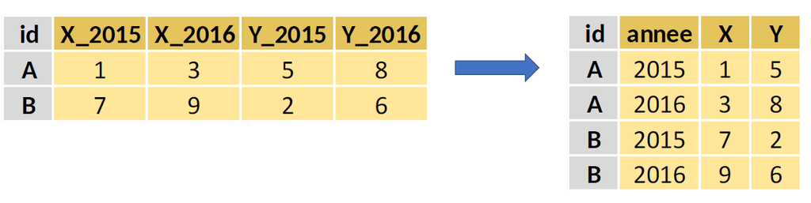

- **Transformation *long to wide*** :

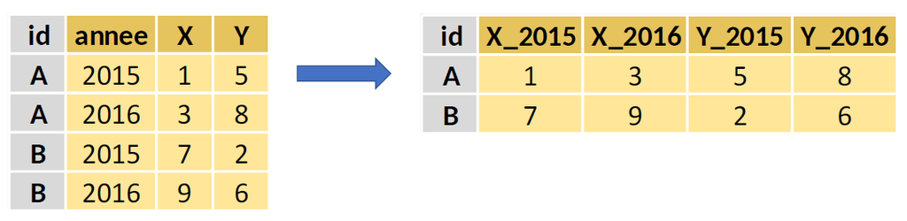

## 6.1 Transposition de colonnes en lignes (plus de lignes)

`pivot_longer` : transformer des colonnes en lignes. On fait pivoter le tableau de départ d’un format “large” (avec plus de colonnes) vers un format “long” (avec plus de lignes).

La fonction `pivot_longer` permet de restructurer des données en transformant des colonnes en lignes. Cette fonction prend quatre arguments principaux :

- le `data.frame` (ou le `tibble`) auquel elle est appliquée ;
- `cols` : noms des colonnes à pivoter,  
  un vecteur contenant le nom des colonnes dont les valeurs vont être transposées ;
- `names_to` : nom de la première colonne à créer qui prendra comme modalités les actuels noms des colonnes pivotantes ;
- `values_to` : nom de la deuxième colonne à créer qui recevra les valeurs des colonnes pivotantes.

La fonction `pivot_longer` prend comme premier argument `cols` contenant la liste des colonnes à rassembler.  
On peut spécifier les colonnes à exclure en utilisant le signe négatif `-` suivi des noms des colonnes à exclure (avec cols = - ).

`names_prefix` : préfixe à enlever des noms de colonnes à pivoter, qui seront transformées en modalités.

```r
library(dplyr)
library(tidyr) # pour pivot

# pivot_longer
# colonnes donnees en ligne
agri_bio_vegetal_fr_tab1_long <- agri_bio_vegetal_fr_tab1_car |>
  pivot_longer(cols = c("nombre_de_producteurs", "surface_bio_et_en_conversion_en_ha",
                      "surface_en_conversion_en_ha", "surface_bio_en_ha",
                      "part_bio_sau_plus_percent"),
               names_to = c("vegetal"),
               values_to = "donnees") |>
  arrange(desc(territoire))

# colonne espece en ligne
volailles_pdl_espece <- volailles_pdl_siqo2 |>
  pivot_longer(cols = starts_with("espece_"),
               names_to = c("espece","siqo"),
               names_sep = "_siqo_",
               names_prefix = "espece_",
               values_to = "tec")

volailles_pdl_espece <- volailles_pdl_espece |>
  mutate(tec = tec / 1000)

# nouvelles variables mois, type(avec nombre, poids) en enlevant suffixe mois, type par transposition
vol_2022 <- vol_2022 |>
             pivot_longer(cols = starts_with('x2022'),
                          names_prefix = "x2022_",
                          names_to = c("mois", "type"),
                          names_sep = "_",
                          values_to = "effectif")

# un seul montant en colonne
# nouvelle variable 'montant' en mettant la liste des montants par trimestre par transposition
# crée variables "trimestre"(modalités 'x1','x2','x3','x4') et
# "annee" à partir de c('x4t2018','x1t2019'...)
produits_long <- produits |>
             pivot_longer(cols = c('x4t2018','x1t2019','x2t2019','x3t2019','x4t2019',
                                   'x1t2020','x2t2020','x3t2020','x4t2020',
                                   'x1t2021','x2t2021','x3t2021','x4t2021',
                                   'x1t2022','x2t2022','x3t2022'),
                          names_to = c("trimestre","annee"),
                          names_sep = "t",
                          values_to = "montant")

# une seule espece en colonne
# nouvelle variable espece en mettant la liste des especes par transposition
itavi_2022_2021_espece <- itavi_2022_2021 |>
             pivot_longer(cols = c(poulet_standard, poulet_label_rouge, dinde,pintade,
                                   poule_pondeuse, canard_rotir, canard_gras, lapin,
                                   poulet_label_rouge_non_ogm, poule_pondeuse_label_rouge_non_ogm),
                          names_to = c("espece"),
                          values_to = "indice")

# colonnes donnees en ligne
# names_pattern = "(.*)_dep" pour enlever suffixe "_dep"
# names_pattern = paste0("(.*)_", suffixe)
agreg_anim_produit_petit_dep_1 <- agreg_anim_produit_petit_pdl |>
  select(-contains("reg")) |>
  pivot_longer(cols = contains("_dep"),
               names_to = "indicateur",
               values_to = "donnees_dep",
               names_pattern = "(.*)_dep")
```

On souhaite obtenir une nouvelle table, avec une observation par EPCI et par tranche d’âge. Voici le code qui permet d’obtenir cette table : on transpose les valeurs des colonnes dont le nom commence par “TP” (`cols = starts_with("TP")`), le nom des colonnes transposées sera indiquée dans la nouvelle colonne “tranche_age” (`names_to = "tranche_age"`) et les valeurs des colonnes transposées seront indiquées dans la colonne “taux_pauvrete” (`values_to = "taux_pauvrete"`).

```r
library(dplyr)
library(tidyr)

donnees_pauvrete_long <- filosofi_epci_2016_tbl |>
  pivot_longer(cols = starts_with("TP"),
               names_to = "tranche_age",
               values_to = "taux_pauvrete")
```

L’argument `values_drop_na` de la fonction `pivot_longer` permet de gérer les valeurs manquantes (NA).

Il détermine si les lignes contenant des NA dans la colonne des valeurs (spécifiée par values_to) doivent être conservées ou supprimées du résultat final après le pivot.

Si values_drop_na = FALSE (valeur par défaut), toutes les lignes sont conservées, y compris celles avec des NA.

Lorsqu’on utilise values_drop_na = TRUE, les lignes où la colonne spécifiée par values_to contient des NA seront exclues du tableau final. Le résultat ne contient pas des lignes avec des NA dans la colonne indiquée dans le paramètre values_to.

### 6.1.1 Utilisation de `names_pattern` dans `pivot_longer`

Lors de la transformation d’un data frame d’un format large à un format long avec `pivot_longer`, l’argument **`names_pattern`** permet de spécifier une **expression régulière** pour capturer et transformer les noms de colonnes.

- **Objectif :**
  - Extraire des parties spécifiques des noms de colonnes pour les utiliser dans les nouvelles colonnes créées.
  - Supprimer des préfixes ou suffixes communs.
- **Syntaxe :**
  - Utilise des **groupes de capture** `(.*)` pour extraire les parties souhaitées des noms de colonnes.
  - Exemple : `names_pattern = "prefixe_(.*)_suffixe"` capture la partie centrale entre `prefixe_` et `_suffixe`.
- **Avantages :**
  - **Flexibilité** : permet de gérer des noms de colonnes complexes avec des préfixes et suffixes variés.
  - **Précision** : capture uniquement les parties nécessaires, facilitant l’analyse et la visualisation des données.

```r
# Extraction des parties centrales des noms de colonnes
# Création de nouvelles colonnes avec les parties centrales extraites
# Les préfixes et suffixes sont ignorés dans le processus de transformation.
# (.*) : capture toute séquence de caractères (y compris aucun caractère)
# Le point . représente n'importe quel caractère (sauf un retour à la ligne).
# L'astérisque * signifie "zéro ou plusieurs fois".
# Les parenthèses () autour de .* créent un groupe de capture,
# ce qui signifie que cette partie de la chaîne sera extraite et utilisée
#pour remplir la nouvelle colonne indicateurs.
iaa_vol_pdl_long <- iaa_vol_total_pdl |>
  pivot_longer(
    cols = contains("indicateur"),  # Sélectionne les colonnes contenant "indicateur"
    names_to = "indicateurs",
    values_to = "volailles",
    names_pattern = "pre_(.*)_suf"  # Capture la partie centrale entre "pre_" et "_suf"
  ) |>
  select(indicateurs, volailles)
```

```r
# tous les noms de colonnes contenant '_vol' doivent aller dans la colonne 'vol'
# et tous les noms de colonnes contenant '_reg' doivent aller dans la colonne 'reg'.
# `names_pattern = "(.*)_(.*)"` spécifie comment diviser les noms des colonnes.
# Le groupe (.*) correspond au nom de la colonne avant le suffixe (“_vol” ou “_reg”).
# Le paramètre names_pattern permet de spécifier un suffixe commun à enlever des noms des modalités.
# Il extrait la partie du nom de colonne avant "_vol" et la stocke dans la colonne "indicateurs".
iaa_vol_pdl_long <- iaa_vol_total_pdl |>
  pivot_longer(cols = ends_with("_vol"),
               names_to = "indicateurs",
               values_to = "volailles",
               names_pattern = "(.*)_vol$") |>
  select(indicateurs, volailles)

iaa_total_pdl_long <- iaa_vol_total_pdl |>
  pivot_longer(cols = ends_with("_reg"),
               names_to = "indicateurs",
               values_to = "ensemble",
               names_pattern = "(.*)_reg$") |>
  select(indicateurs, ensemble)

iaa_vol_total_pdl_long <- iaa_vol_pdl_long |>
  full_join(iaa_total_pdl_long,
            join_by(indicateurs),
            relationship = "one-to-one") |>
  arrange(indicateurs)

# autre solution
# names_pattern = "(.*)_(vol$|reg$)" : pour séparer le nom de la colonne initiale en deux parties :
# la partie avant le dernier underscore (tout ce qui précède _(vol$|reg$) sera stockée dans "indicateurs",
# et la partie après le dernier underscore sera stockée dans "type",
# soit "vol" soit "reg" à la fin du nom de la colonne.
iaa_vol_total_pdl_long2 <- iaa_vol_total_pdl |>
  pivot_longer(cols = -c(regsiege, libreg),
               names_to = c("indicateurs", "type"),
               values_to = "valeurs",
               names_pattern = "(.*)_(vol$|reg$)") |>
  pivot_wider(names_from = type,
              values_from = valeurs) |>
  arrange(indicateurs)
```

## 6.2 Transposition de lignes en colonnes (plus de colonnes)

`pivot_wider` : transformer des lignes en colonnes. On fait pivoter le tableau de départ d’un format “long” (avec plus de lignes) vers un format “large” (avec plus de colonnes).

La fonction `pivot_wider` permet de restructurer des données en transformant des lignes en colonnes. Cette fonction prend quatre arguments principaux :

- le `data.frame` (ou le `tibble`) auquel elle est appliquée ;
- `id_cols` : un vecteur contenant le nom des colonnes qui définissent les observations de la table transposée ;
- `names_from` : nom de la variable dont les modalités deviendront les intitulés des futures colonnes,  
  un vecteur contenant le nom de la (ou des) colonne(s) qui donne(nt) les noms des nouvelles colonnes à créer  
  Les valeurs uniques de cette colonne deviendront les noms de colonnes dans le dataframe résultant ;
- `values_from` : nom de la variable à utiliser pour remplir les colonnes,  
  un vecteur contenant le nom de la (ou des) colonne(s) dont les valeurs vont être transposées.

L’option `names_prefix` permet de définir le préfixe du nom des nouvelles colonnes, ce qui est utile pour avoir des noms explicites.

L’option `values_fill` permet de spécifier comment remplir les cases vides (par exemple, si certaines combinaisons de valeurs ne sont pas présentes dans les données d’origine). Par défaut, les cases vides sont remplies avec des NA.

```r
library(dplyr)
library(tidyr) # pour pivot
library(janitor) # pour round_half_up

bpe_ens_2018_tbl |>
    group_by(REG, TYPEQU) |>
    summarise(NB_EQUIP_TOT = sum(NB_EQUIP)) |>
  ungroup() |>
    pivot_wider(id_cols = TYPEQU,
                names_from = REG,
                values_from = NB_EQUIP_TOT,
                names_prefix = "nb_equip_reg")

# pivot_wider
volailles_sum <- bind_rows(volailles_dep_sum, volailles_pdl_sum) |>
  pivot_wider(names_from = dep,
              values_from = tec_regrpt)

# transposition lignes vers colonnes
produits_a17_large <- produits_a17 |>
   pivot_wider(names_from = c(annee,flux,semestre),
               values_from = valeur,
               names_prefix = "an_"
              ) |>
   mutate(an_2021_imports = an_2021_I_sem1 + an_2021_I_sem2,
          an_2022_imports = an_2022_I_sem1 + an_2022_I_sem2,
          an_2021_exports = an_2021_E_sem1 + an_2021_E_sem2,
          an_2022_exports = an_2022_E_sem1 + an_2022_E_sem2,
          .after=a17_lib_detail)

# territoire en colonne
agri_bio_vegetal_fr_tab1_final <- agri_bio_vegetal_fr_tab1_long |>
  pivot_wider( names_from = "territoire",
               names_prefix = "",
               values_from = "donnees")

# Transposer le tableau en format plus large, à partir de la variable type
lait_production_vache_large <- lait_production_vache_2 |>
 pivot_wider(names_from = type,
             values_from = c(livraison_reg,livraison_dep,livraison_dep_perc))

# Le format large est approprié pour calculer des évolutions
# Calculer l'évolution de la production de lait et de la collecte de lait
# entre 2020 et 2021, en hl et en %
laits_mensuel_chevre_livr_coll_large_2 <- laits_mensuel_chevre_livr_coll_large_1 |>
  mutate(livr2021_evol = livraison_2021 - livraison_2020,
         livr2021_evol_perc = (livraison_2021 / livraison_2020 - 1) * 100,
         coll2021_evol = collecte_2021 - collecte_2020,
         coll2021_evol_perc = (collecte_2021 / collecte_2020 - 1) * 100) |>
  mutate(across(c(livr2021_evol_perc,coll2021_evol_perc), \(x) round_half_up(x, digits = 3))) |>
  mutate(across(c(livraison_2020, livraison_2021,
                  collecte_2020, collecte_2021, livr2021_evol, coll2021_evol),
                \(x) round_half_up(x, digits = 3)))

# colonne an_mois en colonne
oeufs_2022_2021_an_mois <- oeufs_2022_2021 |>
             pivot_wider(names_from = c(Année,mois),
                         names_prefix = "an_",
                         values_from = c(Exportation_Nombre, Importation_Nombre, solde))

eff_volailles_evol_part <- eff_volailles_evol |>
  select(-c(evo_percent, region, an_2020)) |>
  pivot_wider(names_from = reg,
              names_prefix = '',
              names_sep = "_",
              values_from = c(an_2021, evol_2021_2020)) |>
  mutate(part_pdl_france_2021 = paste0(round_half_up(an_2021_pdl / an_2021_fm * 100, 0), " %")) |>
  relocate(an_2021_pdl, evol_2021_2020_pdl, an_2021_fm,evol_2021_2020_fm,
           part_pdl_france_2021, .after = espece)

laits_mensuel_chevre_livr_coll_large <- laits_mensuel_chevre_livr_coll |>
  pivot_wider(names_from = annee,
              names_sep = "_",
              values_from = c(livraison,collecte)) |>
  adorn_totals(where = "row",
               name = "Total")

# passage au format large pour dep
exploit_otex_dep <- exploit_pdl |>
  arrange(desc(dep), otex_regroup) |>
  pivot_wider(id_cols = otex_regroup,
              names_from = dep,
              values_from = c03_n_exploit_dep,
              names_prefix = "dep_")

# on transpose cult_pdl_2020 pour avoir une seule ligne par exploitation (nom_dossier)
# les valeurs manquantes sont remplacées par la valeur 0
nom_dossier_cult_pdl <- cult_pdl_2020 |>
  pivot_wider(id_cols = nom_dossier,
              names_from = cult_ra_code,
              values_from = c(cultsur, irrisur),
              names_prefix = "",
              values_fill = 0)
```

```r
# enchainement de pivots
# en général pivot_longer avant pivot_wider : cela augmente le nombre de lignes
# et diminue le nombre de colonnes, ce qui est généralement plus facile à gérer
# pour ensuite pivoter les données en utilisant pivot_wider.
# Pivoter de manière à avoir les indicateurs surf_2023 et prod_2023 en lignes,
# et les valeurs de dep en colonnes
surf_fruits_tonnes_large <- surf_fruits_tonnes |>
  # on va d’abord transformer les colonnes surf_2023 et prod_2023
  # en une colonne indicateur
  # avec les valeurs correspondantes dans une colonne valeur.
  pivot_longer(cols = c(surf_2023, prod_2023),
               names_to = "indicateur",
               values_to = "valeur") |>
  # Ensuite, on va pivoter ces données
  # pour que les valeurs de dep deviennent des colonnes
  pivot_wider(names_from = dep, values_from = valeur)

# autre enchainement de pivots
otex_regroupe <- otex_transp  |>
  select(-ends_with('temp'), otex_4813, otex_4840, otex_5100, otex_5374) |>
  pivot_longer(cols = -c(annee),
               names_to = c("otex_code_regr"),
               values_to = "etp") |>
  pivot_wider(names_from = annee,
              values_from = c(etp))

# enchainement de pivots
# ici pivot_wider avant pivot_longer
# on remet temporairement import export en colonne pour calculer le solde
# Étape 1 : Pivoter pour avoir Export et Import en colonnes
# on transforme les colonnes flux (qui contiennent Export et Import) en colonnes distinctes,
# avec les valeurs correspondantes dans montant.
produits_large <- produits_long_AZ_C1 |>
   pivot_wider(names_from = flux,
               values_from = montant) |>
   mutate(solde = Export - Import)  # Étape 2 : Calculer le solde

# Étape 3 : Revenir au format long
# on reconvertit les colonnes Export, Import et solde en une colonne flux
# avec les valeurs correspondantes dans montant.
produits_long_AZ_C1 <- produits_large |>
   pivot_longer(cols = c('Export', 'Import', 'solde'),
                names_to = 'flux',
                values_to = "montant")
```

```r
# Transposition des données : années en lignes, variables en colonne indicateur
# les années deviennent des lignes
# et les autres variables sont rassemblées dans une colonne indicateur
bio_vege2_pdl_reg_ensemble_long <- bio_vege2_pdl_reg_ensemble |>
  select(-ident_vege1) |>
  pivot_longer(
    cols = -c(
      annee, echelle_geographique, territoire,
      type_de_production, groupe_de_productions, sous_groupe_de_productions
    ),
    names_to = "indicateur",
    values_to = "valeur"
  ) |>
  pivot_wider(
    names_from = annee,
    values_from = valeur
  )

# transposer les données de manière à ce que les années soient en ligne (deviennent des colonnes)
# et les variables deviennent des lignes de la colonne indicateur
bio_vege2_pdl_an_reg_ensemble_long <- bio_vege2_pdl_an_reg_ensemble |>
  select(-c(
    echelle_geographique, type_de_production,
    groupe_de_productions, sous_groupe_de_productions)) |>
  pivot_longer(
    cols = contains("an_"),
    names_to = c("indicateur", "annee"),
    names_sep = "_an_",
    values_to = "valeur") |>
  # Pivoter à nouveau pour avoir les années en colonnes
  pivot_wider(
    names_from = annee,
    values_from = valeur)
```

Il peut arriver que certaines variables soient absentes pour certaines observations.  
Dans ce cas l’argument `values_fill` permet de spécifier la valeur à utiliser pour ces données manquantes (par défaut les valeurs absentes sont indiquées par des `NA`).

`values_fill` gère les valeurs manquantes lors du pivotement. Il permet de spécifier une valeur de remplacement pour les cellules n’ayant pas de valeur lorsqu’on effectue la transformation. On peut spécifier une valeur unique pour toutes les colonnes, ou une liste de valeurs pour chaque colonne.

Par défaut, les cellules sans correspondance reçoivent une valeur NA dans le tableau résultant. On peut ainsi utiliser `values_fill` pour attribuer une valeur différente, comme 0, une chaîne vide (““), ou toute autre valeur (par exemple”Aucun”).

```r
df |>
  pivot_wider(
    names_from = variable,
    values_from = value,
    values_fill = list(value = 0) # Valeur de remplacement pour les valeurs manquantes
  )
```

# 7 Jointure de tableaux

On cherche à associer deux tables en se basant sur les valeurs d’une ou plusieurs colonnes. Ces colonnes sont appelées des *clés de jointure* (codes d’identification).

Les noms de variables peuvent être cités sans guillemets (sauf dans le cas des jointures). - les fonctions `*_join(a, b, join_by)` du package `dplyr` permettent de joindre les tables `a` et `b` sur les variables de jointure précisées dans l’argument `join_by`. Les variables non jointives portant le même nom sont suffixées par `.x` et par `.y` (par défaut).

## 7.1 Jointure à gauche avec left_join

Dans une jointure à gauche, on adjoint aux informations de la table de gauche les informations issues de la table de droite.

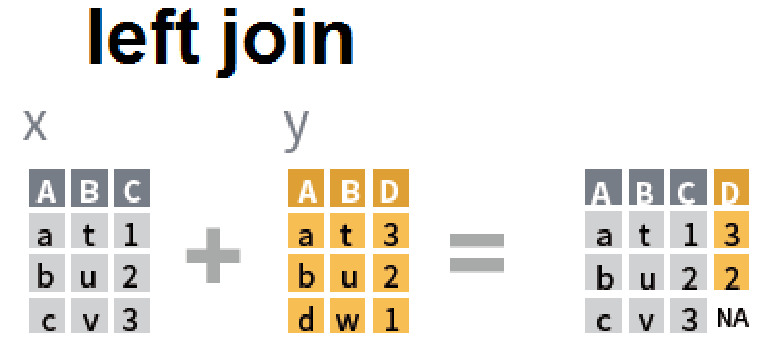

Ainsi, c’est le tableau de gauche qui définit les individus du tableau en sortie (quand bien-même il n’y a pas d’information à leur sujet dans le tableau de droite : on remarque ainsi la donnée manquante dans la colonne D pour le 3e individu). La fonction s’appuie sur les variables communes aux deux tableaux (ici A et B), qui permettent d’identifier les individus et de relier les informations des deux tables. On précise explicitement quelles sont les identifiants qui permettent de faire ce lien entre les deux tables, à travers l’argument `join_by` :

```r
left_join(x, y, join_by(A, B))
```

Quand on fait un `left_join(x, y)`, toutes les lignes de `x` sont présentes, et dupliquées si nécessaire quand elles apparaissent plusieurs fois dans `y`. Les lignes de `y` non présentes dans `x` disparaissent. Les lignes de `x` non présentes dans `y` se voient attribuer des valeurs manquantes `NA` (non available) pour les nouvelles colonnes.

Cela correspond à ramener l’information de la table `y` sur la table `x`.

```r
# jointure des tableaux exploit et prod_anim, avec nom_dossier
exploit_anim <- exploit |>
  left_join(prod_anim,
            join_by(nom_dossier))

# ajout au fichier historique des années 2020 et 2021
lait_chevre_historiq <- lait_chevre3  |>
  left_join(laits_mensuel_chevre_livr_coll_large,
            join_by(code_mois))

oeufs_annee <- oeufs_2021  |>
  left_join(oeufs_2020,
            join_by(reg, libelle_culture))

laits_mensuel_chevre_livr_coll <- laits_mensuel_chevre_livraison |>
  left_join(laits_mensuel_chevre_collecte,
            join_by(annee, code_mois)) |>
  select(-c(reg_etab, reg_prod))

# ajout au fichier historique des années 2020 et 2021
produits_laitiers_historiq <- produits_laitiers  |>
  left_join(groupe_produits_laitiers_2021 |>
              select(-libellé_produit),
            join_by(territoire, code_produit))

# regroupement dep reg  avec left_join
agreg_anim_produit_petit_dep_reg <- agreg_anim_produit_petit_dep_2 |>
  left_join(agreg_anim_produit_petit_reg,
            join_by(indicateur)) |>
  mutate(across(where(is.numeric), \(x) round_half_up(x, digits = 0)))

# on enleve avec collectiffil les pacages communs (Brière par exemple)
exploit_2010 <- exploit_2010_fm |>
  left_join(ra_2010_geo_2020 |>
              select(id_dossier,
                     siege_dep_2020,
                     siege_reg_2020),
                join_by(id_dossier))  |>
  filter(siege_reg_2020 == "52" & collectiffil == "0")

# enchainement de left_join
exploitants_2010 <- fam_2010 |>
  filter(famlien %in% c("10", "11", "12", "13"))  |>
  mutate(nom_dossier = id_dossier,
         annee = annee_ra_2010,
         age = annee_ra_2010 - as.integer(famanais),
         tr_age_10 = cut(age, c(0, seq(40, 60, by = 10), Inf), right = FALSE)) |>
  left_join(exploit_2010 |>
              mutate(sau_tot = sau / 100) |>
              select(nom_dossier = id_dossier,
                     sau_tot),
             join_by(nom_dossier)) |>
  left_join(pbs_2010 |>
              select(nom_dossier = id_dossier,
                     dimeco_coef2017,
                     pbstot_coef17),
            join_by(nom_dossier))

# on ajoute le libelle des nomenclatures a129, cpf4 et a17
produits <- produits |>
   left_join(y = a129,
             join_by(a_129)) |>
   left_join(y = cpf4,
             join_by(cpf4)) |>
   left_join(y = table_NAF,
             join_by(a_129)) |>
   left_join(y = secteur_a17,
             join_by(a_17))
```

**Avec `dplyr`, les jointures se réalisent grâce aux fonctions `left_join`, `right_join`, `inner_join`, `full_join` et `anti_join`.** Ces fonctions prennent les arguments suivants :

- le nom des deux `data.frame` à joindre ;
- les variables de jointure, défini par l’argument `join_by`. Lorsque la variable de jointure ne porte pas le même nom dans les deux tables, on utilise la syntaxe `join_by(var_x == var_y)` pour faire correspondre des colonnes avec des noms différents.  
  S’il y a plusieurs variables de jointures, on utilise `join_by(var_x1 == var_y1, var_x2 == var_y2)`.

Il est préférable d’utiliser ces fonctions sur des objets `tibble` plutôt que `data.frame`. On va donc convertir les deux tables avant de présenter un exemple :

```r
library(dplyr)
filosofi_com_2016_tbl <- as_tibble(doremifasolData::filosofi_com_2016)
cog_com_2019_tbl <- as_tibble(doremifasolData::cog_com_2019)
```

Voici un exemple dans lequel on utilise la fonction `left_join` pour réaliser une jointure à gauche entre la table des données Filosofi et la table des communes du COG.

```r
table_jointe_tbl <- filosofi_com_2016_tbl |>
left_join(y = cog_com_2019_tbl,
join_by(CODGEO == com))

head(table_jointe_tbl)
```

```r
# Utiliser left_join pour combiner les résultats
bio_vege2_dep_pdl_an_rang <- bio_vege2_dep_pdl_an_rang_ss_groupe_prod |>
  left_join(
    bio_vege2_dep_pdl_an_rang_groupe_prod |>
      select(
        echelle_geographique,
        territoire,
        type_de_production,
        groupe_de_productions,
        sous_groupe_de_productions,
        starts_with("rang_groupe_prod")
      ),
    join_by(
      echelle_geographique,
      territoire,
      type_de_production,
      groupe_de_productions,
      sous_groupe_de_productions
    )
  ) |>
  arrange(
    ident_vege2
    # echelle_geographique,
    # territoire
  )
```

Parfois, il peut être utile de réaliser une jointure de la table avec elle-même pour affecter la valeur d’une variable à une autre variable. Dans l’exemple suivant, on affecte le nom du premier département à l’ensemble des lignes.

```r
# ajout du rang 1 (département) à l'ensemble des lignes
# on réalise une jointure de la table avec elle-même pour affecter la valeur d’une variable # à une autre variable.
# Dans l’exemple suivant, on affecte la valeur (le 1er dep) de valeur_dep_rang1
# relative à valeur_dep_rang == 1.
# on prend valeur_dep_rang1 correspondant au dep du rang1 (pour valeur_dep_rang == 1)
# et on affecte la valeur
# pour l'ensemble des cas
# jointure de l'ensemble des lignes avec la ligne contenant valeur_dep_rang1 (le 1er dep)
# ligne par ligne
recolte_bois_dep_reg <-  recolte_bois_dep_reg |>
  mutate(commun = 1)

# en 2 étapes
recolte_bois_dep_reg_rang1_etape1 <-  recolte_bois_dep_reg |>
  select(categorie,commun,
         valeur_dep_rang_y = valeur_dep_rang,
         valeur_dep_rang1 = valeur_dep_rang1_a) |>
  filter(valeur_dep_rang_y == 1)

recolte_bois_dep_reg_2_etape2 <-  recolte_bois_dep_reg |>
  left_join(recolte_bois_dep_reg_rang1_etape1,
            join_by(categorie, commun)) |>
  select(-c(valeur_dep_rang1_a, valeur_dep_rang_y))

# en une étape
recolte_bois_dep_reg_2 <-  recolte_bois_dep_reg |>
  left_join(recolte_bois_dep_reg |>
                select(categorie,commun,
                       valeur_dep_rang_y = valeur_dep_rang,
                       valeur_dep_rang1 = valeur_dep_rang1_a) |>
                filter(valeur_dep_rang_y == 1),
            join_by(categorie, commun)) |>
  select(-c(valeur_dep_rang1_a, valeur_dep_rang_y))
```

Utilisation de la numérotation de lignes comme identifiant commun pour la concaténation d’une table avec une sous-table.

```r
# jointure des tableaux bio_pdl et bio_pdl_pommes,
# avec l'identifiant “numéro de ligne”

# Ajout d’une colonne “numéro de ligne”
# creation d'une variable identifiant reprenant le numéro de ligne
bio_pdl_numero_ligne <- bio_pdl |>
  mutate(ident = row.names(bio_pdl), .before = 1)

# Filtrer les enregistrements concernant les pommes
bio_pdl_pommes_2 <- bio_pdl_numero_ligne |>
  mutate(libelle_ab_2 = if_else(startsWith(libelleonab, "Pomme"), "Pommes", libelleonab)) |>
  filter(libelle_ab_2 %in% c("Pommes") & libelleonab != "Pommes de terre (hors féculière)")

# jointure des tableaux bio_pdl_numero_ligne et bio_pdl_pommes_2,
bio_pdl_nomenclature_numero_ligne <- bio_pdl_numero_ligne |>
  left_join(bio_pdl_pommes_2 |>
              select(ident, libelle_ab_2),
              join_by(ident))

recolte_bois_pdl_indic <- recolte_bois_pdl_indic |>
  mutate(identifiant = row.names(recolte_bois_pdl_indic), .before = 1) |>
  mutate(identifiant = as.numeric(identifiant) + 10)

recolte_bois_pdl_indic <- recolte_bois_pdl_indic |>
  mutate(identifiant = case_when(
    indicateur == "Récolte de bois" ~ 62,
    .default = identifiant),
    .before = 1)
```

## 7.2 Jointure complète avec full_join

Dans le cas d’une jointure complète, au contraire d’une jointure interne, on conserve l’ensemble des individus décrits par l’un ou l’autre des jeux de données. Dans le cas de `full_join(x, y)`, toutes les lignes de `x` et toutes les lignes de `y` sont conservées (avec des `NA` ajoutés si nécessaire) même si elles sont absentes de l’autre table.

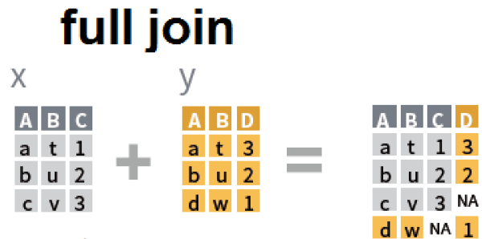

```r
full_join(x, y, join_by(A, B))
```

Identifiants portant des noms différents

Il arrive qu’une variable identifiant les individus n’ait pas le même nom dans les deux tableaux. Dans ce cas on peut préciser de faire correspondre à une variable du premier tableau, une autre variable du deuxième tableau, de la manière suivante:

```r
# Fait correspondre x$C et y$D:
full_join(x, y, join_by(C == D))
```

```r
# jointure des tableaux, avec pacage
surface_bio_2022_2023 <- bio_2023 |>
  full_join(bio_2022,
    join_by(pacage))

# creation indicatrice
# present_2023_present_2022
# present_2023_absent_2022
# absent_2023_present_2022
# creation variable surface supplémentaire en 2023
surface_bio_2022_2023 <- surface_bio_2022_2023 |>
  mutate(present_2023_present_2022 = if_else(!is.na(quantite_declaree_2023) & !is.na(quantite_declaree_2022),
                                            true = 1, false = 0),
         present_2023_absent_2022 = if_else(!is.na(quantite_declaree_2023) & is.na(quantite_declaree_2022),
                                            true = 1, false = 0),
         absent_2023_present_2022 = if_else(is.na(quantite_declaree_2023) & !is.na(quantite_declaree_2022),
                                            true = 1, false = 0),
         indicateur_presence = case_when(
           !is.na(quantite_declaree_2023) & !is.na(quantite_declaree_2022) ~ "present_2023_present_2022",
           !is.na(quantite_declaree_2023) & is.na(quantite_declaree_2022) ~ "present_2023_absent_2022",
           is.na(quantite_declaree_2023) & !is.na(quantite_declaree_2022) ~ "absent_2023_present_2022",
         .default = "autre"),
         surface_supplementaire_2023 = quantite_declaree_2023 - quantite_declaree_2022)

unique(surface_bio_2022_2023$indicateur_presence)
```

```r
# jointure des tables des différents millésimes et de la table de passage
# plusieurs lignes par commune en geo 2022
# filtre pour récupérer uniquement les communes des Pays de la Loire
pop <- pop_1990 |>
  full_join(pop_1999, join_by(com)) |>
  full_join(pop_2010, join_by(com)) |>
  full_join(pop_2019, join_by(com)) |>
  full_join(comdepuis1943_com2022, join_by(com == depcom_initial)) |>
  filter(dep_2022 %in% c("44","49","53","72","85")) |>
  select(depcom_2022, libcom_2022, psdc90, psdc99, pmun10, pmun19)
```

## 7.3 Quelques bonnes pratiques sur les jointures

Pour plus de précisions, consulter la fiche https://book.utilitr.org/03_Fiches_thematiques/Fiche_joindre_donnees.html#quelques-bonnes-pratiques-sur-les-jointures qui présente un certain nombre de règles et de bonnes pratiques sur les jointures.

### 7.3.1 Avant la jointure

Avant de procéder à une jointure, il est essentiel de **vérifier la qualité des identifiants dans les deux tables** que l’on souhaite joindre.

- **Règle n°1 : vérifier la présence de valeurs manquantes dans les variables de jointure**.

  Une première approche consiste à rechercher les valeurs manquantes (`NA`) dans les variables de jointure. Le code suivant permet de calculer le nombre d’observations pour lesquelles l’identifiant est manquant :

  ```r
  sum(is.na(filosofi_com_2016$CODGEO))

  sum(is.na(cog_com_2019$com))
  ```

  Il convient de vérifier que les variables de jointure ne contiennent aucun `NA` dans les deux tables. Toutefois, les valeurs manquantes peuvent prendre des formes plus complexes que `NA` : `0`, `.`, `999`… c’est pourquoi il est important de procéder à une inspection visuelle des variables de jointure. Pour ce faire, on peut utiliser la fonction `unique()`, qui permet d’afficher la liste des valeurs qui apparaissent dans une variable.

  ```r
  unique(filosofi_com_2016$CODGEO)
  ```

- **Règle n°2 : vérifier la présence de doublons dans les variables de jointure**.

  Si les variables de jointure contiennent un grand nombre de fois les mêmes valeurs, la jointure peut devenir très gourmande en ressources, voire irréalisable. Il est donc indispensable de repérer les doublons, et de les traiter si nécessaire.

  La fonction `eeptools::isid` permet de déterminer si une ou plusieurs colonnes données constitue(nt) un identifiant unique.  
  On recherche la combinaison de variables la plus simple qui permette d’identifier de manière unique chaque ligne d’une table. Par exemple :
- Un numéro SIREN pour une entreprise
- La combinaison (année, mois, département) pour des données mensuelles par département

```r
# Exemple de vérification d'identifiant unique
eeptools::isid(df, c("annee", "mois", "departement"))

# Recherche de doublons sur cet identifiant
df |>
  janitor::get_dupes(annee, mois, departement)
```

Le code suivant calcule le nombre d’observations dans la table pour chaque valeur des variables de jointure, et affiche les premières lignes par nombre d’observations décroissant. Si la variable `nb_obs` est supérieure ou égale à 2, alors il y a des doublons.

```r
doublons <- filosofi_com_2016_tbl |>
              group_by(CODGEO) |>
              summarise(nb_obs = n(), .groups = "drop") |>
              filter(nb_obs > 1) |>
              arrange(-nb_obs)

doublons

# Pour voir toutes les lignes concernées par les doublons :
filosofi_com_2016_tbl |>
 semi_join(doublons, join_by(CODGEO))


# On vérife l’unité d’observation des deux dataframes avant la jointure.
# La fonction eeptools::isid permet de vérifier si un ensemble de variables
# forme un identifiant unique pour les différentes observations dans un dataframe.
# Elle renvoie un booléen (TRUE/FALSE) indiquant si les variables identifient
# de manière unique une ligne dans le dataframe.

eeptools::isid(laits_mensuel_chevre_livraison,
var = c("annee","mois"),
verbose = TRUE)

eeptools::isid(laits_mensuel_chevre_collecte,
var = c("annee","mois"))
```

Une présence de doublons rend nécessaire une analyse de la table avant de réaliser la jointure.

Le fait que les variables de jointure contiennent des valeurs manquantes ou des doublons n’est pas nécessairement un problème. C’est à vous de déterminer si cela pose un problème. Voici deux questions à se poser pour analyser la situation :

- La (ou les) variable(s) de jointure doi(ven)t-elle(s) impérativement être renseignée(s) pour chaque observation ? Si oui, il ne doit pas y avoir de valeurs manquantes.
- La (ou les) variable(s) de jointure doi(ven)t-elle(s) identifier de façon unique chaque observation ? Si oui, il ne doit pas y avoir de doublons.

`Vérification de doublons de lignes`

Cette vérification peut permettre de déterminer les variables servant d’identifiant commun à 2 tables. On peut aussi utiliser la numérotation de lignes comme identifiant commun pour la concaténation d’une table avec une sous-table.

```r
# afficher les lignes en doublon pour l'ensemble des variables
bio_pdl_test_doublons <- bio_pdl |>
  group_by(across(everything())) |>
  filter(n() > 1) |> # Compter occurrences
  summarise(
    nb_doublons = n() - 1,  # Soustrait 1 car première occurrence n'est pas un doublon
    .groups = "drop")

# afficher les lignes en doublon pour l'ensemble des variables servant d'identifiant
bio_pdl_test_doublons_var_ok <- bio_pdl |>
  # group_by par colonnes d'identification
  group_by(raisonsociale, numeropacage, numerobio,
           libelleonab, ss_groupe_onab_libelle, nomoc) |>
  filter(n() > 1) |>
  arrange(raisonsociale, numeropacage, numerobio,
          libelleonab, ss_groupe_onab_libelle, nomoc) |>
  ungroup()

# afficher les lignes en doublon pour l'ensemble des variables servant d'identifiant sans nomoc
# il reste 11 lignes en double, soit 22 observations
bio_pdl_test_doublons_var_doubl <- bio_pdl |>
  group_by(raisonsociale, numeropacage, numerobio,
           libelleonab, ss_groupe_onab_libelle) |>
  filter(n() > 1) |>
  arrange(raisonsociale, numeropacage, numerobio,
          libelleonab, ss_groupe_onab_libelle)|>
  ungroup()
```

Extraire les doublons avec la fonction `get_dupes()` du package `janitor`.  
Cette fonction permet de comparer les lignes d’un dataframe et de renvoyer les doublons de lignes entièrement identiques.  
Elle peut être utilisée pour comparer toutes les colonnes ou seulement certaines colonnes.  
On peut également conserver toutes les colonnes dans le résultat.  
`get_dupes()` ajoute automatiquement une colonne `dupe_count` comptant les occurrences.

```r
library(janitor)

# 1. Doublons sur lignes entières
# renvoie les doublons de lignes entièrement identiques (les premières occurrences et leurs doublons)
df |>
  get_dupes() |> # Compare toutes les colonnes
  arrange(desc(dupe_count)) |>  # Trie par nombre de doublons

# 2. Doublons sur colonnes spécifiques
# renvoie les doublons de lignes partageant les mêmes valeurs sur les variables var1 et var2
df |>
  get_dupes(var1, var2)  # Compare uniquement ces 2 colonnes

# 3. Doublons avec conservation des autres colonnes
# renvoie les doublons de lignes partageant les mêmes valeurs sur les variables var1 et var2
# et conserve toutes les colonnes
df |>
  get_dupes(
    var1, var2,
    .keep_all = TRUE  # Garde toutes les colonnes dans résultat
  )
```

```r
# Fonction pour analyser les doublons
recherche_doublons <- function(df, vars) {

  # 1. Vérifier identifiant unique
  is_unique <- eeptools::isid(df, vars)

  # 2. Compter doublons
  doublons <- df |>
    group_by(across(all_of(vars))) |>
    summarise(
      nb_obs = n(),
      .groups = "drop") |>
    filter(nb_obs > 1) |>
    arrange(desc(nb_obs))

  # 3. Résumé
  resume <- list(
    id_unique = is_unique,
     nb_total_doublons = sum(doublons$nb_obs) - nrow(doublons),
    details_doublons = doublons
  )

  # return facultatif. Certains considèrent que l'ajouter permet de rendre le code plus lisible.
  return(resume)
}

# Utilisation
resultats <- recherche_doublons(
  df = table,
  vars = c("annee", "mois")
)

print(glue("Identifiant unique: {resultats$id_unique}"))
print(glue("Nombre total de doublons: {resultats$nb_total_doublons}"))
```

La formule nb_total_doublons soustrait le nombre de groupes (nrow(doublons)) du total d’observations (sum(nb_obs)) pour obtenir le nombre réel de doublons.

```r
# Vérifier les doublons dans la colonne 'pays'
doublons_pays <- pays_avec_doublons |>
  group_by(x1) |>
  filter(n() > 1) |>
  ungroup()

# Afficher les lignes doublons
print("Lignes doublons basées sur la colonne 'pays':")
print(doublons_pays)

# Une date de 999912 indique que l'association a cours au moment de la mise en ligne de cette annexe.
#
# print(doublons_pays)
# # A tibble: 6 × 4
#   x1    x2                                     x3     x4
#   <chr> <chr>                               <dbl>  <dbl>
# 1 QU    Pays NDA                           190001 199912
# 2 QU    Pays et territoires non déterminés 201201 999912
# 3 XK    Yougoslavie                        199206 199212
# 4 XK    Kosovo                             200506 999912
# 5 XS    Saba                               190001 200505
# 6 XS    Serbie                             200506 999912

# enlever doublons
pays_actifs <- pays_avec_doublons |>
  filter(x4 == 999912)
```

- **Règle n°3 : vérifier la compatibilité des variables de jointure**.
  - **Une jointure ne peut être réalisée avec `R` que si les variables de jointure sont de même type.** Il faut donc vérifier que c’est le cas. Les types de variables les plus fréquemment utilisées pour des jointures avec `R` sont `integer` (nombre entier), `character` (chaîne de caractères) et `factor` (catégorie). On peut utiliser la fonction `class` pour connaître le type d’une variable.

  ```r
  # Type de la variable de jointure dans la table Filosofi
  class(filosofi_com_2016$CODGEO)

  # Type de la variable de jointure dans le COG 2019
  class(cog_com_2019$com)
  ```

  Si les variables sont de type différent, alors il faut convertir les variables de jointure dans l’une des tables. Pour ce faire, on peut utiliser les fonctions `as.integer`, `as.character` et `as.factor`.

  Pour afficher le nombre d’identifiants distincts dans une table.

  ```r
  # Nombre d'identifiants distincts dans la table Filosofi
  length(unique(filosofi_com_2016$CODGEO))
  ```